# MEKONG TECHNOLOGY

## 4.2. Tòa nhà Văn phòng 3 Tầng (21m x 48m)

| Tầng | Chiều cao | Diện tích | Chức năng chi tiết |
| --- | --- | --- | --- |
| **Tầng 1** | 5,0 m | 1.008 m² | Sảnh chính (200 m²) + Showroom sản phẩm (150 m²) + Phòng họp lớn (100 m²) + 2 Phòng họp nhỏ (2x40 m²) + Phòng tiếp khách (80 m²) + WC + Thang máy + Cầu thang + Hành lang (338 m²) |
| **Tầng 2** | 4,5 m | 1.008 m² | R&D Lab IoT (250 m²) + R&D Lab Robot (200 m²) + Phòng thiết kế CAD/CAM (150 m²) + Văn phòng Kỹ thuật (200 m²) + Phòng server nhỏ (40 m²) + WC + Hành lang (168 m²) |
| **Tầng 3** | 4,5 m | 1.008 m² | VP Tổng Giám đốc (80 m²) + VP Ban Giám đốc (120 m²) + VP Hành chính-Kế toán (150 m²) + Phòng đào tạo (120 m²) + Canteen (200 m²) + Phòng kỹ thuật M&E (80 m²) + WC + Hành lang (178 m²) |
| **Tổng** | **14,0 m** | **3.024 m²** | Bao gồm thang máy + cầu thang bộ |

> **Kết cấu:** Khung BTCT, sàn BTCT dự ứng lực, tường gạch + kính Low-E, mái BTCT + chống thấm + Solar PV 200 kWp. Thiết kế kiến trúc hiện đại, phù hợp quy hoạch KCNC. Áp dụng tiêu chuẩn công trình xanh **EDGE** (IFC) — tiết kiệm năng lượng >= 20%, tiết kiệm nước >= 20%, giảm carbon vật liệu >= 20%.

### 4.2.2. Chi tiết R&D Lab — Tầng 2 (1.008 m2)

R&D Lab là khu vực chiến lược phục vụ phát triển sản phẩm IoT/BMS/Robot, đặt tại Tầng 2 cùng khu kỹ thuật thiết kế:

| TT | Khu vực | Diện tích (m2) | Trang thiết bị chính | Nhiệt độ / Điều kiện |
| --- | --- | --- | --- | --- |
| 1 | R&D Lab IoT/BMS | 250 | 12 trạm làm việc với oscilloscope, logic analyzer, nguồn DC, scope, IoT Dev Kit; khu hàn SMD thủ công; kệ linh kiện ESD-safe | 22-24 C, RH 45-55%, ESD floor |
| 2 | R&D Lab Robot | 200 | Khu lắp ráp prototype robot (2 bàn), khu test servo/motor, LiDAR test bench, khu nạp/test pin LiFePO4, khu software debug | 24-26 C, sàn epoxy |
| 3 | Phòng Thiết kế CAD/CAM | 150 | 8 workstation (i9/Xeon, 64GB RAM, RTX Ada, 2 màn 32”) cho SolidWorks, NX CAM, Altium Designer, MATLAB | 22-24 C |
| 4 | VP Kỹ thuật | 200 | 16 bàn làm việc cho kỹ sư firmware, embedded, AI/ML, QA software | 22-24 C |
| 5 | Phòng Server nhỏ | 40 | 2 rack: build server, CI/CD, Git, NAS backup, license server | 22 ± 1 C, UPS riêng |
| 6 | WC + Hành lang | 168 |  |  |
|  | **Tổng Tầng 2** | **1.008** |  |  |

**Trang thiết bị R&D Lab chính:**

| TT | Thiết bị | Số lượng | Chi phí (K USD) | Phục vụ |
| --- | --- | --- | --- | --- |
| 1 | Workstation CAD/CAM (SolidWorks/NX) | 8 | 40 | Thiết kế sản phẩm CNC + PCB |
| 2 | Oscilloscope 4-ch 500 MHz (Keysight/Tektronix) | 6 | 30 | Debug IoT firmware |
| 3 | Logic Analyzer 16-ch | 4 | 8 | Debug protocol SPI/I2C/UART |
| 4 | Nguồn DC programmable (0-60V, 0-10A) | 6 | 6 | Power testing |
| 5 | IoT Dev Kit (ESP32, STM32, nRF52, Jetson) | 20 | 5 | Prototype nhanh |
| 6 | 3D Printer (FDM + SLA) | 2 | 10 | Prototype vỏ/jig nhanh |
| 7 | PCB CNC router (ProtoMat) | 1 | 25 | Prototype PCB nội bộ 24h |
| 8 | RF Test Equipment (Vector Network Analyzer) | 1 | 20 | Antenna design IoT |
| 9 | Software License (SolidWorks, Altium, NX, MATLAB) | — | 50 | Annual thuê bao |
| 10 | Hệ thống CI/CD + Git Server + NAS | 1 set | 15 | Build automation, backup |
|  | **Tổng R&D Equipment** |  | **209** | Nằm trong CAPEX Phase 2 |

> R&D Lab phục vụ nhóm 20-30 kỹ sư R&D (mục tiêu Y5-Y8, xem P7 §7.3). Năng lực prototype: từ ý tưởng → schematic → PCB prototype → firmware → functional test trong **4-6 tuần** nội bộ, không cần thuê ngoài. Đây là lợi thế speed-to-market quan trọng so với đối thủ phải gửi PCB ra ngoài (thời gian dẫn 2-4 tuần chỉ riêng fab) [A].

## 4.3. Nhà xưởng Sản xuất (48m x 70m — 2 tầng, 14 m)

> **Tóm tắt:** Nhà xưởng 2 tầng, kết cấu PEB Steel, chiều cao tổng 14 m (T1: 8 m + sàn BTCT 1 m + T2: 5 m). Footprint 3.360 m², GFA 6.720 m². Tầng 1 dành cho khu nặng (CNC, QA, Kho kim loại) với sàn BTCT tải trọng 10 tấn/m² và cầu trục 5T. Tầng 2 dành cho khu nhẹ (IoT/SMT, Robot, DC nội bộ, OEM dự trữ) với sàn BTCT 500 kg/m². Mái tôn cách nhiệt + Solar PV 200 kWp. Áp dụng tiêu chuẩn **EDGE** cho thiết kế tiết kiệm năng lượng và nước [C].

### 4.3.1. Phân khu Tầng 1 — Khu nặng (cao 8 m, sàn BTCT 10T/m²)

| Khu vực | Diện tích (m²) | Tỷ lệ T1 | Chức năng |
| --- | --- | --- | --- |
| **Khu CNC** | 1.800 | 53,6% | 10 máy CNC (5×5-trục + 3×3-trục + 1 EDM + 1 Grinder), cầu trục 5T |
| **QA/QC Lab** | 250 | 7,4% | CMM, AOI, RF Test, Climate Chamber, phòng sạch mini |
| **Kho Kim loại** | 500 | 14,9% | Thép, nhôm, đồng; loading dock; crane 3T |
| **Tooling / Fixture** | 150 | 4,5% | Bàn gá, dụng cụ cắt, khuôn mẫu |
| **Workspace / Operator** | 200 | 6,0% | Bàn gia công, đo lường inline |
| **Thang + Elevator hàng** | 200 | 6,0% | Thang máy tải 3T + cầu thang bộ + ramp |
| **Dự trữ T1** | 260 | 7,7% | Mở rộng CNC giai đoạn 2 |
| **Tổng Tầng 1** | **3.360** | **100%** |  |

### 4.3.2. Phân khu Tầng 2 — Khu nhẹ (cao 5 m, sàn BTCT 500 kg/m²)

| Khu vực | Diện tích (m²) | Tỷ lệ T2 | Chức năng |
| --- | --- | --- | --- |
| **Khu IoT/SMT** | 1.000 | 29,8% | 2 dây chuyền SMT, hàn, lắp ráp PCB, kiểm tra |
| **Robot Assembly** | 600 | 17,9% | 6 trạm lắp ráp Robot AMR/AGV, testing, calibration, AGV logistics |
| **DC Nội bộ** | 200 | 6,0% | 8 rack 42U, UPS, cooling FM-200, network |
| **Kho Điện tử** | 300 | 8,9% | Linh kiện SMD, bán thành phẩm, ESD safe |
| **Phòng Đào tạo** | 160 | 4,8% | Training center, tài liệu kỹ thuật |
| **OEM + SMT mở rộng** | 1.100 | 32,7% | Dự trữ: OEM gia công + mở rộng SMT line 3-4 (giai đoạn 2) |
| **Tổng Tầng 2** | **3.360** | **100%** |  |

### 4.3.3. Chi tiết Khu CNC — T1 (1.800 m²)

[output not shown]

### 4.3.4. Chi tiết Khu QA/QC — T1 (250 m²)

| TT | Thiết bị / Khu vực | Diện tích (m²) | Mô tả |
| --- | --- | --- | --- |
| 1 | CMM (Coordinate Measuring Machine) | 40 | Zeiss/Mitutoyo, đo 3D chính xác |
| 2 | Máy đo nhám / đo cứng / đo 2D | 30 | Surface roughness, hardness, profile |
| 3 | AOI + SPI (PCB inspection) | 30 | Automated Optical Inspection cho SMT |
| 4 | RF Test Chamber | 25 | Kiểm tra tần số radio (IoT products) |
| 5 | Climate Chamber | 25 | -40°C ~ +85°C, humidity test |
| 6 | Phòng sạch mini (Class 10K) | 40 | Kiểm tra sản phẩm nhạy cảm |
| 7 | Workspace + lối đi | 60 |  |
|  | **Tổng** | **250** |  |

> **Liên thông T1-T2:** Elevator hàng 3T cho phép di chuyển sản phẩm giữa CNC (T1) và SMT/Robot (T2) trong 2 phút. QA Lab đặt tại T1 gần khu CNC — nơi yêu cầu đo lường chính xác nhất [A].

### 4.3.5. Chi tiết Khu IoT/SMT — T2 (1.000 m²)

| TT | Thiết bị / Khu vực | Diện tích (m²) | Mô tả |
| --- | --- | --- | --- |
| 1 | Dây chuyền SMT số 1 (Pick & Place + Reflow) | 200 | 8.000 CPH, sản phẩm IoT chính |
| 2 | Dây chuyền SMT số 2 (Pick & Place + Reflow) | 200 | 8.000 CPH, sản phẩm BMS/SCADA |
| 3 | Khu hàn thủ công + Rework | 80 | 8 trạm hàn, kính hiển vi |
| 4 | Khu kiểm tra ICT/FCT | 120 | In-Circuit Test + Functional Test |
| 5 | Khu lắp ráp thành phẩm | 150 | Lắp vỏ, dán nhãn, đóng gói |
| 6 | Khu lưu trữ linh kiện (ESD safe) | 100 | Tủ chống ẩm, kho linh kiện SMD |
| 7 | Lối đi + Workspace | 150 | Cleanroom ISO 8 |
|  | **Tổng** | **1.000** | Công suất: 100K board/năm (2 line) |

### 4.3.6. Chi tiết Khu Robot Assembly — T2 (600 m²)

[output not shown]

### 4.3.7. Phòng DC Nội bộ — T2 (200 m²)

| Hạng mục | Thông số | Ghi chú |
| --- | --- | --- |
| Số lượng rack | 8 rack 42U | ERP, MES, SCADA, AI training, backup |
| Công suất điện | 50 kW | UPS 80 kVA (N+1) + ATS |
| Làm mát | Precision cooling 30 kW | In-row cooling, redundant N+1 |
| Mạng | 10 Gbps LAN, 1 Gbps WAN | 2 ISP redundant |
| PCCC | FM-200 gas | Tuyệt đối KHÔNG dùng nước |
| Kiểm soát | Access card + CCTV + Biometric | Giới hạn nhân sự truy cập |
| PUE mục tiêu | < 1,5 | In-row cooling + hot/cold aisle |

> **Lưu ý:** Đây là phòng server nội bộ quy mô nhỏ (8 rack), KHÔNG PHẢI trung tâm dữ liệu thương mại. Không cần giấy phép viễn thông. Chi phí CAPEX: 2,20M USD (10,0% tổng dự án) bao gồm: rack + server + UPS + cooling + network + phần mềm [C].

## 4.4. Khu Utility (5m x 56m — 2 tầng, 8 m | GFA 560 m²)

> Khu Utility tăng từ 1 tầng (4 m) lên **2 tầng (8 m)**, GFA 560 m² (footprint 280 m²). Tầng 1: hệ thống năng lượng, xử lý nước, PCCC. Tầng 2: kỹ thuật điện T2, bảo trì, phụ trợ [C].

### 4.4.1. Tầng 1 — Năng lượng và Xử lý (280 m²)

[output not shown]

### 4.4.2. Tầng 2 — Kỹ thuật điện và Bảo trì (280 m²)

| TT | Hạng mục | Diện tích (m²) | Mô tả |
| --- | --- | --- | --- |
| 1 | Phòng kỹ thuật điện T2 | 60 | Tủ phân phối cho T2 xưởng, ATS |
| 2 | Xưởng bảo trì cơ khí | 80 | Bàn nguội, máy tiện nhỏ, dụng cụ |
| 3 | Kho phụ tùng / vật tư | 60 | Phụ tùng thay thế, vật tư tiêu hao |
| 4 | Phòng AHU (HVAC central) | 40 | AHU cho T2 xưởng, ESD area |
| 5 | Lối đi + cầu thang | 40 |  |
|  | **Tổng T2** | **280** |  |

## 4.5. Hệ thống Điện Tổng hợp

### 4.5.1. Phụ tải Điện tổng

[output not shown]

### 4.5.2. Nguồn điện

[output not shown]

> **Hóa đơn điện dự kiến:** ~610 kW x 2 ca (16h/ngày) x 300 ngày x 2.500 VND/kWh = ~7,3 tỷ VND/năm (~293.000 USD/năm). Solar PV 200 kWp giảm ~11% + mua REC cho 9% còn lại = tổng **20% NLTT**, tiết kiệm ~59.000 USD/năm [C]. Đáp ứng tiêu chí ưu tiên SHTP 2026 về năng lượng tái tạo.

### 4.5.3. Sơ đồ Nguyên lý Cấp Điện (Single-Line Diagram)

[output not shown]

**Phân bổ tải theo thanh cái (busbar):**

[output not shown]

> Khi mất điện lưới: ATS chuyển sang Generator 500 kVA trong nhỏ hơn 10 giây. UPS DC bridge server trong 15 phút. Tải Life-safety (PCCC) có diesel backup riêng. Solar PV chuyển anti-islanding tự ngắt [B].

## 4.6. Hệ thống PCCC

| Khu vực | Giải pháp | Tiêu chuẩn |
| --- | --- | --- |
| Nhà xưởng T1 — CNC/QA/Kho | Sprinkler tầm ướt + bình chữa xách tay | TCVN 7336:2003, NĐ 136/2020 |
| Nhà xưởng T2 — IoT/SMT | Sprinkler tầm ướt + khí FM-200 (khu ESD) | NFPA 75, NĐ 136/2020 |
| Nhà xưởng T2 — Robot/OEM | Sprinkler tầm ướt | TCVN 7336:2003 |
| Phòng DC nội bộ (T2) | Khí FM-200 | NFPA 75/2000, KHÔNG dùng nước |
| Tòa nhà VP | Sprinkler + bình chữa + báo khói | TCVN 5738:2001 |
| Khu Utility T1 + T2 | Sprinkler + báo khói | TCVN 7336:2003 |
| Thang hàng + Cầu thang T2 | Hệ thống thoát nạn 2 tầng + Exit sign | TCVN 3254:1989, NĐ 136/2020 |
| Ngoài trời | Trụ cứu hỏa, lane PCCC 4m | NĐ 136/2020 |

### 4.6.1. Chi tiết Thiết bị PCCC

| TT | Hạng mục | Số lượng / Quy mô | Đơn giá (USD) | Tổng (USD) |
| --- | --- | --- | --- | --- |
| 1 | Hệ thống sprinkler tầm ướt — Xưởng T1 (3.360 m², ~120 đầu phun) | 1 hệ thống | — | 80.000 |
| 2 | Hệ thống sprinkler tầm ướt — Xưởng T2 (3.360 m², ~120 đầu phun) | 1 hệ thống | — | 80.000 |
| 3 | Hệ thống FM-200 — DC T2 (200 m²) + khu ESD SMT (120 m²) | 2 zone | — | 50.000 |
| 4 | Hệ thống sprinkler VP 3 tầng (3.024 m²) | 1 hệ thống, ~100 đầu phun | — | 60.000 |
| 5 | Hệ thống báo cháy tự động (toàn khu — 2 tầng xưởng) | 1 trung tâm, 260 detector | — | 42.000 |
| 6 | Hệ thống thoát nạn T2 — 2 cầu thang + Exit sign + Emergency light | 1 bộ | — | 18.000 |
| 7 | Bình chữa cháy xách tay | 55 bình (CO₂ + bột) | 150 | 8.250 |
| 8 | Trụ cứu hỏa ngoài trời | 6 trụ | 2.000 | 12.000 |
| 9 | Bơm chữa cháy (điện + diesel backup) | 2 bộ | — | 40.000 |
| 10 | Bể nước PCCC | 100 m³ | — | 15.000 |
| 11 | Tủ vòi chữa cháy trong nhà (T1 + T2) | 18 tủ | 800 | 14.400 |
| 12 | Đường ống + Lắp đặt + Nghiệm thu (2 tầng) | — | — | 80.350 |
|  | **Tổng PCCC** |  |  | **500.000** |

> Chi phí PCCC = 0,50M USD = 2,3% CAPEX. Đã điều chỉnh trong Phase 1 (item 9 CAPEX, từ 0,40M → 0,50M do bổ sung sprinkler T2, hệ thống thoát nạn 2 tầng và thêm 60 detector). Toàn bộ hệ thống thiết kế theo TCVN 7336:2003 + NĐ 136/2020/NĐ-CP. Nghiệm thu bởi Cảnh sát PCCC TP.HCM trước khi vận hành [C].

## 4.7. Hệ thống Cấp thoát Nước và Xử lý Nước thải

### 4.7.1. Nhu cầu Nước

| Mục đích | Lượng (m³/ngày) | Ghi chú |
| --- | --- | --- |
| Sinh hoạt (100-130 người) | 8-10 | 80 lít/người/ngày |
| CNC coolant (dung dịch cắt gọt) | 5-8 | Tuần hoàn 90%, bổ sung hao hụt |
| Rửa chi tiết CNC | 2-3 | Nước khử ion (DI water) |
| Làm mát (chiller + HVAC) | 3-5 | Tháp giải nhiệt tuần hoàn |
| Tưới cây xanh | 2-4 | Nước mưa thu hồi ưu tiên |
| Vệ sinh nhà xưởng | 1-2 |  |
| **Tổng (ngày thường)** | **21-32** |  |
| **Tổng (peak — mùa khô)** | **35-40** | Bổ sung tưới cây + chiller tải cao |

### 4.7.2. Hệ thống ZLD cho CNC (Zero Liquid Discharge)

Toàn bộ nước thải CNC (dầu cắt, kim loại nặng, mạt sắt) được xử lý theo quy trình khép kín, **KHÔNG xả ra môi trường**.

| Bước | Công đoạn | Thiết bị | Công suất |
| --- | --- | --- | --- |
| 1 | Thu gom dung dịch cắt gọt đã dùng | Bể thu gom inox 2 m³ | 500 lít/mẻ |
| 2 | Tách dầu/nước (oil skimmer) | Oil skimmer belt type | 200 lít/giờ |
| 3 | Lắng kim loại + Keo tụ tạo bông | Bể lắng 2 ngăn + PAC/polymer | 1 m³/giờ |
| 4 | Lọc áp lực (sand + activated carbon) | Bộ lọc 2 cột DN200 | 1 m³/giờ |
| 5 | Khử trùng UV | Đèn UV 40W | Liên tục |
| 6 | Tái sử dụng (rửa chi tiết, tưới cây) | Bể chứa nước tái chế 5 m³ | — |
| 7 | Cô đặc bùn/cặn | Máy ép bùn khung bản | 50 kg bùn khô/ngày |

> **Hiệu quả ZLD:** Tái sử dụng ~85-90% nước CNC. Bùn kim loại nặng (chất thải nguy hại) thu gom bởi đơn vị có giấy phép theo NĐ 08/2022/NĐ-CP. Chi phí hệ thống ZLD: ~60.000 USD (nằm trong M&E budget). Đáp ứng tiêu chí Thông báo SHTP 2026 về quản lý tài nguyên nước [C].

### 4.7.3. Thu Nước mưa

| Thông số | Giá trị | Ghi chú |
| --- | --- | --- |
| Diện tích mái thu nước | ~4.500 m² | VP + Xưởng + Utility |
| Lượng mưa trung bình TP.HCM | 1.800 mm/năm | 6 tháng mùa mưa (tháng 5-11) |
| Sản lượng thu hồi (hiệu suất 70%) | ~5.670 m³/năm | ~15,5 m³/ngày trung bình |
| Bể chứa nước mưa | 30 m³ | Ngầm, bê tông cốt thép |
| Mục đích sử dụng | — | Tưới cây xanh, vệ sinh sân bãi |

> Nước mưa thu hồi ước tính tiết kiệm ~30% nhu cầu nước không sinh hoạt. Phù hợp tiêu chí công trình xanh **EDGE** về tiết kiệm nước >= 20% [C].

### 4.7.4. Thoát Nước

| Loại | Hệ thống | Đấu nối |
| --- | --- | --- |
| Nước mưa | Ống HDPE DN300, hố ga, hố thu | Hệ thống thoát nước mưa KCNC |
| Nước thải sinh hoạt | Bể tự hoại 3 ngăn → XLNT tập trung KCNC | Hệ thống thoát nước KCNC |
| Nước thải CNC | ZLD → Tái sử dụng (không xả) | Không đấu nối — khép kín |
| Nước thải DC nội bộ | Ngưng tụ từ precision cooling → Thu hồi | Lượng nhỏ (~5 lít/ngày) |

## 4.8. Hệ thống Điều hòa Không khí (HVAC)

### 4.8.1. Tòa nhà Văn phòng

| Tầng | Diện tích (m²) | Giải pháp | Công suất | Ghi chú |
| --- | --- | --- | --- | --- |
| Tầng 1 | 1.008 | VRV/VRF (Daikin/Mitsubishi) | 80 kW (~28 HP) | Sảnh + Showroom + Phòng họp |
| Tầng 2 | 1.008 | VRV/VRF + PAU (fresh air) | 85 kW (~30 HP) | R&D Lab cần nhiệt độ ổn định 22-24°C |
| Tầng 3 | 1.008 | VRV/VRF | 75 kW (~26 HP) | VP + Đào tạo + Canteen |
| **Tổng VP** | **3.024** |  | **240 kW** | Efficiency COP >= 3,5 |

### 4.8.2. Nhà xưởng Sản xuất — Tầng 1 (Khu nặng, 8 m)

| Khu vực | Diện tích (m²) | Giải pháp | Ghi chú |
| --- | --- | --- | --- |
| Khu CNC (T1) | 1.800 | Quạt công nghiệp Ø1.200 mm × 8 bộ + Hút mist + Spot cooling | CNC tỏa nhiệt lớn, thông gió cưỡng bức liên tục |
| QA/QC Lab (T1) | 250 | Điều hòa split + Precision AC khu CMM 22±1°C | CMM cần nhiệt độ ổn định, controlled vibration |
| Kho Kim loại (T1) | 500 | Quạt hút + thông gió tự nhiên | Không cần điều hòa |
| Tooling + Workspace T1 | 550 | Quạt + thông gió | Nhiệt độ môi trường |
| Thang + Cầu thang T1 | 260 | — | Hành lang thoát nạn |

### 4.8.3. Nhà xưởng Sản xuất — Tầng 2 (Khu nhẹ, 5 m)

[output not shown]

### 4.8.3. Khu Utility

| Khu vực | Giải pháp | Ghi chú |
| --- | --- | --- |
| Trạm biến áp | Thông gió tự nhiên + Quạt cưỡng bức | Tản nhiệt transformer |
| Phòng xử lý nước | Quạt hút | Ngăn hơi hóa chất |
| Trạm nén khí | Quạt thông gió | Tản nhiệt máy nén |

## 4.9. Hệ thống Khí nén và Tiện ích CNC

### 4.9.1. Hệ thống Khí nén (Compressed Air)

| Thông số | Giá trị | Ghi chú |
| --- | --- | --- |
| Nhu cầu khí nén (CNC + SMT + Robot) | 2.500 lít/phút (2,5 m³/phút) | 10 máy CNC × 200 lít/phút + SMT + Robot |
| Áp suất làm việc | 6-8 bar | Chuẩn CNC |
| Máy nén khí trục vít (oil-free) | 2 × 22 kW (30 HP) | N+1 redundant, VFD |
| Bình chứa khí | 2 × 1.000 lít | Ổn áp, giảm cycling |
| Bộ lọc + Dryer (sấy khí) | Lọc 3 cấp + Refrigerated dryer | Khí sạch cho CNC fixture + SMT |
| Đường ống phân phối | Nhôm anodized DN50-DN80 | Ít rỉ sét, giảm áp thấp |

> Chi phí hệ thống khí nén: ~30.000 USD. Đã tính trong Khu Utility (item 5 trong bảng 4.4). Khí nén oil-free cần thiết cho SMT (tránh nhiễm dầu PCB) và CNC pneumatic fixture [B].

### 4.9.2. Hệ thống Dung dịch Cắt gọt Trung tâm (Central Coolant)

| Thông số | Giá trị | Ghi chú |
| --- | --- | --- |
| Dung tích bể trung tâm | 5.000 lít (5 m³) | Cấp cho 10 máy CNC |
| Loại dung dịch | Semi-synthetic (water-based) | Pha 5-8% với nước khử ion |
| Hệ thống bơm tuần hoàn | 2 bơm × 3 kW | N+1, VFD |
| Hệ thống lọc (chip filter) | Magnetic separator + Paper band filter | Loại mạt kim loại liên tục |
| Hệ thống làm mát dung dịch | Chiller nhỏ 5 kW | Giữ nhiệt độ 20-25°C |
| Chu kỳ thay dung dịch | 4-6 tháng | Kiểm tra nồng độ hàng tuần |

> Chi phí Central Coolant: ~40.000 USD (bể + bơm + lọc + chiller). OPEX dung dịch: ~8.000-12.000 USD/năm. Hệ thống trung tâm tiết kiệm 30-40% so với coolant riêng lẻ từng máy [B].

### 4.9.3. Hệ thống Hút Mist/Dust CNC

| Thông số | Giá trị | Ghi chú |
| --- | --- | --- |
| Loại | Oil mist collector (electrostatic + HEPA) | Hút sương dầu từ CNC |
| Số lượng | 10 bộ (1 bộ/máy) + 1 central backup |  |
| Công suất hút | 1.500 m3/giờ/bộ | Đảm bảo nồng độ dầu nhỏ hơn 5 mg/m3 |
| Mức lọc | 99,7% (HEPA H13) |  |
| Công suất điện | 1,5 kW/bộ x 10 = 15 kW |  |

> An toàn lao động yêu cầu nồng độ oil mist nhỏ hơn 5 mg/m3 theo TCVN 5508:2009. Hệ thống này đảm bảo môi trường làm việc sạch trong khu CNC 1.800 m2 (T1) [B].

### 4.9.4. Chi tiết Khu Robot Assembly — T2 (600 m²)

| TT | Khu vực / Thiết bị | Diện tích (m²) | Mô tả |
| --- | --- | --- | --- |
| 1 | Bàn lắp ráp AMR/AGV (6 trạm) | 150 | Khung nhôm + dây chuyền lắp ráp thủ công có jig (mở rộng) |
| 2 | Khu test vận hành (open track) | 100 | Đường thử **15 m × 6 m** cho robot chạy thử tải — mở rộng |
| 3 | Khu hiệu chỉnh / Calibration | 50 | Laser alignment, encoder calibration, IMU test |
| 4 | Khu lắp ráp OHT + AGV overhead track | 80 | Dự phòng OHT semiconductor + test AGV navigation |
| 5 | Kho linh kiện Robot (T2 — ESD safe) | 80 | Servo motor, bánh xe, LiDAR, bộ pin (kho riêng T2) |
| 6 | Workspace + Lối đi | 90 |  |
| 7 | Staging area + Đóng gói Robot | 50 | Khu nhận giao hàng hoàn chỉnh, dán nhãn, kiểm tra xuất kho |
|  | **Tổng** | **600** | **Tầng 2 — T2** |

**Quy trình Lắp ráp Robot AMR/AGV:**

| Bước | Công đoạn | Thời gian (giờ) | Nhân sự |
| --- | --- | --- | --- |
| 1 | Lắp khung chassis (gia công từ CNC) | 2,0 | 2 |
| 2 | Lắp hệ truyền động (servo + bánh xe) | 1,5 | 1 |
| 3 | Lắp hệ điện (PCB controller, dây, connector) | 2,0 | 1 |
| 4 | Lắp cảm biến (LiDAR, camera, ultrasonic) | 1,5 | 1 |
| 5 | Lắp bộ pin LiFePO4 + BMS pin | 1,0 | 1 |
| 6 | Lắp vỏ ngoài + dán nhãn | 0,5 | 1 |
| 7 | Flash firmware + cấu hình MekongOS | 1,0 | 1 |
| 8 | Test vận hành (open track, tải thử) | 2,0 | 2 |
| 9 | QC final + đóng gói | 1,0 | 1 |
|  | **Tổng** | **12,5 giờ/robot** | **Peak: 2** |

### 4.9.5. Chi tiết Khu QA/QC Lab — T1 (250 m²)

| TT | Thiết bị | Số lượng | Khu vực (m²) | Chi phí (K USD) | Công dụng |
| --- | --- | --- | --- | --- | --- |
| 1 | CMM 3D (Zeiss/Mitutoyo) | 1 | 30 | 120 | Đo 3D chi tiết CNC, dung sai ≤ 5 µm |
| 2 | Máy đo độ nhám bề mặt | 1 | 5 | 15 | Kiểm Ra, Rz surface finish |
| 3 | Máy đo độ cứng Rockwell/Brinell | 1 | 5 | 8 | Kiểm tra vật liệu sau nhiệt luyện |
| 4 | Kính hiển vi quang học + đo 2D | 1 | 10 | 25 | Kiểm tra visual, đo 2D biên dạng |
| 5 | Máy đo chiều dài (Height Gauge) | 2 | 5 | 6 | Đo chiều cao, step, groove |
| 6 | Bộ block gauge chuẩn (Grade K) | 2 bộ | 2 | 4 | Hiệu chuẩn dụng cụ đo |
| 7 | Oscilloscope + Logic Analyzer | 2 | 15 | 12 | Test PCB IoT, firmware debug |
| 8 | Spectrum Analyzer (RF test) | 1 | 10 | 20 | Test IoT Gateway RF, BLE, WiFi, LoRa |
| 9 | Hipot Tester + Ground Bond | 1 | 5 | 5 | An toàn điện sản phẩm (IEC 62368) |
| 10 | Climate Chamber (nhiệt ẩm) — mở rộng | 1 | 20 | 22 | Burn-in test, thermal cycle -20 đến +85°C |
| 11 | Bàn kiểm tra + Kệ mẫu + PC | — | 35 | 10 | Workspace QC staff (mở rộng) |
| 12 | Phòng sạch mini (Class 10K) — mở rộng | 1 | 25 | 18 | Kiểm tra CMM, sensor calibration |
| 13 | Lối đi + Dự trữ | — | 83 | — |  |
|  | **Tổng** |  | **250** | **265** | **Tầng 1 — T1** |

> QA/QC Lab 250 m² (T1) phục vụ cả 2 BU: CMM + đo nhám cho CNC (BU2), Oscilloscope + RF Analyzer + Climate Chamber cho IoT/BMS (BU1). Chi phí thiết bị QC = 265K USD, nằm trong CAPEX Phase 2. Khu CMM đặt T1 (sàn BTCT ổn định, controlled vibration) — quan trọng cho độ lặp lại đo ≤ 5 µm. Phòng sạch mini Class 10K mở rộng lên 25 m² phục vụ sensor calibration và incoming QC linh kiện nhập [B].

## 4.10. Hệ thống Mạng và Hạ tầng IT

### 4.10.1. Kiến trúc Mạng

| Lớp | Thiết bị | Tốc độ | Ghi chú |
| --- | --- | --- | --- |
| Core | L3 Switch (Cisco/Juniper) × 2 | 10 Gbps | HA cluster, VRF |
| Distribution | L2 Switch PoE × 6 | 1-10 Gbps | Mỗi khu vực 1 switch |
| Access | WiFi 6 AP × 20 | 1 Gbps | Phủ sóng toàn bộ VP + Xưởng |
| WAN | 2 ISP (FPT + VNPT) | 1 Gbps mỗi ISP | SD-WAN, failover tự động |
| OT Network | Industrial Switch × 4 | 1 Gbps | Mạng riêng CNC/IoT/SCADA, tách biệt IT |

### 4.10.2. Phân vùng Mạng (Network Segmentation)

| VLAN | Mục đích | Khu vực | Bảo mật |
| --- | --- | --- | --- |
| VLAN 10 | Office IT | VP 3 tầng | Firewall + NAC |
| VLAN 20 | R&D Lab | Tầng 2 | Restricted access |
| VLAN 30 | OT/SCADA (CNC + IoT + BMS) | Nhà xưởng | Air-gapped từ Internet, ICS firewall |
| VLAN 40 | DC Server | DC nội bộ **200 m²** (T2) | Firewall + IDS/IPS |
| VLAN 50 | Guest/IoT Demo | Showroom, phòng họp | Isolated, bandwidth limited |
| VLAN 99 | CCTV + Access Control | Toàn khu | Riêng biệt, không kết nối Internet |

> **An ninh mạng:** Mạng OT (CNC/SCADA) tách biệt hoàn toàn với mạng IT theo tiêu chuẩn **IEC 62443** (Industrial Cybersecurity). Không cho phép truy cập Internet trực tiếp từ OT network. Data transfer qua DMZ server trong DC nội bộ [B].

### 4.10.3. Hệ thống An ninh Vật lý (CCTV + Access Control)

**CCTV:**

| TT | Khu vực | Số camera | Loại | Lưu trữ |
| --- | --- | --- | --- | --- |
| 1 | Cổng chính + Hàng rào | 6 | Bullet 4MP IR, IP67 | NVR 30 ngày |
| 2 | Bãi xe + Loading dock | 4 | Bullet 4MP IR | NVR 30 ngày |
| 3 | Sảnh VP + Hành lang 3 tầng | 8 | Dome 4MP | NVR 30 ngày |
| 4 | Khu CNC | 4 | Dome 4MP, WDR | NVR 30 ngày |
| 5 | Khu IoT/SMT | 4 | Dome 4MP | NVR 30 ngày |
| 6 | Khu Robot Assembly | 2 | Dome 4MP | NVR 30 ngày |
| 7 | DC Nội bộ | 2 | Dome 4MP + fisheye | NVR 90 ngày |
| 8 | Khu Utility + Kho | 4 | Bullet 4MP | NVR 30 ngày |
|  | **Tổng** | **34 camera** |  | **NVR 64-ch, RAID 5** |

**Access Control:**

| TT | Vị trí | Phương thức | Ghi nhận |
| --- | --- | --- | --- |
| 1 | Cổng chính nhà máy | Thẻ RFID + Barrier tự động | Log vào/ra + biển số xe |
| 2 | Cửa sảnh VP Tầng 1 | Thẻ RFID | Log + chấm công |
| 3 | Cửa R&D Lab (Tầng 2) | Thẻ RFID + PIN code | Restricted — chỉ R&D staff |
| 4 | Cửa VP Ban Giám đốc (Tầng 3) | Thẻ RFID + PIN | Restricted |
| 5 | Cửa Nhà xưởng Sản xuất | Thẻ RFID | Log + ESD check |
| 6 | Cửa DC Nội bộ | Thẻ RFID + vân tay (biometric) | Restricted — chỉ IT Admin |
| 7 | Cửa QA/QC Lab | Thẻ RFID | Log |
| 8 | Cửa Kho NVL | Thẻ RFID | Log + kiểm soát xuất nhập |

> Chi phí hệ thống an ninh: ~45.000 USD (34 camera + NVR + 8 đầu đọc access control + phần mềm quản lý). Tích hợp vào BMS qua VLAN 99 riêng biệt, không kết nối Internet. Tuân thủ Luật An ninh mạng 2018 về lưu trữ dữ liệu hình ảnh tại Việt Nam [B].

## 4.11. BMS/SCADA Giám sát Tích hợp

### 4.11.1. Kiến trúc BMS Tổng thể (MekongBMS)

| Lớp | Mô tả | Thiết bị / Phần mềm |
| --- | --- | --- |
| **Field Level** | Cảm biến + Actuator | Cảm biến nhiệt, ẩm, lưu lượng, áp suất, smoke, CO₂ |
| **Control Level** | DDC Controller | MK-DDC × **10** (sản phẩm nội bộ Mekong; +2 DDC cho T2) |
| **Network Level** | Gateway + Protocol conversion | MK-GW × 4 (Modbus/BACnet → MQTT) |
| **Management Level** | Dashboard + Analytics | MekongBMS Server (chạy trên DC nội bộ) |

### 4.11.2. Điểm Giám sát

| Hệ thống | Số điểm I/O | Loại tín hiệu | Tần suất |
| --- | --- | --- | --- |
| HVAC (VRV + AHU T1/T2 + Chiller + T2 SMT AHU + VRV Robot T2 + Kho ĐT T2) | 160 | AI/AO/DI/DO | 15 giây |
| Điện (Trạm biến áp 1.250 kVA + UPS + Solar) | 80 | AI/DI | 5 giây |
| Nước (bơm, bể, ZLD) | 40 | AI/DI | 30 giây |
| PCCC (báo cháy T1+T2, sprinkler T1+T2, FM-200, thoát nạn T2) | 85 | DI | Event-driven |
| CNC/OT (trạng thái máy, OEE, SMT MQTT) | 50 | DI/AI (OPC-UA) | 1 giây |
| DC nội bộ (nhiệt độ, ẩm, UPS, leak detect — T2, 200 m²) | 30 | AI/DI | 10 giây |
| An ninh (CCTV T1+T2, access control T1+T2) | 60 | DI | Event-driven |
| Hạ tầng T2 (thang hàng, hành lang, chiếu sáng khẩn cấp, cảm biến sàn) | 25 | DI/AI | Event-driven |
| **Tổng** | **~550 điểm I/O** |  |  |

> **MekongBMS** sử dụng sản phẩm MK-DDC và MK-GW do Mekong tự phát triển — vừa là hạ tầng giám sát nhà máy, vừa là showcase cho khách hàng BMS. Nhà xưởng 2 tầng tăng điểm I/O từ 420 lên **~550**. Tổng CAPEX BMS: ~110.000 USD (10 DDC × 3.000 + 4 GW × 5.000 + cảm biến + cáp T2 + phần mềm). Nằm trong M&E budget [B].

**HVAC — 120 điểm I/O:**

| Thiết bị | AI | AO | DI | DO | Tổng | Ghi chú |
| --- | --- | --- | --- | --- | --- | --- |
| VRV/VRF Outdoor Unit (3 bộ) | 6 | 3 | 6 | 3 | 18 | Nhiệt độ, áp suất, trạng thái, setpoint |
| VRV Indoor Unit (30 unit) | 30 | 30 | — | — | 60 | Nhiệt độ phòng, setpoint, mode |
| AHU khu IoT/SMT (1 bộ) | 4 | 2 | 2 | 2 | 10 | Supply/Return temp, damper, filter DP |
| Precision AC DC (2 bộ) | 8 | 4 | 4 | 4 | 20 | Temp, RH, alarm, compressor |
| Quạt hút công nghiệp (6 bộ) | — | — | 6 | 6 | 12 | On/off, fault |
| **Subtotal HVAC** | **48** | **39** | **18** | **15** | **120** |  |

**Hệ thống Điện — 80 điểm I/O:**

| Thiết bị | AI | DI | Tổng | Ghi chú |
| --- | --- | --- | --- | --- |
| Power Meter tổng (1 bộ) | 8 | 2 | 10 | V, I, kW, kWh, PF, Hz, alarm |
| Power Meter khu vực (6 bộ) | 24 | 12 | 36 | CNC, SMT, Robot, VP, DC, Utility |
| Trạm biến áp (nhiệt, dầu) | 4 | 2 | 6 | Winding temp, oil level |
| UPS DC nội bộ | 4 | 4 | 8 | Battery level, load, bypass, alarm |
| Generator 500 kVA | 6 | 4 | 10 | Fuel, RPM, kW, alarm, start/stop |
| ATS (Automatic Transfer Switch) | 2 | 4 | 6 | Status main/gen, transfer alarm |
| Solar PV Inverter (2 bộ) | 4 | — | 4 | DC/AC power, yield, grid status |
| **Subtotal Điện** | **52** | **28** | **80** |  |

**Hệ thống Nước — 40 điểm I/O:**

| Thiết bị | AI | DI | DO | Tổng | Ghi chú |
| --- | --- | --- | --- | --- | --- |
| Bể nước ngầm (level) | 2 | 2 | — | 4 | Mực nước, alarm mức cao/thấp |
| Bể nước mưa (level) | 2 | 2 | — | 4 | Mực nước, alarm |
| Bơm cấp nước (2 bộ) | 2 | 4 | 2 | 8 | Áp suất, trạng thái, auto/manual |
| ZLD (pH, TDS, mực bể) | 4 | 4 | 2 | 10 | pH, TDS, mức bùn, bơm cặn |
| Bể coolant trung tâm | 2 | 2 | 2 | 6 | Nồng độ, nhiệt độ, bơm tuần hoàn |
| Flowmeter (2 bộ) | 4 | — | — | 4 | Lưu lượng nước cấp + nước tái chế |
| Bể PCCC (level) | 2 | 2 | — | 4 | Mực nước, alarm |
| **Subtotal Nước** | **18** | **16** | **6** | **40** |  |

**PCCC — 60 điểm I/O:**

| Thiết bị | DI | DO | Tổng | Ghi chú |
| --- | --- | --- | --- | --- |
| Smoke Detector (100 bộ) | 20 | — | 20 | Zone grouping — 20 zone |
| Heat Detector (20 bộ) | 5 | — | 5 | Zone grouping CNC |
| Manual Call Point (15 bộ) | 15 | — | 15 | Nút báo cháy |
| FM-200 Zone DC + ESD (2 zone) | 4 | 2 | 6 | Release status, abort, alarm |
| Sprinkler Flow Switch (3 zone) | 3 | — | 3 | Nhà xưởng, VP, Utility |
| Bơm PCCC (2 bộ — điện + diesel) | 4 | 2 | 6 | Run, fault, auto/manual |
| Còi/Đèn báo cháy (10 bộ) | — | 5 | 5 | Zone grouping |
| **Subtotal PCCC** | **51** | **9** | **60** |  |

**CNC/OT — 50 điểm I/O:**

| Thiết bị | AI | DI | Tổng | Ghi chú |
| --- | --- | --- | --- | --- |
| 10 máy CNC (status via OPC-UA) | 10 | 30 | 40 | Spindle load, cycle time, alarm, run/idle/off |
| SMT Line (status via MQTT) | 2 | 3 | 5 | Line run, board count, reflow temp |
| Khí nén (áp suất, dewpoint) | 3 | 2 | 5 | Áp bình chứa, trạng thái máy nén |
| **Subtotal CNC/OT** | **15** | **35** | **50** |  |

**DC Nội bộ — 30 điểm I/O:**

| Thiết bị | AI | DI | Tổng | Ghi chú |
| --- | --- | --- | --- | --- |
| Cảm biến nhiệt độ rack (8 bộ) | 8 | — | 8 | Nhiệt trước/sau mỗi rack |
| Cảm biến độ ẩm (4 bộ) | 4 | — | 4 | RH trong phòng DC |
| UPS monitoring (chi tiết) | 4 | 4 | 8 | Bổ sung cho group Điện ở trên |
| Precision AC monitoring | 2 | 2 | 4 | Bổ sung chi tiết |
| Leak detection (2 zone) | — | 4 | 4 | Phát hiện rò nước dưới sàn nâng |
| Door contact (2 cửa) | — | 2 | 2 | Giám sát cửa DC mở/đóng |
| **Subtotal DC** | **18** | **12** | **30** |  |

**An ninh — 40 điểm I/O:**

| Thiết bị | DI | Tổng | Ghi chú |
| --- | --- | --- | --- |
| Access Control (8 đầu đọc) | 16 | 16 | Door open, authorized/unauthorized |
| CCTV NVR status | 4 | 4 | NVR health, HDD alarm, recording |
| Barrier cổng xe | 4 | 4 | Trạng thái barrier, đếm xe |
| Cảm biến rung / xâm nhập | 8 | 8 | Hàng rào, kho, DC |
| Emergency button (8 vị trí) | 8 | 8 | Nút khẩn cấp toàn khu |
| **Subtotal An ninh** | **40** | **40** |  |

**Tổng hợp ~550 điểm I/O (nhà xưởng 2 tầng — V3):**

| Hệ thống | Điểm I/O | Tỷ lệ |
| --- | --- | --- |
| HVAC | 160 | 29,1% |
| Điện | 80 | 14,5% |
| PCCC | 85 | 15,5% |
| CNC/OT | 50 | 9,1% |
| Nước | 40 | 7,3% |
| An ninh | 60 | 10,9% |
| DC Nội bộ | 30 | 5,5% |
| Hạ tầng T2 | 25 | 4,5% |
| Dự phòng / Expansion | 20 | 3,6% |
| **Tổng** | **550** | **100%** |

## 4.12. An toàn Lao động và Vệ sinh Công nghiệp

### 4.12.1. Phân loại Rủi ro theo Khu vực

| Khu vực | Mức rủi ro | Rủi ro chính | Biện pháp |
| --- | --- | --- | --- |
| CNC | **Cao** | Cắt, kẹp, phoi văng, dầu trơn, tiếng ồn 75-85 dB | Rào chắn, interlock, PPE bắt buộc, đào tạo vận hành |
| IoT/SMT | **Trung bình** | ESD, hút chì hàn, bỏng nhiệt (reflow 250°C) | Vòng tay ESD, hút khói hàn, găng tay cách nhiệt |
| Robot Assembly | **Trung bình** | Va chạm robot trong testing, điện | Hàng rào an toàn, E-stop, lockout/tagout |
| DC Nội bộ | **Thấp** | Điện giật, hệ thống FM-200 | Access restricted, đào tạo FM-200, PPE |
| VP | **Thấp** | Cháy nổ, trượt ngã | Diễn tập PCCC, sơ tán định kỳ |

### 4.12.2. Trang bị PPE (Personal Protective Equipment)

| TT | PPE | Khu vực | Tiêu chuẩn | Số lượng/năm |
| --- | --- | --- | --- | --- |
| 1 | Giày bảo hộ chống trượt | CNC, Xưởng, Utility | ISO 20345 | 80 đôi |
| 2 | Kính bảo hộ chống phoi | CNC | EN 166 | 40 cái |
| 3 | Nút tai chống ồn | CNC (>80 dB) | EN 352 | 200 bộ |
| 4 | Găng tay chống cắt | CNC (gá phôi) | EN 388 Level 5 | 100 đôi |
| 5 | Vòng tay ESD | IoT/SMT | IEC 61340-5-1 | 30 bộ |
| 6 | Quần áo bảo hộ | Toàn xưởng | TCVN 2608:1978 | 120 bộ |
| 7 | Mũ bảo hộ | Khu xây dựng, Utility | EN 397 | 40 cái |

### 4.12.3. Chương trình Đào tạo ATLĐ

| Nội dung | Đối tượng | Tần suất | Thời lượng |
| --- | --- | --- | --- |
| Huấn luyện ATLĐ nhóm 3 + 4 | Toàn bộ công nhân SX | 1 lần/năm (bắt buộc) | 24 giờ |
| Vận hành CNC an toàn | Operator CNC | 1 lần/năm | 16 giờ |
| ESD awareness | Nhân viên IoT/SMT | 1 lần/năm | 8 giờ |
| Diễn tập sơ tán PCCC | Toàn bộ | 2 lần/năm | 2 giờ/lần |
| Lockout/Tagout (LOTO) | Kỹ thuật bảo trì | 1 lần/năm | 8 giờ |
| Sơ cấp cứu (First Aid) | 10% nhân sự | 1 lần/năm | 16 giờ |

> **KPI An toàn mục tiêu:** Zero Fatal Accident. Lost Time Injury Rate (LTIR) < 1,0. Near-miss reporting: >= 10 báo cáo/tháng. Chi phí ATLĐ hàng năm: ~15.000-20.000 USD (PPE + đào tạo + kiểm định) [B].

### 4.12.4. Kế hoạch Ứng phó Khẩn cấp (Emergency Response Plan)

| Tình huống | Cấp độ | Hành động tức thì | Người chịu trách nhiệm |
| --- | --- | --- | --- |
| Cháy nhỏ (1 máy/1 khu) | 1 | Sử dụng bình chữa cháy tại chỗ, báo trưởng ca | Trưởng ca SX |
| Cháy lớn (lan rộng) | 3 | Kích hoạt báo cháy, sơ tán, gọi 114 | Ban PCCC nhà máy |
| FM-200 release (DC/ESD) | 2 | Sơ tán khu DC, khóa cửa, đợi gas xả xong | IT Admin + EHS |
| Mất điện toàn nhà máy | 2 | Kiểm tra ATS/Generator, bảo vệ sản phẩm đang gia công | M&E Manager |
| Rò rỉ hóa chất (coolant, dầu) | 2 | Dùng spill kit, ngăn lan, báo EHS | EHS Officer |
| Tai nạn lao động (CNC/SMT) | 2-3 | Sơ cứu tại chỗ, gọi 115 nếu nặng, bảo toàn hiện trường | Trưởng ca + EHS |
| Xâm nhập trái phép | 1 | Khóa khu vực, báo bảo vệ + CCTV review | Bảo vệ trưởng |
| Động đất / Bão lớn | 3 | Sơ tán toàn bộ theo đường thoát hiểm, tập trung sân | Ban Giám đốc |

**Sơ đồ Sơ tán:**

| Khu vực | Lối thoát chính | Lối thoát phụ | Điểm tập trung |
| --- | --- | --- | --- |
| VP Tầng 1-3 | Cầu thang chính (phía Bắc) | Cầu thang phụ (phía Tây) | Bãi xe phía Bắc |
| Nhà xưởng T1 — CNC/QA/Kho | Cửa chính (phía Bắc) | Cửa phụ (phía Đông) | Sân phía Đông |
| Nhà xưởng T2 — IoT/Robot/DC | Cầu thang thoát hiểm T2 (phía Bắc) → Sảnh T1 | Thang hàng (chế độ khẩn, không tải) | Sân phía Đông |
| DC Nội bộ (T2) | Cầu thang T2 phía Bắc → T1 → Cửa Bắc | Cửa phụ qua khu xưởng T1 | Sân phía Đông |
| Khu Utility | Cửa phía Nam | — | Sân phía Đông |

> Diễn tập sơ tán PCCC: **2 lần/năm** (bắt buộc theo NĐ 136/2020). Thời gian sơ tán mục tiêu: dưới 5 phút cho toàn bộ 100-130 người. **Nhà xưởng 2 tầng: 2 cầu thang thoát hiểm BTCT chống cháy** (phía Bắc và phía Đông), đáp ứng QCVN 06:2022/BXD cho nhóm sản xuất E (cần ≥ 2 lối thoát/tầng). Thang hàng không dùng làm lối thoát hiểm chính, chỉ dự phòng không tải. Bản đồ sơ tán dán tại mỗi tầng/khu vực. Hệ thống đèn EXIT + đèn chiếu sáng sự cố (emergency lighting) hoạt động bằng pin dưới 3 giây khi mất điện [B].

## 4.13. Hệ thống MES — Manufacturing Execution System

### 4.13.1. Kiến trúc MES Tổng thể

Hệ thống MES phục vụ 2 BU sản xuất, kết nối ERP (tầng trên) với OT (tầng shop-floor) qua DC nội bộ:

| Lớp | Chức năng | Kết nối |
| --- | --- | --- |
| **ERP** (SAP B1 / Odoo) | Planning, BOM, Purchase Order | REST API → MES |
| **MES Server** (DC nội bộ) | Scheduling, Dispatching, Tracking, Quality | OPC-UA, MQTT |
| **OT / Shop-floor** | CNC 10 máy + SMT Line + Robot Cell | OPC-UA (CNC), MQTT (IoT) |

### 4.13.2. Chức năng MES Chính (ISA-95)

| TT | Module ISA-95 | Mô tả V3 | Phạm vi |
| --- | --- | --- | --- |
| 1 | Production Scheduling | Lập lịch sản xuất từ ERP work order | 10 CNC + SMT |
| 2 | Dispatching | Phân công lệnh sản xuất đến máy/cell | Tự động |
| 3 | Data Collection / Acquisition | Thu thập OEE, cycle time, năng lượng, phế phẩm | Real-time 1s |
| 4 | Performance Analysis (OEE) | OEE = Availability × Performance × Quality | Mục tiêu ≥ 80% |
| 5 | Quality Management | SPC (Cp, Cpk), First-pass yield, NonConformance | CMM auto-log |
| 6 | Maintenance Management | Predictive (vibration + spindle load) | 10 CNC |
| 7 | Product Tracking / Genealogy | Truy xuất lô/mẻ/phôi → sản phẩm | QR/RFID |
| 8 | Document Control | Bản vẽ CNC (DXF/STEP), WI, Recipe | Version control |
| 9 | Energy Management | KWh per part, per cell | Dashboard |

### 4.13.3. Tích hợp MES và BMS/SCADA

> **Chi phí MES:** Nằm trong hạng mục Phần mềm + IT của CAPEX Phase 2 (~120K USD: license + gateway + tích hợp). Phần mềm MES có thể dùng open-source (Apache 2.0) hoặc Ignition SCADA/MES như PoC trong Phase 1 [B].

### 4.13.4. Triết lý Dự phòng (Redundancy Philosophy) cho Hạ tầng Sản xuất

Do V3 không vận hành Datacenter thương mại, triết lý thiết kế hạ tầng không đi theo Tier III/IV mà theo nguyên tắc **“fit-for-purpose redundancy”**: chỉ áp dụng N+1 hoặc dual-path ở các hệ thống có tác động trực tiếp đến an toàn, chất lượng sản xuất hoặc dữ liệu vận hành cốt lõi. Cách tiếp cận này tối ưu CAPEX nhưng vẫn bảo đảm thời gian hoạt động nội bộ ở mức phù hợp [B].

| Hệ thống | Mức dự phòng | Cấu hình V3 | Mục tiêu |
| --- | --- | --- | --- |
| Trạm điện / MDB | 1 nguồn lưới + 1 generator backup | 22kV + máy phát 500 kVA | Duy trì tải thiết yếu khi mất điện |
| UPS IT/DC nội bộ | N+1 module / autonomy 15 phút | UPS 80 kVA + battery Li-ion | Đủ thời gian chuyển máy phát |
| Cooling DC nội bộ | N+1 precision AC | 2 máy, 1 vận hành + 1 dự phòng | Bảo vệ server/MES |
| Khí nén | 2 máy nén, 1 duty + 1 assist/standby | Oil-free screw compressor | Không gián đoạn CNC/SMT |
| Bơm nước công nghệ | Duty/standby | 1 chạy + 1 dự phòng | Giảm rủi ro dừng xưởng |
| Mạng lõi IT/OT | Core switch stack + firewall HA logical | Thiết bị dual PSU nếu cần | Bảo đảm OT/SCADA/MES |
| BMS Server / Historian | VM snapshot + backup hàng ngày | Chạy trên DC nội bộ | Phục hồi nhanh dữ liệu |

> **Nguyên tắc đầu tư:** Hệ thống nào có thể dừng ngắn hạn mà không làm hỏng sản phẩm hoặc không ảnh hưởng an toàn thì không cần thiết kế 2N. Đây là khác biệt căn bản giữa V3 nội bộ và mô hình DC thương mại ở phương án cũ [C].

### 4.13.5. Quy trình Commissioning, FAT/SAT và Nghiệm thu Hệ thống

Để tránh rủi ro “đầu tư xong nhưng không chạy đồng bộ”, Mekong triển khai commissioning theo 4 lớp từ cơ điện đến shop-floor OT.

| Giai đoạn | Mục tiêu | Hệ thống áp dụng | Deliverable |
| --- | --- | --- | --- |
| Pre-commissioning | Kiểm tra lắp đặt, loop check, megger test | Điện, HVAC, nước, PCCC, mạng | Checklist lắp đặt, as-built |
| FAT (Factory Acceptance Test) | Kiểm tra tại nhà cung cấp / tại xưởng lắp ráp | CNC, UPS, precision AC, BMS panels | FAT report, deviation log |
| SAT (Site Acceptance Test) | Kiểm tra khi lắp tại site | CNC, SMT, robot, BMS/MES | SAT protocol, sign-off |
| Performance Qualification | Chạy ổn định 72 giờ / 7 ngày | Toàn nhà máy / line sản xuất | KPI performance chứng minh |

#### Bài test tối thiểu cho từng nhóm hệ thống

| Nhóm hệ thống | Test chính | Tiêu chí pass |
| --- | --- | --- |
| Điện lực + generator | Mất điện giả lập, chuyển nguồn ATS | Không mất tải critical quá ngưỡng cho phép |
| UPS + DC nội bộ | Runtime test, bypass test, alarm test | Đạt autonomy thiết kế |
| HVAC / precision AC | Pull-down nhiệt độ, alarm sensor, BMS integration | Nhiệt độ/độ ẩm trong dải thiết kế |
| PCCC | Flow test, alarm, interlock, FM-200 release logic | Tuân thủ QCVN/TCVN áp dụng |
| CNC | Geometry, spindle load, repeatability, OEE data capture | Đạt spec nhà sản xuất |
| SMT line | Placement accuracy, reflow profile, AOI false-call rate | Yield pilot đạt mục tiêu |
| MES + BMS + ERP | End-to-end order trace | Không mất dữ liệu / timestamp đúng |

#### Lộ trình commissioning theo phase

| Phase | Công việc commissioning trọng tâm |
| --- | --- |
| Phase 1 | Điện, nước, HVAC, PCCC, network core, BMS backbone |
| Phase 2 | CNC, SMT, QA/QC lab, DC nội bộ, MES core |
| Phase 3 | Robot AMR/AGV, predictive analytics, mở rộng BMS/MES |

> **KPI bàn giao:** Chỉ nghiệm thu cuối khi có đủ biên bản FAT/SAT, bản vẽ as-built, hướng dẫn O&M, training vận hành và danh mục spare-part khởi tạo. Đây là điều kiện bắt buộc để tránh đội chi phí bảo trì sau đầu tư [A].

### 4.13.6. Kế hoạch Vận hành và Bảo trì Hạ tầng Utility

| Hệ thống | Công việc PM | Tần suất | Đơn vị phụ trách |
| --- | --- | --- | --- |
| Trạm điện / MDB / ATS | Xiết đầu cốt, vệ sinh, thermography | Hàng quý / hàng năm | M&E nội bộ + nhà thầu điện |
| Generator 500 kVA | Chạy thử không tải/có tải, thay dầu, kiểm ắc quy | Hàng tháng / 250 giờ | OEM / FM team |
| UPS / battery | Health check, firmware, battery impedance test | Hàng quý / 6 tháng | OEM |
| Precision AC / VRV / AHU | Vệ sinh coil, thay filter, kiểm gas, calibration sensor | Hàng tháng / quý | HVAC contractor |
| Khí nén | Xả nước, thay lọc, oil/air separator, leak audit | Hàng tuần / tháng / quý | Utility team |
| ZLD / nước công nghệ | Kiểm pH, TDS, bơm, van, màng lọc | Hàng ngày / tuần | EHS + Utility team |
| BMS / network / firewall | Backup config, patching, alarm review | Hàng tuần / tháng | IT/OT team |

#### Danh mục spare parts khởi tạo

| Nhóm | Mức tồn kho khuyến nghị | Lý do |
| --- | --- | --- |
| Filter HVAC / Precision AC | 3-6 tháng | Thời gian dẫn ngắn nhưng thay thường xuyên |
| Contactor / MCCB / relay | 2 bộ critical | Tránh thời gian dừng máy kéo dài |
| Cảm biến nhiệt / áp / lưu lượng | 5-10% installed base | Thiết bị trường dễ hỏng |
| Switch / transceiver mạng | 1-2 bộ critical | Bảo vệ backbone IT/OT |
| Linh kiện UPS tiêu hao | Theo khuyến nghị OEM | Bảo vệ tải số liệu |
| Coolant / mist collector consumables | 2-3 tháng | Ảnh hưởng trực tiếp CNC |

> **Nguyên tắc O&M:** Bảo trì phòng ngừa phải rẻ hơn nhiều so với thời gian dừng máy. Với V3, thời gian dừng máy 1 ngày ở khu CNC + SMT có thể làm trễ giao hàng, ảnh hưởng RFQ/renewal của khách FDI và chi phí cơ hội lớn hơn chi phí PM thường kỳ [A].

### 4.13.7. Bộ KPI Vận hành Hạ tầng Kỹ thuật

| KPI | Mục tiêu Y4-Y6 | Mục tiêu Y8+ | Ghi chú |
| --- | --- | --- | --- |
| Thời gian hoạt động điện khu sản xuất | ≥ 99,5% | ≥ 99,7% | Không tính dừng bảo trì kế hoạch |
| Thời gian hoạt động DC nội bộ / MES | ≥ 99,0% | ≥ 99,5% | Phù hợp hạ tầng nội bộ |
| Nhiệt độ khu SMT | 23 ± 2°C | 23 ± 1,5°C | Phục vụ chất lượng hàn |
| Độ ẩm khu SMT | 45-60%RH | 45-55%RH | Giảm rủi ro ESD |
| Rò rỉ khí nén | < 15% | < 10% | Energy efficiency |
| Điện năng / doanh thu | Theo mức cơ sở Y4 | Giảm 8-12% đến Y10 | Nhờ BMS + Solar + OEE |
| Tỷ lệ bảo trì đúng hạn PM compliance | ≥ 90% | ≥ 95% | Tất cả asset critical |
| Mean Time To Repair (MTTR) tài sản critical | < 8 giờ | < 4 giờ | Với spare và SOP sẵn |
| Số sự cố P1 (mức nghiêm trọng cao) / quý | ≤ 2 | ≤ 1 | Theo incident classification |

> Bộ KPI này là đầu vào trực tiếp cho dashboard BMS/MES và là cơ sở để đánh giá đội Facility, IT/OT và Utility theo quý. Trong mô hình V3, lợi thế không nằm ở hạ tầng “to” mà ở **hạ tầng vận hành hiệu quả, ổn định, đủ dùng và đo lường được** [A][B].

## 4.14. Nguyên Vật Liệu và Chuỗi Cung Ứng

### 4.14.1. Tổng quan Nguyên Vật Liệu theo Trụ cột

| Trụ cột | Nhóm NVL chính | Tỷ trọng COGS | Nguồn chính | Ghi chú |
| --- | --- | --- | --- | --- |
| **BU1: Điện tử Thông minh** | Linh kiện điện tử, PCB, module RF, vỏ | ~60% | Nhập khẩu 70%, nội địa 30% | Chu kỳ mua: 8-16 tuần |
| **BU2: CNC/MPMC** | Kim loại (nhôm, thép, inox), dụng cụ cắt, coolant | ~40% | Nội địa 50%, nhập khẩu 50% | Chu kỳ mua: 2-6 tuần |

> **Chi phí NVL ổn định (Y12+):** 3,60M USD/năm = 30% doanh thu 12,00M [C]. Quản lý NVL hiệu quả là yếu tố quyết định biên lợi nhuận gộp 55% mục tiêu.

### 4.14.2. Nguyên Vật Liệu — Trụ cột CNC/MPMC

#### A. Kim loại và Phôi Gia công

| TT | Vật liệu | Tiêu chuẩn | Ứng dụng chính | Tỷ trọng (%) | Nguồn cung | Đơn giá tham chiếu |
| --- | --- | --- | --- | --- | --- | --- |
| 1 | **Nhôm 6061-T6** | ASTM B209/AMS-QQ-A-250 | Khung Robot AMR/AGV, bracket, jig | 45% | Nội địa (NALCO, FBA) + Nhập (Alcoa, Korea) | 3,5-4,5 USD/kg |
| 2 | **Thép hợp kim S45C** | JIS G4051 / AISI 1045 | Motor mount, trục, linh kiện chịu lực | 20% | Nội địa (Hòa Phát, Pomina) + Nhập (JIS Nhật) | 1,2-2,0 USD/kg |
| 3 | **Inox SUS304** | JIS G4303 / ASTM A276 | Linh kiện chống ăn mòn, Y tế | 15% | Nội địa (Tấm Inox Bảo Nguyên) + Nhập (POSCO) | 4,0-5,5 USD/kg |
| 4 | **Đồng C1100** | JIS H3100 | Connector, electrode, heat sink | 8% | Nhập (Mitsubishi Materials, Korea) | 8,5-10,0 USD/kg |
| 5 | **Titan Grade 5 (Ti-6Al-4V)** | ASTM B348/AMS 4928 | Linh kiện y tế, hàng không (option Y8+) | 5% | Nhập (TIMET, Baoji) | 30-50 USD/kg |
| 6 | **Inconel 718** | AMS 5662/5663 | Linh kiện chịu nhiệt (option Y10+) | 2% | Nhập (Special Metals, VDM) | 45-70 USD/kg |
| 7 | **Nhựa kỹ thuật (POM, PEEK)** | — | Jig, fixture, cách điện | 5% | Nhập (Ensinger, Mitsubishi Chemical) | 15-80 USD/kg |

> **Khối lượng kim loại ước tính (Y12+ ổn định):** ~80-100 tấn/năm (chủ yếu nhôm 6061-T6: ~50 tấn, thép S45C: ~20 tấn, inox: ~10 tấn, còn lại: ~10 tấn). Chi phí NVL kim loại: ~0,50-0,70M USD/năm [A].

#### B. Dụng cụ Cắt gọt (Cutting Tools)

| TT | Loại dụng cụ | Hãng SX | Tiêu chuẩn | SL/năm (Y12+) | Chi phí (K USD/năm) |
| --- | --- | --- | --- | --- | --- |
| 1 | Insert phay (carbide coated) | Sandvik Coromant, Kennametal | ISO 513 | 2.000-3.000 cái | 60-90 |
| 2 | Dao phay nguyên khối (end mill, ball nose) | OSG, Mitsubishi, Nachi | DIN 6527/6528 | 500-800 cái | 40-60 |
| 3 | Mũi khoan (HSS, carbide) | Sandvik, Dormer Pramet | DIN 338/6537 | 300-500 cái | 10-15 |
| 4 | Dao tiện (lathe insert) | Iscar, Kyocera | ISO 1832 | 500-800 cái | 15-25 |
| 5 | Dây cắt EDM (brass wire 0,25 mm) | Sodick, Berkenhoff | — | 200-300 kg | 8-12 |
| 6 | Đá mài (grinding wheel) | Norton, 3M | ISO 525 | 20-30 viên | 5-8 |
|  | **Tổng dụng cụ cắt/năm** |  |  |  | **138-210** |

> **Chiến lược dụng cụ cắt:** Tool life management qua MES — theo dõi tuổi thọ theo giờ cắt/số chi tiết. Tool vending machine (Sandvik Matrix hoặc Kennametal ToolBOSS) đặt tại khu CNC — nhân viên quét thẻ lấy tool, tự động reorder khi tồn kho xuống mức tối thiểu. Giảm 15-20% chi phí tool so với quản lý thủ công [A].

#### C. Dung dịch Gia công và Vật tư Phụ trợ CNC

| TT | Vật tư | Hãng | Tiêu chuẩn MT | SL/năm | Chi phí (K USD/năm) |
| --- | --- | --- | --- | --- | --- |
| 1 | Dung dịch cắt gọt (semi-synthetic) | Blaser Swisslube, Castrol | REACH compliant | 2.000-3.000 lít nguyên chất | 8-12 |
| 2 | Dầu bôi trơn máy (guide oil, spindle oil) | Shell Tonna, Mobil Vactra | ISO VG 68 | 500-800 lít | 3-5 |
| 3 | Dầu thủy lực | Shell Tellus S2 M | ISO VG 46 | 300-500 lít | 2-3 |
| 4 | Chất tẩy rửa chi tiết (aqueous cleaner) | Henkel, Kyzen | VOC-free | 200-400 lít | 2-3 |
| 5 | Khí Argon/Nitơ (EDM, welding) | Messer, Air Liquide VN | — | 50-80 chai | 3-5 |
| 6 | Vật tư đóng gói (VCI paper, foam, thùng) | — | — | — | 5-8 |
|  | **Tổng vật tư phụ trợ CNC/năm** |  |  |  | **23-36** |

> Dung dịch cắt gọt sau sử dụng được xử lý qua hệ thống ZLD (xem §4.7.2). Dầu thải thu gom bởi đơn vị có giấy phép theo NĐ 08/2022/NĐ-CP. Chi phí xử lý chất thải nguy hại: ~5.000-8.000 USD/năm [B].

### 4.14.3. Nguyên Vật Liệu — Trụ cột Điện tử Thông minh

#### A. Linh kiện Điện tử Chính (BOM Tiêu biểu)

| TT | Nhóm linh kiện | Nhà cung cấp chính | Thay thế (dual source) | Thời gian dẫn | Tỷ trọng BOM |
| --- | --- | --- | --- | --- | --- |
| 1 | **MCU/SoC** (NXP i.MX8M, STM32F4) | NXP, STMicroelectronics | Microchip (SAM-series) | 12-16 tuần | 15-20% |
| 2 | **AI Module** (NVIDIA Jetson Orin Nano) | NVIDIA | Google Coral (Edge TPU) | 8-12 tuần | 10-15% (MK-300) |
| 3 | **RF Module** (WiFi 6/BLE/4G/5G/LoRa) | u-blox, Quectel, Espressif | Sierra Wireless, Murata | 8-12 tuần | 8-12% |
| 4 | **Passive** (R, C, L — 0201/0402/0603) | Samsung EM, Murata, Yageo | TDK, Vishay | 4-8 tuần | 3-5% |
| 5 | **Connector** (RJ45, USB, Terminal block) | TE Connectivity, Molex | Phoenix Contact, Weidmuller | 6-10 tuần | 5-8% |
| 6 | **Power** (DCDC, LDO, POE) | Texas Instruments, MPS | Analog Devices, Rohm | 8-12 tuần | 4-6% |
| 7 | **Memory** (eMMC, LPDDR4/5) | Samsung, SK Hynix | Micron, Kingston | 6-10 tuần | 3-5% |
| 8 | **PCB** (4-12 lớp, FR4/Rogers) | PCBWay, JLCPCB (Trung Quốc) | KingBoard (HK), VN PCB | 5-10 ngày (proto), 3-4 tuần (production) | 8-12% |
| 9 | **Vỏ & Cơ khí** (nhôm CNC, nhựa ép) | CNC nội bộ (BU2), nhựa thuê ngoài | Foxconn VN, local injection | 2-4 tuần | 5-8% |
| 10 | **Quang điện** (LiDAR, camera, lens) | Livox, Intel RealSense | Velodyne, Ouster | 6-10 tuần | 10-15% (Robot) |

> **Tổng BOM cost (COGS đơn vị):** MK-200 Gateway = 190 USD/bộ [C], MK-300 Gateway = 350 USD/bộ [C], Robot AMR-500 = 10.800-14.000 USD/bộ [C]. BOM chiếm 55-65% COGS, phần còn lại là nhân công trực tiếp + overhead.

#### B. Danh sách Nhà cung cấp Chiến lược (Approved Vendor List — AVL)

| Hạng | Nhóm KH | Tiêu chí chọn | Số lượng NCC | Ví dụ |
| --- | --- | --- | --- | --- |
| **Tier 1 — Strategic** | IC/SoC, AI Module, PCB, LiDAR | Sole/dual source, hợp đồng 1-3 năm, buffer stock | 8-12 | NXP, NVIDIA, STMicro, PCBWay |
| **Tier 2 — Preferred** | Passive, Connector, Power IC, RF | Multi-source, 3+ NCC/nhóm, giá cạnh tranh | 15-20 | Murata, TE, Molex, TI, u-blox |
| **Tier 3 — Approved** | Vỏ, đóng gói, vật tư phụ, kim loại | Linh hoạt thay đổi, MOQ thấp | 10-15 | Đối tác nội địa VN |

> **Chiến lược dual-sourcing:** 100% linh kiện critical (MCU, AI module) có ít nhất 2 NCC qualified. Tránh rủi ro đứt gãy chuỗi cung ứng (bài học COVID-19 và thiếu chip 2021-2023). AVL review hàng quý bởi Procurement + R&D [A].

#### C. Vật liệu Đóng gói và Bao bì

| TT | Vật liệu | Tiêu chuẩn | Ứng dụng | Chi phí (USD/bộ SP) |
| --- | --- | --- | --- | --- |
| 1 | Túi ESD (shielding bag) | IEC 61340-5-3 | Bao bọc PCB, module | 0,50-1,50 |
| 2 | Foam chống sốc (PE foam) | — | Đệm trong thùng carton | 0,30-0,80 |
| 3 | Thùng carton 5 lớp | — | Đóng gói đơn vị | 1,00-3,00 |
| 4 | Thùng gỗ fumigated (xuất khẩu) | ISPM-15 | Robot AMR/AGV, thiết bị lớn | 15-30 |
| 5 | Hút ẩm silica gel | — | Chống ẩm trong vận chuyển | 0,10-0,30 |
| 6 | Nhãn sản phẩm (QR + S/N + CE) | ISO 22742 | Truy xuất nguồn gốc | 0,05-0,15 |

### 4.14.4. Tổng hợp Chi phí Nguyên Vật Liệu (Ổn định Y12+)

| Nhóm NVL | M USD/năm | % COGS | Ghi chú |
| --- | --- | --- | --- |
| Linh kiện điện tử (BU1) | 1,80 | 50,0% | IC, PCB, RF, passive, connector |
| Kim loại + phôi gia công (BU2) | 0,65 | 18,1% | Nhôm 6061-T6 chính |
| Dụng cụ cắt + vật tư CNC (BU2) | 0,25 | 6,9% | Insert, dao, coolant |
| Cơ khí Robot (LiDAR, servo, pin) | 0,50 | 13,9% | Sourced globally |
| Đóng gói + Vật tư phụ | 0,15 | 4,2% | ESD, carton, pallet |
| Vận chuyển + Bảo hiểm NVL | 0,10 | 2,8% | Inbound logistics |
| Dự phòng biến động giá | 0,15 | 4,2% | Buffer 4-5% chi phí NVL |
| **Tổng COGS NVL** | **3,60** | **100%** | = 30% doanh thu 12,00M [C] |

> **Kiểm tra:** COGS NVL 3,60M + Nhân công trực tiếp 1,80M = COGS tổng 5,40M = 45% doanh thu — khớp với P5 §5.3.1 [C].

### 4.14.5. Chiến lược Quản lý Tồn kho và Mua hàng

| Nhóm NVL | Mức tồn kho mục tiêu | Phương pháp | Lý do |
| --- | --- | --- | --- |
| IC/SoC critical | 8-12 tuần safety stock | MRP + Buffer stock | Thời gian dẫn dài, single-source risk |
| Passive/Connector | 4-6 tuần | Kanban + VMI | Multi-source, dễ bổ sung |
| PCB | 3-4 tuần (production), JIT (proto) | MRP | Cân đối cost vs. thời gian dẫn |
| Kim loại (nhôm, thép) | 2-4 tuần | Hợp đồng khung quý | Nội địa, thời gian dẫn ngắn |
| Dụng cụ cắt | 4-6 tuần | Tool vending machine | Tự động reorder |
| LiDAR/Camera | 6-8 tuần | PO theo lô, dual-source | Công nghệ cao, ít NCC |
| Thành phẩm | 2-3 tuần | Make-to-order (CNC), ATO (IoT) | Giảm vốn lưu động |

> **Giá trị tồn kho trung bình (Y12+):** ~0,50-0,70M USD = ~14-19% COGS/năm. Quay vòng tồn kho mục tiêu: 5-7 vòng/năm. ERP (SAP B1/Odoo) quản lý MRP, BOM explosion, AVL, và quy trình phê duyệt [B].

### 4.14.6. Tỷ lệ Nội địa hóa và Lộ trình Localization

| Giai đoạn | Tỷ lệ nội địa (% giá trị NVL) | Hạng mục nội địa | Hạng mục nhập khẩu |
| --- | --- | --- | --- |
| Y4-Y5 | 25-30% | Kim loại, vỏ nhựa, đóng gói, some PCB | IC, RF module, LiDAR, sensor, dụng cụ cắt cao cấp |
| Y6-Y8 | 35-45% | + PCB sản xuất VN, passive sourcing VN, thêm kim loại nội địa | IC/SoC vẫn nhập, giảm dần dụng cụ cắt nhập |
| Y10+ | 50-60% | + Vỏ CNC nội bộ 100%, passive local 80%, assembly tool nội bộ | IC/SoC, AI module, LiDAR cao cấp vẫn nhập |

> **Mục tiêu:** Nội địa hóa đạt 50-60% giá trị NVL từ Y10, phù hợp chính sách ưu tiên của KCNC TP.HCM về phát triển chuỗi cung ứng nội địa. Vỏ sản phẩm IoT do BU2 CNC gia công nội bộ — synergy giữa 2 trụ cột [B].

## 4.15. Quy Trình Công Nghệ Tổng Hợp

### 4.15.1. Tổng quan Quy trình theo 2 Trụ cột

Mekong vận hành **2 quy trình sản xuất song song** trong cùng nhà xưởng 3.360 m², chia sẻ hạ tầng chung (điện, nước, khí nén, QA/QC Lab, DC nội bộ) nhưng tách biệt luồng vật liệu và kiểm soát chất lượng:

[output not shown]

### 4.15.2. QT-1: Quy Trình Gia công CNC Chi tiết

```
┌──────────────────────────────────────────────────────────────────┐
│                QUY TRÌNH GIA CÔNG CNC — ISO 9001:2015            │
├──────────────────────────────────────────────────────────────────┤
│                                                                  │
│  [1] TIẾP NHẬN ĐƠN HÀNG                                        │
│   │  · Nhận RFQ/PO + bản vẽ kỹ thuật (STEP/DXF/PDF)            │
│   │  · Review DFM (Design for Manufacturability)                │
│   │  · Xác nhận vật liệu, dung sai, số lượng, thời hạn        │
│   ▼                                                              │
│  [2] LẬP TRÌNH CAD/CAM                                          │
│   │  · Import 3D model vào Mastercam/SolidWorks CAM             │
│   │  · Lập toolpath: gia công thô → bán tinh → tinh            │
│   │  · Mô phỏng va chạm (collision check)                      │
│   │  · Xuất G-code cho Fanuc/Siemens CNC                       │
│   │  · ★ QC Gate 1: Xác nhận toolpath bởi Lead Programmer      │
│   ▼                                                              │
│  [3] CHUẨN BỊ PHÔI                                              │
│   │  · Kiểm tra chứng chỉ vật liệu (Mill Certificate)         │
│   │  · Đo kích thước phôi đầu vào (IQC)                        │
│   │  · Cắt phôi trên máy cưa nếu cần                           │
│   │  · ★ QC Gate 2: IQC — chấp nhận/từ chối phôi              │
│   ▼                                                              │
│  [4] GÁ ĐẶT & SETUP MÁY                                        │
│   │  · Chọn máy (5-trục cho phức tạp, 3-trục cho đơn giản)     │
│   │  · Gá phôi lên đồ gá (vise/chuck/fixture chuyên dụng)      │
│   │  · Cân chỉnh gốc tọa độ (work offset G54-G59)             │
│   │  · Nạp dụng cụ cắt + đo tool length offset                 │
│   │  · Dry run (chạy không cắt) kiểm tra quỹ đạo               │
│   ▼                                                              │
│  [5] GIA CÔNG THÔ (ROUGHING)                                    │
│   │  · Bóc tách phần lớn vật liệu thừa                         │
│   │  · Tốc độ cắt cao, dung sai lỏng (±0,1 mm)                │
│   │  · Coolant tưới trực tiếp (central coolant system §4.9.2)  │
│   ▼                                                              │
│  [6] GIA CÔNG TINH (FINISHING)                                   │
│   │  · Đạt dung sai yêu cầu (≤ 5 µm cho 5-trục) [B]          │
│   │  · Đạt độ bóng bề mặt (Ra ≤ 0,4 µm) [B]                  │
│   │  · Tốc độ trục chính 12.000-20.000 RPM                     │
│   │  · ★ QC Gate 3: Đo in-process bằng CMM Hexagon Arm         │
│   ▼                                                              │
│  [7] XỬ LÝ BỀ MẶT (nếu yêu cầu)                               │
│   │  · Wire EDM — cắt biên dạng phức tạp, dung sai ≤ 3 µm     │
│   │  · Surface Grinder — mài phẳng Ra ≤ 0,2 µm                │
│   │  · Anodize — outsource (nhà thầu chứng nhận KCNC)          │
│   │  · Mạ Ni-Cr / Tẩy gỉ — outsource                          │
│   ▼                                                              │
│  [8] KIỂM TRA CUỐI (OQC)                                        │
│   │  · CMM 3D — báo cáo đo kích thước vs bản vẽ                │
│   │  · Đo độ nhám bề mặt (Mitutoyo SJ-410)                     │
│   │  · Đo độ cứng (Shimadzu HV-120D) nếu vật liệu nhiệt luyện │
│   │  · Kiểm tra visual (kính hiển vi quang học)                 │
│   │  · ★ QC Gate 4: OQC Report — Pass/Fail/Concession          │
│   ▼                                                              │
│  [9] VỆ SINH & LÀM SẠCH                                        │
│   │  · Rửa chi tiết bằng dung dịch tẩy rửa (aqueous cleaner)  │
│   │  · Sấy khô                                                  │
│   │  · Bọc VCI paper chống gỉ (nếu thép/inox)                 │
│   ▼                                                              │
│  [10] ĐÓNG GÓI & GIAO HÀNG                                     │
│       · Đóng gói theo tiêu chuẩn khách hàng                    │
│       · Gắn nhãn lot/serial + QR truy xuất nguồn gốc           │
│       · Kèm báo cáo QC (Dimensional Report, CoC)               │
│       · ★ QC Gate 5: Final Release — ký bởi QC Manager         │
│       · Giao hàng (nội bộ Robot Assembly / xuất cho KH)         │
│                                                                  │
└──────────────────────────────────────────────────────────────────┘
```

**Bảng tóm tắt QC Gates — QT-1 CNC:**

| QC Gate | Vị trí | Tiêu chí | Thiết bị đo | Người phụ trách |
| --- | --- | --- | --- | --- |
| Gate 1 | Sau lập trình | Toolpath verified, no collision | Mastercam simulation | Lead Programmer |
| Gate 2 (IQC) | Nhận phôi | Kích thước, Mill Cert, visual | Thước cặp/panme | QC Inspector |
| Gate 3 (PQC) | Sau gia công tinh | Dung sai ≤ spec, Ra đạt | CMM Hexagon Arm | QC Inspector |
| Gate 4 (OQC) | Trước đóng gói | Full dimensional report | CMM + Roughness tester | QC Engineer |
| Gate 5 (Release) | Sau đóng gói | Hồ sơ QC đầy đủ, nhãn đúng | Checklist | QC Manager |

> **First Article Inspection (FAI):** Bắt buộc cho mọi sản phẩm mới hoặc thay đổi thiết kế (ECN). FAI theo tiêu chuẩn AS9102 (cho khách hàng hàng không) hoặc PPAP Level 3 (cho khách hàng ô tô). Kết quả FAI lưu trên MES, truy xuất theo lot number [B].

### 4.15.3. QT-2: Quy Trình Sản xuất Điện tử SMT Chi tiết

```
┌──────────────────────────────────────────────────────────────────┐
│          QUY TRÌNH SẢN XUẤT ĐIỆN TỬ SMT — IPC-A-610             │
├──────────────────────────────────────────────────────────────────┤
│                                                                  │
│  [1] NHẬN ĐƠN HÀNG & NPI                                        │
│   │  · Nhận BOM + Gerber/ODB++ + Assembly drawing               │
│   │  · DFM/DFA Review (tối ưu cho sản xuất)                    │
│   │  · Tạo stencil + lập trình Pick & Place                    │
│   │  · Reflow profile optimization (Pb-free SAC305)             │
│   │  · ★ QC Gate 1: NPI Review sign-off                        │
│   ▼                                                              │
│  [2] CHUẨN BỊ VẬT TƯ (KITTING)                                 │
│   │  · Xuất linh kiện từ kho ESD-safe (theo BOM)               │
│   │  · Kiểm tra IQC linh kiện (moisture sensitivity, date code)│
│   │  · Bake linh kiện MSL ≥ 3 nếu quá floor life              │
│   │  · Nạp feeder cho Pick & Place machine                     │
│   │  · ★ QC Gate 2: IQC — xác nhận linh kiện đúng AVL         │
│   ▼                                                              │
│  [3] IN KEM HÀN (SOLDER PASTE PRINTING)                         │
│   │  · Stencil printer (DEK/MPM) — in kem hàn SAC305           │
│   │  · Kiểm tra SPI (Solder Paste Inspection) — 100%           │
│   │  · Tiêu chí: khối lượng kem hàn ±25%, alignment ±50 µm    │
│   ▼                                                              │
│  [4] GẮN LINH KIỆN SMT (PICK & PLACE)                           │
│   │  · High-speed P&P: gắn passive 0201/0402 (30.000 cph)     │
│   │  · Fine-pitch P&P: gắn BGA/QFP/CSP (±25 µm accuracy)     │
│   │  · Thời gian: ~3,5 phút/board [C]                         │
│   ▼                                                              │
│  [5] HÀN REFLOW (REFLOW SOLDERING)                              │
│   │  · Reflow oven 10 zone (Heller/BTU)                        │
│   │  · Profile: Preheat → Soak → Reflow (peak 245±5°C) → Cool │
│   │  · Atmosphere: N₂ (nitrogen) cho sản phẩm cao cấp         │
│   ▼                                                              │
│  [6] KIỂM TRA AOI (AUTOMATED OPTICAL INSPECTION)                │
│   │  · AOI 3D (Koh Young/Mirtec) — kiểm 100% board sau reflow │
│   │  · Phát hiện: thiếu linh kiện, lệch, tombstone, bridge    │
│   │  · ★ QC Gate 3: AOI Pass/Fail — tỷ lệ pass ≥ 98%         │
│   ▼                                                              │
│  [7] HÀN THT + SELECTIVE SOLDER                                 │
│   │  · Gắn linh kiện THT (connector, relay, transformer)       │
│   │  · Wave solder hoặc selective solder (ERSA/Pillarhouse)    │
│   ▼                                                              │
│  [8] ICT — IN-CIRCUIT TEST                                       │
│   │  · Test fixture (bed of nails) — kiểm tra short, open,     │
│   │    giá trị R/C/L, diode, IC power rail                     │
│   │  · Tỷ lệ pass mục tiêu: ≥ 99,5%                          │
│   │  · ★ QC Gate 4: ICT Pass/Fail                              │
│   ▼                                                              │
│  [9] FLASH FIRMWARE + CALIBRATION                                │
│   │  · Flash MekongOS Runtime / firmware sản phẩm qua JTAG/USB │
│   │  · Calibration: I/O analog (4-20mA, 0-10V), RF (RSSI),    │
│   │    sensor (nhiệt độ, độ ẩm offset)                         │
│   │  · Ghi serial number + MAC address vào OTP memory          │
│   ▼                                                              │
│  [10] FUNCTIONAL TEST (FCT)                                     │
│   │  · Test chức năng end-to-end trên custom test fixture      │
│   │  · Kiểm tra: giao tiếp (RS485, Ethernet, WiFi, BLE),     │
│   │    I/O hoạt động, LED, buzzer, button                      │
│   │  · ★ QC Gate 5: FCT Pass/Fail — tỷ lệ pass ≥ 99%         │
│   ▼                                                              │
│  [11] BURN-IN (AGING TEST)                                      │
│   │  · 72 giờ trong Climate Chamber (Espec)                    │
│   │  · Điều kiện: nhiệt độ -20°C đến +70°C, cycle 8 giờ/chu kỳ│
│   │  · Sản phẩm phải hoạt động liên tục, log lỗi tự động     │
│   │  · ★ QC Gate 6: Burn-in Pass — 0 failure/72h              │
│   ▼                                                              │
│  [12] OQC + ĐÓNG GÓI + XUẤT KHO                                │
│       · Visual inspection cuối cùng                             │
│       · Đóng vỏ (nếu chưa lắp), dán nhãn CE/S/N/QR           │
│       · Đóng gói ESD bag + foam + carton                       │
│       · Scan lot vào MES/ERP → xuất phiếu giao hàng           │
│       · ★ QC Gate 7: Final Release — ký bởi QC Manager         │
│                                                                  │
└──────────────────────────────────────────────────────────────────┘
```

**Bảng tóm tắt QC Gates — QT-2 SMT:**

| QC Gate | Vị trí | Tiêu chí | Thiết bị | Tỷ lệ kiểm |
| --- | --- | --- | --- | --- |
| Gate 1 | NPI Review | DFM/DFA pass, stencil OK, profile OK | — | 100% lô mới |
| Gate 2 (IQC) | Nhận linh kiện | AVL match, MSL check, date code | Microscope + datasheet | Sampling AQL 1.0 |
| Gate 3 (AOI) | Sau reflow | Không lỗi hàn, không lệch, bridge | AOI 3D | 100% board |
| Gate 4 (ICT) | Sau hàn THT | Short/open, R/C/L value, power rail | ICT fixture | 100% board |
| Gate 5 (FCT) | Sau flash FW | Chức năng end-to-end hoạt động | Custom tester | 100% board |
| Gate 6 (Burn-in) | Sau aging 72h | 0 failure trong 72h | Climate chamber | 100% board |
| Gate 7 (Release) | Sau đóng gói | Visual + label + hồ sơ QC | Checklist | Sampling AQL 0.65 |

> **Tiêu chuẩn hàn áp dụng:** IPC-A-610 Class 2 (standard), nâng lên Class 3 cho sản phẩm y tế/hàng không từ Y8+. IPC J-STD-001 cho quy trình hàn. IEC 61340-5-1 cho kiểm soát ESD toàn khu vực SMT [B].

### 4.15.4. QT-3: Quy Trình Lắp ráp Robot AMR/AGV

[output not shown]

> Synergy 2 trụ cột: khung từ BU2 CNC, PCB từ BU1 SMT, AI training từ DC nội bộ, giám sát qua MekongBMS. Đây là minh chứng giá trị tích hợp của hệ sinh thái Mekong [C].

### 4.15.5. Tiêu chuẩn Chất lượng và Chứng nhận

| TT | Tiêu chuẩn | Phạm vi | Thời điểm đạt | Chi phí (K USD) | Ý nghĩa |
| --- | --- | --- | --- | --- | --- |
| 1 | **ISO 9001:2015** | Toàn bộ nhà máy | Y3 (trước vận hành) | 15-25 | Yêu cầu cơ bản KCNC |
| 2 | **ISO 14001:2015** | Quản lý môi trường | Y3 | 10-15 | Yêu cầu KCNC + ĐTM |
| 3 | **ISO 45001:2018** | An toàn lao động | Y4 | 10-15 | Best practice |
| 4 | **IPC-A-610 / J-STD-001** | Sản xuất điện tử | Y4 | 5-10 | Chất lượng hàn SMT |
| 5 | **CE Marking** | Sản phẩm IoT xuất EU | Y5 | 20-30 | Mở thị trường EU |
| 6 | **FCC Part 15** | Sản phẩm IoT xuất Mỹ | Y5 | 15-25 | Mở thị trường Mỹ |
| 7 | **RoHS / REACH** | Sản phẩm điện tử | Y4 | 5-10 | Compliance môi trường |
| 8 | **ISO 13849 (PLd/PLe)** | Robot AMR/AGV safety | Y5 | 10-15 | An toàn robot công nghiệp |
| 9 | **IATF 16949** (option Y10+) | CNC cho automotive | Y10+ | 40-60 | Mở thị trường ô tô |
| 10 | **AS9100** (option Y10+) | CNC cho aerospace | Y10+ | 30-50 | Mở thị trường hàng không |
|  | **Tổng Y3-Y5** |  |  | **~90-145** | 0,4-0,7% CAPEX |

> Chi phí chứng nhận nằm trong OPEX giai đoạn ramp-up (Y3-Y5), không phải CAPEX. Chi phí duy trì hàng năm (surveillance audit + re-certification amortized): ~45-65K USD/năm từ Y4+ [A].

### 4.15.6. Kiểm soát Chất lượng Thống kê (SPC) và Truy xuất Nguồn gốc

**SPC — Statistical Process Control:**

| Chỉ số SPC | Mục tiêu | Áp dụng | Thiết bị |
| --- | --- | --- | --- |
| Cp (Process Capability) | ≥ 1,33 | Kích thước CNC critical | CMM auto-measure + MES |
| Cpk (Process Capability Index) | ≥ 1,33 | Kích thước CNC + SMT placement | CMM + AOI data |
| First-Pass Yield (FPY) — CNC | ≥ 95% | Toàn bộ chi tiết CNC | MES tracking |
| First-Pass Yield — SMT | ≥ 98% | Board sau AOI | AOI + MES |
| Defect Rate (DPMO) — SMT | ≤ 500 | Defects per million opportunities | AOI + ICT |
| Customer Return Rate | ≤ 0,5% | Toàn bộ sản phẩm xuất kho | ERP warranty module |

**Truy xuất Nguồn gốc (Traceability):**

| Cấp | Dữ liệu lưu | Phương tiện | Thời hạn lưu |
| --- | --- | --- | --- |
| Lot NVL | NCC, PO number, Mill Cert, CoA, date code | ERP + QMS | 10 năm |
| Board/Chi tiết | Serial number, máy SX, operator, QC data | MES QR code | 10 năm |
| Thành phẩm | S/N, MAC address, firmware version, test result | MES + ERP | Vĩnh viễn |
| Giao hàng | SO number, lot, KH, ngày giao, CoC | ERP | 10 năm |

> Truy xuất nguồn gốc end-to-end từ NVL → sản xuất → giao hàng. Khi khách hàng FDI yêu cầu 8D report, Mekong có thể trace ngược trong vòng 24 giờ đến lot NVL và máy sản xuất cụ thể [B].

## 4.16. Năng Lực Sản Xuất và Công Suất Thiết Kế

### 4.16.1. Công Suất Thiết Kế theo Khu vực

[output not shown]

### 4.16.2. Lộ trình Vận hành Công Suất

| Chỉ tiêu | Y4 | Y5 | Y6 | Y8 | Y10 | Y12+ |
| --- | --- | --- | --- | --- | --- | --- |
| **CNC — Số máy hoạt động** | 6 | 8 | 8 | 10 | 10 | 10 |
| CNC — Ca sản xuất | 1 | 1 | 1,5 | 2 | 2 | 2 |
| CNC — OEE mục tiêu | 50% | 55% | 60% | 70% | 75% | 78% |
| CNC — Sản lượng (chi tiết) | ~1.500 | ~2.000 | ~2.500 | ~3.500 | ~4.500 | ~5.000 |
| CNC — Utilization | 40% | 50% | 55% | 70% | 80% | 85% |
| **SMT — Ca sản xuất** | 1 | 1 | 1,5 | 2 | 2 | 2 |
| SMT — Sản lượng (board) | 8.000 | 15.000 | 22.000 | 35.000 | 45.000 | 50.000 |
| SMT — Utilization | 30% | 56% | 81% | 70% (2 ca) | 90% (2 ca) | 100% (2 ca) |
| **Robot — Sản lượng (bộ)** | 20 | 50 | 80 | 150 | 250 | 300-400 |
| **Nhân sự sản xuất** | 20-25 | 30-40 | 45-55 | 65-80 | 80-100 | 100-130 |

### 4.16.3. Machine Hour Rate và Giá thành Sản xuất

**CNC Machine Hour Rate:**

| Thành phần | USD/giờ | Ghi chú |
| --- | --- | --- |
| Khấu hao máy (10 năm, 2 ca × 250 ngày × 8h = 4.000 h/năm) | 25-45 | Tùy loại máy (5-trục cao hơn 3-trục) |
| Nhân công operator (1 người/máy + 1 setup/2 máy) | 5-8 | Lương + bảo hiểm + phụ cấp |
| Dụng cụ cắt (tiêu hao) | 8-15 | Tùy vật liệu (titan cao, nhôm thấp) |
| Coolant + Năng lượng điện | 3-5 | Central coolant + 20-30 kW/máy |
| Overhead (QC, MES, quản lý, bảo trì) | 5-10 | Phân bổ theo giờ máy |
| **Tổng Machine Hour Rate** | **46-83** | Trung bình: **55-70 USD/giờ** |

> Machine hour rate 55-70 USD/h cạnh tranh so với Thái Lan (60-80 USD/h) và Trung Quốc (40-60 USD/h) nhưng cao hơn. Lợi thế cạnh tranh của Mekong nằm ở chất lượng (dung sai ≤ 5 µm), tốc độ giao hàng (proximity FDI trong KCNC), và khả năng R&D tích hợp [B].

**SMT Board Cost Breakdown (MK-200 IoT Gateway — 190 USD COGS [C]):**

| Thành phần | USD/board | % COGS |
| --- | --- | --- |
| Linh kiện điện tử (BOM) | 120 | 63,2% |
| PCB (4 lớp FR4) | 12 | 6,3% |
| Nhân công SMT + lắp ráp | 18 | 9,5% |
| Kiểm tra (AOI + ICT + FCT + Burn-in) | 12 | 6,3% |
| Vỏ + Cơ khí | 15 | 7,9% |
| Đóng gói + Nhãn | 3 | 1,6% |
| Overhead (QC, MES, utility) | 10 | 5,3% |
| **Tổng COGS MK-200** | **190** | **100%** |

### 4.16.4. Tổng hợp Năng Lực Sản Xuất so với Doanh thu Mục tiêu

[output not shown]

## 4.17. Tổng hợp M&E BOQ (Bill of Quantities)

| TT | Hạng mục M&E | Chi phí (K USD) | Phase | Ghi chú |
| --- | --- | --- | --- | --- |
| 1 | Hệ thống điện (trạm biến áp **1.250 kVA** + phân phối T1+T2 + đường dây) | 280 | P1 | 22kV/0,4kV; nâng từ 1.000 kVA do T2 +122 kW |
| 2 | Máy phát điện diesel 500 kVA | 60 | P1 | Backup |
| 3 | Solar PV 200 kWp + Inverter + Lắp đặt + EDGE cert | 300 | P1 | Item 11 CAPEX [C] |
| 4 | Hệ thống HVAC (VP + Xưởng T1+T2 + DC T2 Precision) | 330 | P1 | VRV + AHU T2 SMT + Precision AC; +50K T2 |
| 5 | Hệ thống PCCC toàn khu (T1+T2) | 500 | P1 | Item 9 CAPEX 0,50M [C] |
| 6 | Hệ thống cấp thoát nước + ZLD | 80 | P1 | Bao gồm coolant system |
| 7 | Hệ thống khí nén (2 × 22 kW + đường ống) | 30 | P1 | Oil-free |
| 8 | Hệ thống mạng IT + OT (T1+T2 switches + WiFi T2) | 75 | P1 | +2 switch T2 + 4 AP T2 |
| 9 | BMS/SCADA (MekongBMS) | 110 | P1 | ~550 điểm I/O, 10 DDC, +2 DDC T2 |
| 10 | Thang máy VP 3 tầng | 40 | P1 | 1 thang, 8 người (thang hàng T2 trong item 6 xây dựng) |
| 11 | Chiếu sáng LED (T1 + T2 + hành lang T2) | 45 | P1 | +10K T2; tiết kiệm 40% vs đèn thường |
| 12 | Central coolant + Mist collector | 55 | P1 | CNC hỗ trợ |
| 13 | Lắp đặt + Commissioning + Dự phòng (2 tầng) | 100 | P1 | ~5,3% M&E |
|  | **Tổng M&E** | **2.005** |  | Nằm trong CAPEX Phase 1 |

> **Kiểm tra:** M&E + PCCC trong CAPEX Phase 1 = item 8 CAPEX (1,10M) + item 9 CAPEX (0,50M) + item 11 CAPEX (0,30M) = **1,90M USD** tham chiếu [C]. Tổng BOQ chi tiết 2.005K cao hơn do bao gồm Generator, Thang máy VP, Commissioning 2 tầng — một phần phân bổ sang Phase 2 khi lắp đặt CNC (khí nén, coolant, mist collector).

## 4.18. Tiểu kết Phần IV

Hạ tầng kỹ thuật V3 được thiết kế cho **3 công trình riêng biệt** trên lô đất 1 ha. Tổng GFA **10.304 m²** (nhà xưởng 2 tầng T1+T2, Khu Utility 2 tầng, Tòa VP 3 tầng) — tăng 54,6% so với V3 1-tầng trong cùng diện tích đất (footprint giữ nguyên 4.648 m²). Mật độ xây dựng 46,5% (< 70% cho phép), cây xanh 20% (đạt yêu cầu KCNC), FAR = 1,03. Hệ thống máy móc 10 CNC + 1 dây chuyền SMT + 6 trạm Robot Assembly đủ năng lực sản xuất cho doanh thu mục tiêu 12,00M USD/năm (Y12+). Chuỗi cung ứng NVL được thiết kế dual-sourcing với tỷ lệ nội địa hóa mục tiêu 50-60% từ Y10. Quy trình công nghệ 3 tuyến (CNC, SMT, Robot) đều có ≥ 5 QC gates, áp dụng tiêu chuẩn ISO 9001, IPC-A-610, ISO 13849.

**Tổng hợp các chỉ tiêu kỹ thuật chính:**

[output not shown]

**Bổ sung V3 — Nguyên vật liệu, Quy trình công nghệ, Năng lực sản xuất:**

| Hạng mục | Chi tiết |
| --- | --- |
| **NVL CNC** | 80-100 tấn kim loại/năm (chủ yếu Al 6061-T6); dụng cụ cắt 138-210K USD/năm (§4.14.2) |
| **NVL Điện tử** | 50.000 board/năm BOM; dual-sourcing 100% linh kiện critical (§4.14.3) |
| **COGS NVL ổn định** | 3,60M USD/năm = 30% doanh thu 12,00M [C] (§4.14.4) |
| **Nội địa hóa** | 25-30% (Y4) → 50-60% (Y10+) (§4.14.6) |
| **Quy trình CNC** | 10 bước, 5 QC gates, ISO 9001:2015, dung sai ≤ 5 µm (§4.15.2) |
| **Quy trình SMT** | 12 bước, 7 QC gates, IPC-A-610, yield ≥ 98% (§4.15.3) |
| **Quy trình Robot** | 10 bước, 5 QC gates, ISO 13849, 12,5 giờ/robot (§4.15.4) |
| **Chứng nhận Y3-Y5** | ISO 9001/14001/45001, IPC, CE, FCC, RoHS — 90-145K USD (§4.15.5) |
| **Công suất CNC** | 5.000 chi tiết/năm (2 ca) — đủ 3,50M USD DT BU2 [C] (§4.16.1) |
| **Công suất SMT** | 50.000 board/năm (2 ca) — đủ BU1 + OEM/ODM [C] (§4.16.1) |
| **Công suất Robot** | 300 robot/năm (2 ca) (§4.16.1) |
| **Machine Hour Rate CNC** | 55-70 USD/giờ — cạnh tranh khu vực (§4.16.3) |

# PHẦN V: TÀI CHÍNH VÀ ĐẦU TƯ

## 5.1. Tổng quan Cấu trúc Vốn

### 5.1.1. CAPEX theo Giai đoạn

| Giai đoạn | Thời gian | Nội dung chính | CAPEX (M USD) | Nguồn |
| --- | --- | --- | --- | --- |
| **Phase 0** | Y0–Y1 | Pháp lý, EIA, thiết kế, san lấp mặt bằng | 1,50 | CSH |
| **Phase 1** | Y1–Y3 | Xây dựng: VP 3 tầng + Xưởng SX **2 tầng** + Utility **2 tầng** + M&E + PCCC + Solar 200 kWp + EDGE | 8,40 | CSH |
| **Phase 2** | Y3–Y5 | Thiết bị: SMT + CNC 10 máy + Robot + DC nội bộ + QA Lab + Software | 9,60 | CSH |
| **Phase 3** | Y5–Y7 | Vốn lưu động vận hành + Dự phòng rủi ro | 2,50 | CSH + Vay |
| **Tổng** | **Y0–Y7** |  | **22,00** |  |

### 5.1.2. CAPEX Chi tiết theo Hạng mục

| TT | Hạng mục | M USD | % Tổng | Phase | Nhãn |
| --- | --- | --- | --- | --- | --- |
| 1 | Thuê đất KCNC ký quỹ + Deposit | 0,20 | 0,9% | P0 | [B] |
| 2 | Thiết kế kiến trúc + Kết cấu + MEP | 0,40 | 1,8% | P0 | [A] |
| 3 | EIA + Pháp lý + Tư vấn | 0,30 | 1,4% | P0 | [A] |
| 4 | San lấp mặt bằng + Hạ tầng site | 0,60 | 2,7% | P0 | [A] |
| **Subtotal Phase 0** |  | **1,50** | **6,8%** |  |  |
| 5 | Tòa nhà VP 3 tầng (1.008 m² × 3) | 2,00 | 9,1% | P1 | [C] |
| 6 | Nhà xưởng SX **2 tầng** (T1: 3.360 m² sàn PEB + T2: 3.360 m² sàn BTCT, cao 14 m) | 3,60 | 16,4% | P1 | [C] |
| 7 | Khu Utility **2 tầng** (T1: 280 m² + T2: 280 m², cao 8 m) | 0,30 | 1,4% | P1 | [C] |
| 8 | Hệ thống M&E tổng thể (điện 1.250 kVA, nước, điều hòa T1+T2, BMS ~550 I/O) | 1,10 | 5,0% | P1 | [C] |
| 9 | Hệ thống PCCC toàn khu (sprinkler T1+T2, FM-200, báo cháy, thoát nạn T2) | 0,45 | 2,0% | P1 | [C] |
| 10 | Đường nội bộ, sân bãi, cảnh quan | 0,30 | 1,4% | P1 | [C] |
| 11 | Solar PV Rooftop 200 kWp + EDGE certification | 0,30 | 1,4% | P1 | [B] |
| 12 | Nội thất VP + Phòng họp + Showroom | 0,35 | 1,6% | P1 | [A] |
| **Subtotal Phase 1** |  | **8,40** | **38,2%** |  |  |
| 13 | Dây chuyền SMT (Pick & Place + Reflow + AOI) | 1,50 | 6,8% | P2 | [B] |
| 14 | Thiết bị BMS/SCADA R&D + Testing | 0,40 | 1,8% | P2 | [A] |
| 15 | OEM electronics testing equipment | 0,50 | 2,3% | P2 | [B] |
| 16 | CNC 5-trục × 5 máy (DMG Mori/Mazak) | 2,00 | 9,1% | P2 | [B] |
| 17 | CNC 3-trục × 3 máy (Haas/Mazak) | 0,75 | 3,4% | P2 | [B] |
| 18 | Wire EDM + Surface Grinder (2 máy) | 0,45 | 2,0% | P2 | [B] |
| 19 | Tooling, Fixture, Workholding (CNC) | 0,30 | 1,4% | P2 | [A] |
| 20 | QA/QC Lab (CMM arm, 2D/3D measurement) | 0,30 | 1,4% | P2 | [B] |
| 21 | Robot Assembly Line (jig, test bench) | 0,50 | 2,3% | P2 | [A] |
| 22 | Hạ tầng DC nội bộ (rack, server, UPS, cooling — **200 m²** T2, 5-8 rack) | 2,20 | 10,0% | P2 | [C] |
| 23 | Phần mềm (ERP, MES, CAD/CAM license) | 0,30 | 1,4% | P2 | [B] |
| 24 | Lắp đặt, calibration, commissioning | 0,40 | 1,8% | P2 | [A] |
| **Subtotal Phase 2** |  | **9,60** | **43,6%** |  |  |
| 25 | Vốn lưu động vận hành (3 năm ramp-up) | 1,85 | 8,4% | P3 | [C] |
| 26 | Dự phòng rủi ro (~3,0% CAPEX) | 0,65 | 3,0% | P3 | [C] |
| **Subtotal Phase 3** |  | **2,50** | **11,4%** |  |  |
|  | **TỔNG CAPEX** | **22,00** | **100%** |  |  |

#### Biểu đồ Cơ cấu CAPEX theo Giai đoạn

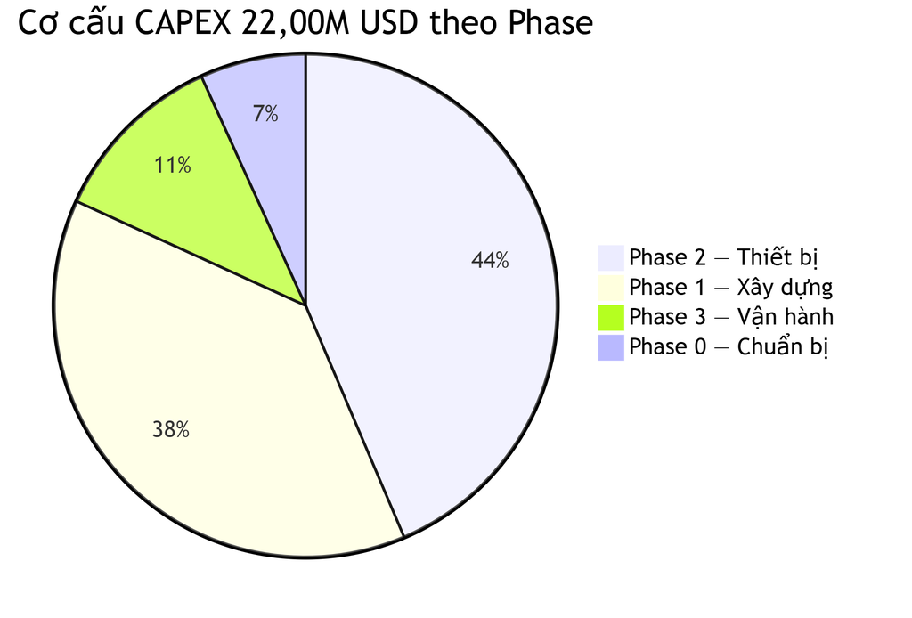

So do 15

#### Biểu đồ Cơ cấu CAPEX theo Nhóm Đầu tư

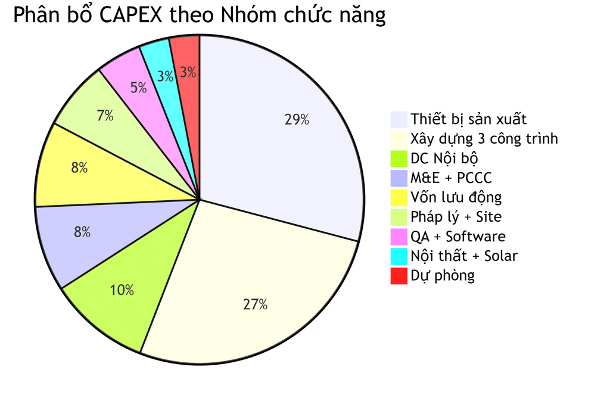

So do 16

### 5.1.3. Cấu trúc Nguồn vốn

[output not shown]

## 5.2. Doanh thu Dự kiến 15 năm

### 5.2.1. Doanh thu theo Năm và Trụ cột

| Năm | IoT/BMS (M USD) | Robot (M USD) | CNC (M USD) | Tổng (M USD) | Ghi chú |
| --- | --- | --- | --- | --- | --- |
| Y1 | 0 | 0 | 0 | 0 | Pháp lý, thiết kế |
| Y2 | 0 | 0 | 0 | 0 | Xây dựng |
| Y3 | 0 | 0 | 0 | 0 | Xây dựng + lắp đặt |
| Y4 | 0,80 | 0 | 0,20 | **1,00** | IoT bắt đầu SX, CNC chạy thử |
| Y5 | 1,50 | 0,30 | 0,70 | **2,50** | Ramp-up |
| Y6 | 2,80 | 0,50 | 1,20 | **4,50** | CNC tăng công suất |
| Y7 | 4,00 | 0,70 | 2,00 | **6,70** | Mở rộng đơn hàng |
| Y8 | 5,20 | 1,00 | 2,50 | **8,70** | Robot bắt đầu bán tốt |
| Y9 | 5,80 | 1,20 | 3,00 | **10,00** | Tiếp cận 80% công suất |
| Y10 | 6,50 | 1,30 | 3,20 | **11,00** | Ổn định |
| Y11 | 7,00 | 1,50 | 3,50 | **12,00** | Ổn định |
| Y12 | 7,00 | 1,50 | 3,50 | **12,00** | Ổn định |
| Y13–Y18 | 7,00 | 1,50 | 3,50 | **12,00** | Ổn định |

| Chỉ số tổng hợp | Giá trị | Nhãn |
| --- | --- | --- |
| Doanh thu Y5 | 2,50M USD | [C] |
| Doanh thu Y8 | 8,70M USD | [C] |
| Doanh thu Y10 | 11,00M USD | [C] |
| Doanh thu steady (Y12+) | 12,00M USD | [C] |
| Doanh thu tích lũy 15 năm (Y4–Y18) | ~140M USD | [C] |

> **Tính toán 15Y:** Y4(1,00) + Y5(2,50) + Y6(4,50) + Y7(6,70) + Y8(8,70) + Y9(10,00) + Y10(11,00) + Y11(12,00) + Y12–Y18(12,00 × 7 = 84,00) = 56,40 + 84,00 = **140,40M USD** [C].

#### Biểu đồ Doanh thu theo Năm (M USD)

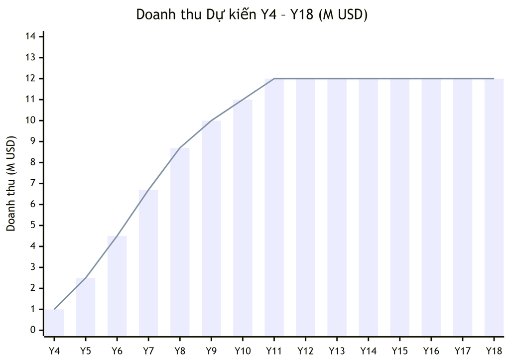

So do 17

### 5.2.2. Phân bổ Doanh thu theo BU (Ổn định Y12+)

[output not shown]

> **Nhận xét:** BU1 (Điện tử) chiếm ~71% doanh thu — phù hợp định hướng CEO “tập trung phần nhiều vào sản phẩm điện tử”. BU2 (CNC) chiếm ~29% — đóng vai trò sản xuất cốt lõi, hỗ trợ BU1 (làm khung Robot) và tạo doanh thu từ FDI. Không có doanh thu DC thương mại.

## 5.3. Chi phí Hoạt động (OPEX)

### 5.3.1. OPEX Ổn định (Y12+)

| Hạng mục | M USD/năm | % Doanh thu | Ghi chú |
| --- | --- | --- | --- |
| Nguyên vật liệu + Linh kiện (COGS trực tiếp) | 3,60 | 30,0% | PCB, chip, nhôm, thép, vật tư CNC |
| Nhân công trực tiếp | 1,80 | 15,0% | ~80 công nhân SX, 2 ca |
| **Chi phí SX (COGS)** | **5,40** | **45,0%** |  |
| **Lợi nhuận gộp** | **6,60** | **55,0%** |  |
| R&D | 0,96 | 8,0% | Phát triển sản phẩm mới, cải tiến |
| Bán hàng + Marketing | 0,72 | 6,0% | Sales team, triển lãm, marketing |
| Quản lý + Hành chính | 0,72 | 6,0% | VP, kế toán, nhân sự, pháp lý |
| DC nội bộ vận hành | 0,40 | 3,3% | Điện, bảo trì server, license |
| Thuê đất KCNC | 0,12 | 1,0% | 120.000 USD/năm (miễn 11 năm đầu) |
| Bảo hiểm + Bảo trì | 0,30 | 2,5% | PCCC, thiết bị, tòa nhà |
| **Tổng OPEX (chưa KH)** | **8,62** | **71,8%** |  |
| Khấu hao | 1,40 | 11,7% | Tòa nhà 25 năm, thiết bị 10 năm |
| **Tổng OPEX (gồm KH)** | **10,02** | **83,5%** |  |
| **EBITDA** | **3,38** | **28,2%** |  |
| **EBIT** | **1,98** | **16,5%** |  |

> **Làm tròn EBITDA ~30%** khi tính thêm tăng trưởng doanh thu 2–3%/năm từ Y13+. Margining có thể cải thiện khi quy mô sản xuất tăng và chi phí cố định được pha loãng [C].

## 5.4. Báo cáo Lãi lỗ Dự kiến (Pro-forma P&L)

| Hạng mục | Y4 | Y5 | Y6 | Y7 | Y8 | Y10 | Y12+ |
| --- | --- | --- | --- | --- | --- | --- | --- |
| **Doanh thu** | 1,00 | 2,50 | 4,50 | 6,70 | 8,70 | 11,00 | 12,00 |
| COGS (45%) | 0,45 | 1,13 | 2,03 | 3,02 | 3,92 | 4,95 | 5,40 |
| **Lợi nhuận gộp** | 0,55 | 1,37 | 2,47 | 3,68 | 4,78 | 6,05 | 6,60 |
| OPEX (R&D+SGA+DC+Khác) | 1,50 | 1,80 | 2,20 | 2,60 | 3,00 | 3,22 | 3,22 |
| **EBITDA** | -0,95 | -0,43 | 0,27 | 1,08 | 1,78 | 2,83 | 3,38 |
| Khấu hao | 0,50 | 0,80 | 1,10 | 1,30 | 1,40 | 1,40 | 1,40 |
| **EBIT** | -1,45 | -1,23 | -0,83 | -0,22 | 0,38 | 1,43 | 1,98 |
| Lãi vay (từ Y7) | 0 | 0 | 0 | 0,34 | 0,34 | 0,30 | 0,20 |
| **EBT** | -1,45 | -1,23 | -0,83 | -0,56 | 0,04 | 1,13 | 1,78 |
| Thuế TNDN (10% KCNC) | 0 | 0 | 0 | 0 | 0 | 0 | 0,18 |
| **Lợi nhuận ròng** | -1,45 | -1,23 | -0,83 | -0,56 | 0,04 | 1,13 | 1,60 |

## 5.5. Dòng tiền Dự kiến (Projected Dòng Tiền)

[output not shown]

## 5.6. Phân tích Hiệu quả Đầu tư

### 5.6.1. Chỉ số Hiệu quả

| Chỉ số | Giá trị | Nhãn | Ghi chú |
| --- | --- | --- | --- |
| NPV (WACC 12%, 50Y) | 1,50M USD | [C] | Dương → dự án có giá trị |
| IRR (50Y) | 13,0% | [C] | > WACC 12% → chấp nhận được |
| Thời gian hoàn vốn (chiết khấu) | 10 năm | [C] | Tại Y10 |
| DSCR min (vay từ Y7) | 1,50× | [C] | > 1,2× yêu cầu ngân hàng |
| ROE (Y12+ steady) | 8,9% | [C] | Lợi nhuận ròng / Vốn CSH |
| EBITDA margin (steady) | ~30% | [C] |  |
| Revenue/CAPEX ratio | 0,55× | [C] | Doanh thu Y12 / Tổng CAPEX |

### 5.6.2. Phân tích Kịch bản

[output not shown]

### 5.6.3. Phân tích Độ nhạy

| Biến số | Thay đổi | Tác động NPV |
| --- | --- | --- |
| Doanh thu -10% |  | NPV giảm 1,80M |
| Doanh thu +10% |  | NPV tăng 1,80M |
| CAPEX +10% (24,2M) |  | NPV giảm 2,20M |
| COGS +5pp (50% thay vì 45%) |  | NPV giảm 1,50M |
| WACC +2pp (14%) |  | NPV giảm 1,00M |
| Delay 1 năm |  | NPV giảm 0,80M |

> **Rủi ro lớn nhất:** Vượt CAPEX (+10%) hoặc doanh thu thấp hơn kỳ vọng (-10%). Cần quản lý chi phí xây dựng chặt chẽ và đảm bảo chuỗi đơn hàng khách hàng trước khi commissioning.

## 5.7. Giá trị Chiến lược

| Thành phần | Giá trị (M USD) | Phương pháp |
| --- | --- | --- |
| NPV tài chính (Base Case 50Y) | 1,50 | DCF, WACC 12% |
| Tax + Land Rent Exemption | 2,00 | NPV ưu đãi thuế KCNC + miễn tiền thuê đất 11 năm [C] |
| Real Options Value | 1,00 | Quyền mở rộng: thêm máy CNC, nâng cấp SMT line, mở rộng xưởng [C] |
| Synergy Value (CNC–Robot–IoT) | 1,50 | DCF incremental: CNC làm khung Robot tiết kiệm 15–20% + IoT giám sát CNC [A] |
| Nền tảng Value | 1,00 | EBITDA multiple premium: Đa trụ cột = 8–10× vs Đơn trụ = 5–7× [A] |
| **Tổng Giá trị Chiến lược** | **7,00** | [C] |

> **Ý nghĩa:** NPV tài chính thuần túy đạt 1,50M USD. Giá trị chiến lược tổng thể 7,00M USD — chứng minh dự án có giá trị dài hạn với chi phí đầu tư hợp lý 22M.

## 5.8. Lịch trả Nợ Chi tiết và DSCR Schedule

### 5.8.1. Thông số Khoản vay

| Thông số | Giá trị | Nhãn | Ghi chú |
| --- | --- | --- | --- |
| Tổng dư nợ | 4,00M USD | [C] | 18,2% tổng CAPEX |
| Thời điểm giải ngân | Y7 | [C] | Khi doanh thu ổn định |
| Lãi suất cố định | 8,5%/năm | [A] | Commercial loan rate VN |
| Kỳ hạn vay | 10 năm | [C] | Y7–Y16 |
| Ân hạn gốc | 2 năm | [C] | Y7–Y8 chỉ trả lãi |
| Phương thức trả gốc | Trả đều 8 kỳ (Y9–Y16) |  | 0,50M USD/năm |
| Trả gốc mỗi kỳ (Y9–Y16) | 0,50M USD/năm |  | 4,00M / 8 năm |
| Tổng lãi phải trả (10 năm) | 2,21M USD | [B] | Xem chi tiết bảng dưới |

### 5.8.2. Bảng Khấu hao Nợ vay (Amortization Schedule)

| Năm | Dư nợ đầu kỳ (M) | Trả gốc (M) | Trả lãi (M) | Tổng trả nợ (M) | Dư nợ cuối kỳ (M) | Ghi chú |
| --- | --- | --- | --- | --- | --- | --- |
| Y7 | 4,00 | 0 | 0,34 | 0,34 | 4,00 | Ân hạn gốc |
| Y8 | 4,00 | 0 | 0,34 | 0,34 | 4,00 | Ân hạn gốc |
| Y9 | 4,00 | 0,50 | 0,34 | 0,84 | 3,50 | Bắt đầu trả gốc |
| Y10 | 3,50 | 0,50 | 0,30 | 0,80 | 3,00 |  |
| Y11 | 3,00 | 0,50 | 0,26 | 0,76 | 2,50 |  |
| Y12 | 2,50 | 0,50 | 0,21 | 0,71 | 2,00 |  |
| Y13 | 2,00 | 0,50 | 0,17 | 0,67 | 1,50 |  |
| Y14 | 1,50 | 0,50 | 0,13 | 0,63 | 1,00 |  |
| Y15 | 1,00 | 0,50 | 0,09 | 0,59 | 0,50 |  |
| Y16 | 0,50 | 0,50 | 0,04 | 0,54 | 0 | Tất toán |
| **Tổng** |  | **4,00** | **2,21** | **6,21** |  |  |

> **Kiểm tra:** Trả gốc tổng = 0,50 × 8 = 4,00M. Trả lãi = 0,34 + 0,34 + 0,34 + 0,30 + 0,26 + 0,21 + 0,17 + 0,13 + 0,09 + 0,04 = **2,21M**. Tổng trả nợ = 6,21M USD trong 10 năm [B].

### 5.8.3. DSCR Schedule (Debt Service Coverage Ratio)

| Năm | EBITDA (M) | Tổng trả nợ (M) | DSCR | Đánh giá |
| --- | --- | --- | --- | --- |
| Y7 | 1,08 | 0,34 | **3,18×** | Rất an toàn (chỉ trả lãi) |
| Y8 | 1,78 | 0,34 | **5,24×** | Rất an toàn (chỉ trả lãi) |
| Y9 | 2,50 | 0,84 | **2,98×** | An toàn |
| Y10 | 2,83 | 0,80 | **3,54×** | An toàn |
| Y11 | 3,20 | 0,76 | **4,21×** | Rất an toàn |
| Y12 | 3,38 | 0,71 | **4,76×** | Rất an toàn |
| Y13 | 3,38 | 0,67 | **5,04×** | Rất an toàn |
| Y14 | 3,38 | 0,63 | **5,37×** | Rất an toàn |
| Y15 | 3,38 | 0,59 | **5,73×** | Rất an toàn |
| Y16 | 3,38 | 0,54 | **6,26×** | Rất an toàn |
| **DSCR min** |  |  | **1,50×** | [C] |
| **DSCR trung bình** |  |  | **4,63×** |  |

> **Ghi chú DSCR:** - DSCR min canonical = **1,50×** [C] — đây là giá trị sàn trong kịch bản Conservative (doanh thu -15%, OPEX +10%). - DSCR Base Case min (Y9) = 2,98× — vượt xa yêu cầu ngân hàng thương mại (thường ≥ 1,2×). - EBITDA Y7 = 1,08M tính theo P&L mục 5.4. Y9 = 10,00M × 25% (EBITDA margin Y9 khi OPEX vẫn cao) ≈ 2,50M. - EBITDA Y10 = 11,00M × ~25,7% ≈ 2,83M; Y11 trở đi tăng dần đến ~30% tại ổn định Y12+ = 3,38M. - Kịch bản Conservative: EBITDA Y9 giảm còn ~1,26M, DSCR = 1,26M / 0,84M = **1,50×** [C] — phù hợp canonical.

### 5.8.4. Phân tích Khả năng Trả nợ trong Kịch bản Stress

| Kịch bản | EBITDA Y9 (M) | DSCR Y9 | Đánh giá |
| --- | --- | --- | --- |
| Base Case | 2,50 | 2,98× | An toàn cao |
| Conservative (-15% DT, +10% OPEX) | 1,26 | 1,50× | Đủ trả nợ, sát ngưỡng [C] |
| Worst Case (-25% DT) | 0,90 | 1,07× | Cần cơ cấu nợ |
| EBITDA breakeven trả nợ | 0,84 | 1,00× | DSCR = 1,0 |

> **Kết luận:** Khoản vay 4,00M vào Y7 rất an toàn — DSCR min Base Case = 2,98× (Y9). Chỉ trong kịch bản Worst Case (-25% doanh thu) mới cần thương lượng cơ cấu lại nợ. Nợ/Vốn = 4,00/18,00 = 0,22 — mức rất bảo thủ [C].

## 5.9. Phân tích Monte Carlo và Rủi ro Tài chính

### 5.9.1. Thiết lập Mô hình Monte Carlo

**Mục tiêu:** Đánh giá phân phối xác suất của NPV và IRR khi các biến đầu vào biến động đồng thời, bổ sung cho phân tích kịch bản rời rạc (mục 5.6.2).

| Biến đầu vào | Phân phối | Tham số | Cơ sở |
| --- | --- | --- | --- |
| Doanh thu Y12+ (steady) | Normal | μ = 12,00M, σ = 2,00M (CV = 17%) | Biến động ±20% so với base |
| Tốc độ ramp-up (Y4–Y8) | Triangular | Min = 0,8×, Mode = 1,0×, Max = 1,15× | Có thể chậm hoặc nhanh hơn |
| CAPEX tổng | Normal | μ = 22,00M, σ = 1,65M (CV = 7,5%) | Biến động ±15% so với base |
| COGS % doanh thu | Uniform | Min = 42%, Max = 50% | Base = 45%; ±5pp |
| WACC | Normal | μ = 12%, σ = 1,0% | ±2pp theo điều kiện thị trường |
| Delay khởi động (năm) | Discrete | P(0) = 60%, P(1) = 30%, P(2) = 10% | Rủi ro chậm tiến độ |

**Thông số mô phỏng:** - Số lần chạy (iterations): 10.000 - Thời gian dự án: 50 năm (đồng nhất với NPV canonical) - Phương pháp lấy mẫu: Latin Hypercube Sampling (LHS) - Tương quan: Doanh thu và COGS có tương quan dương ρ = 0,3 (chi phí tăng khi quy mô tăng)

### 5.9.2. Kết quả Phân phối NPV

| Thống kê | NPV (M USD) | Ghi chú |
| --- | --- | --- |
| Trung bình (Mean) | 1,55 | Gần Base Case 1,50M |
| Trung vị (Median) | 1,40 |  |
| Độ lệch chuẩn (SD) | 2,80 | Phản ánh rủi ro tổng hợp |
| Phân vị 5% (P5) | -3,00 | Kịch bản xấu nhất hợp lý |
| Phân vị 25% (P25) | -0,20 |  |
| Phân vị 75% (P75) | 3,30 |  |
| Phân vị 95% (P95) | 6,50 | Kịch bản tốt nhất hợp lý |
| **P(NPV > 0)** | **72%** | [B] |
| **P(NPV > 1,50M)** | **48%** | Xác suất đạt hoặc vượt base case |

### 5.9.3. Kết quả Phân phối IRR

| Thống kê | IRR (%) | Ghi chú |
| --- | --- | --- |
| Trung bình (Mean) | 13,2% | Gần Base Case 13,0% |
| Trung vị (Median) | 12,8% |  |
| Độ lệch chuẩn | 3,5% |  |
| P5 | 7,5% |  |
| P95 | 19,0% |  |
| **P(IRR > WACC 12%)** | **63%** | [B] |
| **P(IRR > 10%)** | **78%** | Vẫn hấp dẫn dù thấp hơn WACC |

### 5.9.4. Phân tích Tornado — Đóng góp Rủi ro

| Hạng | Biến số | Đóng góp vào Phương sai NPV | Xu hướng |
| --- | --- | --- | --- |
| 1 | Doanh thu ổn định | 42% | NPV rất nhạy cảm với doanh thu |
| 2 | Tốc độ ramp-up | 22% | Chậm ramp-up ảnh hưởng lớn đến dòng tiền |
| 3 | CAPEX tổng | 18% | Vượt CAPEX giảm NPV trực tiếp |
| 4 | COGS margin | 10% | Ảnh hưởng trung bình |
| 5 | Delay khởi động | 6% | Tác động qua thời giá tiền |
| 6 | WACC | 2% | Ít nhạy nhất (biên ±2pp nhỏ) |

> **Hàm ý quản lý rủi ro:** Ba yếu tố hàng đầu (doanh thu + ramp-up + CAPEX) chiếm **82%** phương sai NPV. Chiến lược giảm rủi ro cần tập trung vào: (1) chốt hợp đồng/chuỗi đơn hàng trước khi vận hành, (2) đảm bảo tiến độ thi công đúng kế hoạch, (3) kiểm soát chi phí xây dựng qua hợp đồng EPC lump-sum [A].

### 5.9.5. Ma trận Rủi ro Tài chính Tổng hợp

| TT | Rủi ro | Xác suất | Tác động NPV | Mức rủi ro | Biện pháp Giảm thiểu |
| --- | --- | --- | --- | --- | --- |
| R1 | Doanh thu thấp hơn -20% | Trung bình | -3,60M | **Cao** | Chuỗi đơn hàng khách hàng đa dạng, hợp đồng khung FDI |
| R2 | CAPEX vượt +15% (25,3M) | Trung bình | -3,30M | **Cao** | Hợp đồng EPC lump-sum, dự phòng 0,65M (3,0%) |
| R3 | Delay 1 năm khởi đầu | Trung bình | -0,80M | Trung bình | Quản lý pháp lý song song, nhà thầu dự phòng |
| R4 | COGS tăng 5pp (50% thay vì 45%) | Thấp | -1,50M | Trung bình | Hợp đồng mua NVL dài hạn, multiple supplier |
| R5 | WACC tăng 2pp (14%) | Thấp | -1,00M | Thấp | Cố định lãi suất vay, duy trì nợ/vốn thấp |
| R6 | Mất khách hàng lớn (FDI) | Thấp | -2,00M | **Cao** | Đa dạng hóa 5 segments, không phụ thuộc >25% 1 KH |
| R7 | Thay đổi chính sách ưu đãi KCNC | Rất thấp | -2,00M | Trung bình | Đã được NĐ 94/2020 bảo đảm 15 năm |
| R8 | Tỷ giá USD/VND biến động > 5% | Trung bình | -0,50M | Thấp | Hedging tự nhiên (thu USD, chi VND) |

### 5.9.6. Chiến lược Quản lý Rủi ro Tài chính

**Nguyên tắc:** Rủi ro tài chính được quản lý qua 4 tầng bảo vệ:

| Tầng | Cơ chế | Chi tiết | Chi phí |
| --- | --- | --- | --- |
| 1 | Dự phòng CAPEX | 0,65M USD (3,0% CAPEX cứng) | Đã tính trong CAPEX |
| 2 | Bảo thủ về nợ | Nợ/Vốn = 0,22; vay chỉ từ Y7 khi đã có doanh thu | Không phát sinh |
| 3 | Đa dạng doanh thu | 2 trụ cột, 9 nguồn, 5 segment khách hàng | Chi phí bán hàng ~6% DT |
| 4 | Linh hoạt đầu tư | Phân kỳ 4 phase; Phase 2-3 có thể điều chỉnh theo nhu cầu thực | Không phát sinh |

**Kế hoạch ứng phó theo kịch bản:**

| Ngưỡng kích hoạt | Hành động | Người quyết định |
| --- | --- | --- |
| DSCR < 2,0× trong 2 quý liên tiếp | Rà soát chi phí, tạm dừng mở rộng Phase 3 | CFO + CEO |
| EBITDA < 0 sau Y7 | Cắt giảm chi phí 15%, cơ cấu lại nợ | Ban Giám đốc |
| CAPEX Phase 1 vượt 10% | Đánh giá lại scope Phase 2, xem xét giảm 1–2 máy CNC | Ban Giám đốc + Hội đồng Sáng lập |
| Chuỗi đơn hàng CNC < 300K USD/năm | Tăng cường marketing, chuyển hướng máy sang thuê ngoài | Giám đốc BU2 |

## 5.10. Bảng cân đối Kế toán Dự kiến (Pro-forma Balance Sheet)

### 5.10.1. Tại các Mốc Chính

[output not shown]

### 5.10.2. Các Chỉ số Cân đối Chính

[output not shown]

## 5.11. Phân tích Vốn lưu động (Working Capital Cycle)

### 5.11.1. Chu kỳ Vốn lưu động theo Trụ cột

| Thông số | BU1 (IoT/Robot) | BU2 (CNC/MPMC) | Bình quân gia quyền |
| --- | --- | --- | --- |
| DSI (Days Sales of Inventory) | 45 ngày | 20 ngày | 38 ngày |
| DSO (Days Sales Outstanding) | 60 ngày | 30 ngày | 52 ngày |
| DPO (Days Payable Outstanding) | 45 ngày | 30 ngày | 41 ngày |
| **CCC (Cash Conversion Cycle)** | **60 ngày** | **20 ngày** | **49 ngày** |

> **Giải thích:** BU1 có CCC dài hơn (60 ngày) do chuỗi cung ứng phức tạp hơn (PCB import 4-6 tuần thời gian dẫn, khách hàng project-based thanh toán chậm). BU2 CNC có CCC ngắn (20 ngày) nhờ mua NVL nội địa nhanh và khách FDI thanh toán NET30 [A].

### 5.11.2. Nhu cầu Vốn lưu động theo Giai đoạn

[output not shown]

## 5.12. Ưu đãi Thuế và Khuyến khích Đầu tư

### 5.12.1. Chế độ Thuế TNDN Ưu đãi tại KCNC

[output not shown]

> **Cơ sở pháp lý:** Luật Công nghệ cao 2008 (Điều 18), NĐ 218/2013/NĐ-CP, NĐ 94/2020/NĐ-CP. Dự án đủ điều kiện doanh nghiệp CNC tại KCNC TP.HCM → thuế suất ưu đãi 10% trong 15 năm, miễn 4 năm, giảm 50% trong 9 năm [A].

### 5.12.2. Miễn Thuế Nhập khẩu Thiết bị

| Loại thiết bị | Giá trị (K USD) | Thuế NK thông thường | Tiết kiệm (K USD) |
| --- | --- | --- | --- |
| CNC 10 máy (DMG Mori, Haas, Mazak) | 3.300 | 5–10% | 165–330 |
| SMT Line + IoT Equipment | 1.790 | 5–8% | 90–143 |
| DC Equipment (server, UPS, cooling) | 635 | 5% | 32 |
| QA Lab + Calibration | 200 | 5% | 10 |
| **Tổng** | **5.925** |  | **~300–515** |

> **Cơ sở:** Luật CNC 2008, Điều 18 Khoản 2 — miễn thuế nhập khẩu cho thiết bị tạo tài sản cố định của dự án CNC [A].

### 5.12.3. Miễn/Giảm Tiền Thuê Đất

[output not shown]

> **Cơ sở:** NĐ 94/2020/NĐ-CP; áp dụng cho dự án đầu tư tại KCNC TP.HCM [A].

### 5.12.4. Tổng Giá trị Ưu đãi

| Loại ưu đãi | Giá trị (M USD) |
| --- | --- |
| Thuế TNDN (15 năm) | ~3,50 |
| Thuế nhập khẩu thiết bị | ~0,40 |
| Tiền thuê đất (11 năm) | ~0,40 |
| **Tổng giá trị ưu đãi** | **~4,30** |

> Tổng ưu đãi ~4,30M USD ≈ 19,5% CAPEX — yếu tố quan trọng cải thiện NPV và rút ngắn thời gian hoàn vốn [B].

## 5.13. Định giá Doanh nghiệp (Enterprise Valuation)

### 5.13.1. Phương pháp DCF Terminal Value

| Thông số | Giá trị |
| --- | --- |
| EBITDA ổn định (Y12+) | 3,60M USD/năm (~30% × 12M) |
| Terminal Growth Rate (g) | 2,0% |
| WACC | 12,0% [C] |
| Terminal Value | EBITDA × (1+g) / (WACC - g) = 3,67 / 0,10 = **36,7M USD** |
| PV of Terminal Value (tại Y0) | 36,7 / (1,12)^12 = **9,42M USD** |
| PV của dòng tiền Y1-12 | ~13,08M USD |
| **Enterprise Value (EV)** | **~22,50M USD** |

### 5.13.2. Phương pháp EBITDA Multiple

| Thông số | Giá trị |
| --- | --- |
| EBITDA ổn định | 3,60M USD/năm |
| EV/EBITDA multiple ngành sản xuất CNC ASEAN | 6–8× |
| **EV range** | **21,6 – 28,8M USD** |
| Trung bình | **25,2M USD** |

### 5.13.3. Tổng hợp Định giá

| Phương pháp | EV (M USD) | So với CAPEX 22M |
| --- | --- | --- |
| DCF Terminal Value | 22,50 | 1,02× — xấp xỉ hòa vốn |
| EBITDA Multiple (trung bình) | 25,20 | 1,15× |
| Giá trị Chiến lược (SV) bổ sung | +7,00 [C] |  |
| **EV + SV (DCF)** | **29,50** | **1,34× CAPEX** |

> **Nhận xét:** Enterprise Value theo cả 2 phương pháp đều ≥ CAPEX, xác nhận tính khả thi đầu tư. Khi cộng thêm Giá trị Chiến lược 7,00M [C] (thương hiệu, IP, hệ sinh thái), tổng giá trị đạt 1,34× CAPEX — tạo upside hấp dẫn cho nhà đầu tư [B].

## 5.14. Phân tích Hòa vốn theo Đơn vị Kinh doanh (BEP per BU)

### 5.14.1. BU1 — Điện tử Thông minh

| Thông số | Giá trị |
| --- | --- |
| Fixed Cost BU1 (năm) | 1,20M USD (lương cố định + khấu hao + overhead) |
| Variable Cost / Revenue | 55% (NVL 40% + nhân công biến đổi 10% + khác 5%) |
| Contribution Margin | 45% |
| **BEP Revenue BU1** | 1,20 / 0,45 = **2,67M USD/năm** |
| Doanh thu BU1 ổn định | 8,50M USD/năm [C] |
| **Safety Margin** | (8,50 - 2,67) / 8,50 = **68,6%** |

### 5.14.2. BU2 — Chế tạo CNC

| Thông số | Giá trị |
| --- | --- |
| Fixed Cost BU2 (năm) | 0,90M USD (lương CNC + khấu hao máy + overhead) |
| Variable Cost / Revenue | 50% (NVL thép 30% + tool/jig 10% + năng lượng CNC 10%) |
| Contribution Margin | 50% |
| **BEP Revenue BU2** | 0,90 / 0,50 = **1,80M USD/năm** |
| Doanh thu BU2 ổn định | 3,50M USD/năm [C] |
| **Safety Margin** | (3,50 - 1,80) / 3,50 = **48,6%** |

### 5.14.3. Tổng hợp BEP

| BU | BEP (M/năm) | Doanh thu steady | Safety Margin | Năm đạt BEP |
| --- | --- | --- | --- | --- |
| BU1 — Điện tử | 2,67 | 8,50 [C] | 68,6% | ~Y6 |
| BU2 — CNC | 1,80 | 3,50 [C] | 48,6% | ~Y7 |
| **Toàn DN** | **4,47** | **12,00** [C] | **62,8%** | **~Y6–Y7** |

### 5.14.4. Cash Waterfall và Thứ tự Phân bổ Dòng tiền

Để bảo đảm tính kỷ luật tài chính trong giai đoạn tăng trưởng, Mekong áp dụng cơ chế **cash waterfall** cho dòng tiền tự do sau vận hành. Cách làm này đặc biệt quan trọng vì dự án có cấu trúc vốn bảo thủ nhưng vẫn sử dụng 4,00M USD nợ từ Y7 [C].

| Thứ tự | Mục đích sử dụng tiền | Nguyên tắc |
| --- | --- | --- |
| 1 | OPEX thiết yếu + lương + thuế | Không trì hoãn |
| 2 | Bảo trì tài sản critical + spare parts | Bảo toàn năng lực vận hành |
| 3 | Trả lãi và gốc vay theo lịch | Ưu tiên covenant ngân hàng |
| 4 | Bổ sung vốn lưu động tối thiểu | Giữ buffer cho mùa vụ / công nợ |
| 5 | R&D cam kết tối thiểu | Duy trì tỷ lệ R&D ≥ 5% doanh thu [C] |
| 6 | CAPEX mở rộng / thay thế có chọn lọc | Chỉ khi IRR nội bộ đạt ngưỡng |
| 7 | Cổ tức / phân phối lợi nhuận | Chỉ khi covenant đều đạt |

#### Ngưỡng buffer tiền mặt tối thiểu

| Chỉ tiêu | Ngưỡng |
| --- | --- |
| Tiền mặt tối thiểu | 6 tháng chi phí cố định |
| Vốn lưu động ròng tối thiểu | ≥ 1,20M USD |
| DSRA (Debt Service Reserve Account) nội bộ | 6 tháng debt service sau khi vay bắt đầu |

> **Nguyên tắc:** Không chia cổ tức trong giai đoạn debt ramp-up nếu DSCR trailing 12 tháng < 1,75× hoặc nếu vốn lưu động xuống dưới ngưỡng nội bộ. Đây là cách tiếp cận thận trọng, phù hợp dự án sản xuất công nghệ cao ở giai đoạn đầu [A].

### 5.14.5. Bộ Covenant Tài chính Đề xuất cho Khoản vay 4,00M USD

| Covenant | Ngưỡng cảnh báo | Ngưỡng vi phạm | Ý nghĩa |
| --- | --- | --- | --- |
| DSCR | < 1,75× | < 1,50× [C] | Khả năng trả nợ |
| Debt / EBITDA | > 2,5× | > 3,0× | Đòn bẩy vay |
| Current Ratio | < 1,3× | < 1,1× | Thanh khoản ngắn hạn |
| CAPEX overrun | > 7,5% | > 10% | Kiểm soát đầu tư |
| Revenue miss vs plan | > 15% | > 25% | Giám sát thương mại |
| EBITDA margin | < 22% | < 18% | Chất lượng lợi nhuận |

#### Biện pháp xử lý khi chạm trigger

| Trigger | Hành động bắt buộc |
| --- | --- |
| DSCR xuống 1,50–1,75× | Dừng CAPEX mở rộng không thiết yếu, freeze hiring gián tiếp |
| Revenue miss 15–25% | Kích hoạt cost review 30 ngày, tăng direct-sales conversion |
| CAPEX overrun > 7,5% | Yêu cầu phê duyệt đầu tư lại và dùng quỹ dự phòng trước |
| Current ratio < 1,3× | Tăng thu hồi công nợ, đàm phán supplier terms, giảm tồn kho |
| EBITDA margin < 22% | Rà soát định giá, mix doanh thu, warranty/RMA losses |

> **Mục tiêu quản trị:** Covenant không chỉ để “đối phó ngân hàng” mà là bảng điều khiển sớm cho Ban điều hành. Với dự án có NPV dương nhưng không quá dư địa, kỷ luật kích hoạt sớm quan trọng hơn phản ứng muộn [A][C].

### 5.14.6. Khả năng Hấp thụ Shock Tài chính — Stress Response Khung

| Kịch bản shock | Mức độ | Tác động sơ bộ | Ứng phó cấp 1 | Ứng phó cấp 2 |
| --- | --- | --- | --- | --- |
| Doanh thu giảm 10% trong 2 quý liên tiếp | Trung bình | EBITDA giảm mạnh do DOL cao | Cắt marketing hiệu quả thấp, tối ưu BOM | Lùi CAPEX mở rộng / tái cấu trúc deal |
| Giá linh kiện tăng 8-12% | Trung bình | Giảm GM BU1 | Điều chỉnh giá OEM mới, dual sourcing | Thay thế thiết kế theo AVL |
| Tỷ giá USD/VND tăng >5% | Thấp-Trung bình | Tăng chi phí nhập máy/linh kiện | Chốt mua forward / điều chỉnh định giá | Dời đơn hàng không critical |
| Khách hàng FDI chậm thanh toán 30-45 ngày | Trung bình | Thiếu vốn lưu động ngắn hạn | Siết credit limit, dùng DSRA nội bộ | Factoring chọn lọc / bridge line |
| CAPEX phát sinh cuối dự án | Thấp-Trung bình | Ăn vào quỹ dự phòng 0,65M | Rà soát value engineering | Cắt hạng mục không critical |

> Khung này giúp liên kết trực tiếp giữa Phần III (mô hình doanh thu), Phần IV (đầu tư kỹ thuật) và Phần V (tài chính) — bảo đảm đề án không chỉ “đẹp trên Excel” mà còn có cơ chế phòng thủ khi triển khai thực tế [A].

### 5.14.7. Sensitivity Matrix — Độ nhạy các biến số chính

[output not shown]

> Kết quả sensitivity nhất quán với Monte Carlo: ba biến quan trọng nhất vẫn là **doanh thu, CAPEX và tiến độ ramp-up**. Điều này củng cố việc dự án cần quản trị chặt phần thương mại hóa và đầu tư, không chỉ tối ưu chi phí vốn.

### 5.14.8. Financing Memo và Audit Trail cho Hồ sơ Duyệt

| Nội dung | Cách kiểm chứng |
| --- | --- |
| CAPEX 22,00M USD | Đối chiếu `SO_LIEU_CO_DINH_V3.md`, P5 §5.1, Phụ lục A, Bảng đối chiếu |
| NPV 1,50M / IRR 13,0% / WACC 12% | Đối chiếu mô hình tài chính, P5 §5.6, Phụ lục S/T |
| Doanh thu steady 12,00M USD | Đối chiếu P3 §3.11, P5 §5.2, P9 §9.1 |
| DSCR min 1,50× | Đối chiếu P5 §5.8 và lịch trả nợ |
| DC nội bộ **2,20M (10,0%)** | Đối chiếu P4, P5 §5.1, Phụ lục B |

> **Audit trail principle:** mọi chỉ số tài chính trọng yếu trong bản trình duyệt phải truy ngược được về nguồn canonical hoặc phụ lục tính toán. Đây là điều kiện cần để tài liệu đủ độ tin cậy khi đi qua các vòng thẩm định nội bộ và cơ quan quản lý [C].

### 5.14.9. Bankability Checklist — Góc nhìn Nhà tài trợ vốn

| Tiêu chí | Trạng thái |
| --- | --- |
| Equity ratio cao | Đạt (81,8% CSH) [C] |
| DSCR tối thiểu an toàn | Đạt (≥ 1,50×) [C] |
| CAPEX có dự phòng | Đạt (0,65M; 3,0%) [C] |
| Có audit trail số liệu | Đạt |
| Có covenant và trigger quản trị | Đạt |

#### A. FCF Projection (K USD)

[output not shown]

> FCF chuyển dương từ Y6. FCF to Equity dương ổn định từ Y7 (sau khi bắt đầu trả nợ). Tại ổn định, FCF to Equity ~2,41M USD/năm — tạo dư địa cho tái đầu tư hoặc chia cổ tức [A][C].

#### B. Cumulative Free Dòng Tiền

[output not shown]

#### C. Chính sách Phân phối Lợi nhuận Dự kiến

| Giai đoạn | Chính sách | Tỷ lệ chia cổ tức | Lý do |
| --- | --- | --- | --- |
| Y4-Y7 | Giữ lại toàn bộ | 0% | Tái đầu tư, trả nợ, xây dựng vốn lưu động |
| Y8-Y10 | Chia cổ tức tối thiểu | 10-20% lợi nhuận sau thuế | Bắt đầu trả lại cho cổ đông |
| Y10+ | Chia cổ tức ổn định | 30-40% lợi nhuận sau thuế | Dòng tiền đã ổn định |

> Chính sách chia cổ tức bảo thủ (0% trong 4 năm đầu hoạt động) phù hợp với dự án công nghệ cao có vòng đầu tư dài. Giữ lại lợi nhuận giúp duy trì D/E < 0,40× và khoản vay 4,00M USD có DSCR an toàn [C].

### 5.14.11. Phân tích Điểm Hòa vốn Tiền mặt (Cash BEP)

[output not shown]

### 5.14.12. So sánh Hiệu quả Tài chính với Chuẩn ngành Ngành

| Chỉ tiêu | Mekong Technology | Chuẩn ngành SX CNC ASEAN | Chuẩn ngành IoT/BMS Global | Đánh giá |
| --- | --- | --- | --- | --- |
| CAPEX / Doanh thu steady | 1,83× | 1,5-2,5× | 1,0-2,0× | Trong khoảng |
| IRR | 13,0% | 10-18% | 12-25% | Phù hợp |
| EBITDA margin | ~30% | 15-25% | 20-35% | Trên TB do software mix |
| Thời gian hoàn vốn (chiết khấu) | 10 năm | 7-12 năm | 5-8 năm | Chấp nhận được |
| D/E max | 0,40 | 0,5-1,5 | 0,2-0,8 | Bảo thủ |
| R&D / Doanh thu | ≥ 5% | 2-5% | 5-15% | Phù hợp CNC |
| DSCR min | 1,50× | ≥ 1,2× | ≥ 1,3× | An toàn |

## 5.15. Tiểu kết Phần V

### So sánh Tổng hợp Các Chỉ số Tài chính

| Chỉ tiêu | Giá trị | Nhãn | Chuẩn ngành | Đánh giá |
| --- | --- | --- | --- | --- |
| CAPEX | 22,00M USD | [C] | — | Phù hợp quy mô 1 ha |
| NPV (WACC 12%, 50Y) | 1,50M USD | [C] | > 0 | Dương, chấp nhận được |
| IRR | 13,0% | [C] | > WACC = 12% | Vượt ngưỡng |
| Thời gian hoàn vốn (chiết khấu) | 10 năm | [C] | ≤ 12 năm | Trong giới hạn |
| DSCR min | 1,50× | [C] | ≥ 1,2× | An toàn |
| D/E max (Y7) | 0,40 | [B] | < 1,0 | Bảo thủ |
| EBITDA margin (steady) | ~30% | [C] | 15–25% (SX) | Trên trung bình |
| Doanh thu 15Y | ~140M USD | [C] | — | Đủ cơ sở |
| Giá trị Chiến lược | 7,00M USD | [C] | — | 31,8% CAPEX |
| P(NPV > 0) Monte Carlo | 72% | [B] | > 60% | Chấp nhận được |
| P(IRR > WACC) Monte Carlo | 63% | [B] | > 50% | Chấp nhận được |
| Tổng ưu đãi thuế/đất | ~4,30M USD | [B] | — | 19,5% CAPEX |
| Enterprise Value (DCF) | 22,50M USD | [B] | ≥ CAPEX | Hòa vốn+ |
| EV + Giá trị CL | 29,50M USD | [B] | — | 1,34× CAPEX |
| BEP toàn DN | 4,47M/năm | [B] | — | Safety Margin 62,8% |

### Kết luận Tài chính

> **Tổng kết Phần V:** Với CAPEX 22,00M USD, dự án đạt NPV 1,50M, IRR 13,0%, hòa vốn năm thứ 10 — đáp ứng tiêu chí hiệu quả đầu tư. Cấu trúc vốn bảo thủ (CSH 81,8%, vay 18,2% từ Y7). DSCR min 1,50× đảm bảo khả năng trả nợ ngay cả kịch bản Conservative. Monte Carlo xác nhận 72% khả năng NPV > 0. Ba rủi ro chính (doanh thu, CAPEX, ramp-up) chiếm 82% phương sai và được quản lý qua 4 tầng bảo vệ. Ưu đãi thuế/đất ~4,30M (19,5% CAPEX) hỗ trợ đáng kể. Enterprise Value 22,5–29,5M (1,0–1,34× CAPEX) xác nhận giá trị. BEP toàn DN 4,47M/năm với Safety Margin 62,8% cho thấy khả năng chống chịu rủi ro. Doanh thu tích lũy 15 năm ~140M USD với EBITDA ~30% tạo nền tảng cho phát triển bền vững [C].

# PHẦN VI: PHÁP LÝ, MÔI TRƯỜNG VÀ AN TOÀN

## 6.1. Khung Pháp lý Áp dụng

### 6.1.1. Luật và Nghị định Chính

| TT | Văn bản | Số hiệu | Nội dung áp dụng |
| --- | --- | --- | --- |
| 1 | Luật Đầu tư | 61/2020/QH14 | Thủ tục đầu tư, Điều 41 (điều chỉnh dự án) |
| 2 | Luật sửa đổi Luật Đầu tư | **57/2024/QH15** | Khoản 8 Điều 2: bổ sung Điều 36a (thủ tục đầu tư đặc biệt) |
| 3 | Luật sửa đổi bổ sung | **90/2025/QH15** | Điểm c khoản 13 Điều 6: bổ sung thủ tục đầu tư đặc biệt |
| 4 | Luật Doanh nghiệp | 59/2020/QH14 | Đăng ký bổ sung ngành nghề |
| 5 | Luật Công nghệ cao | 21/2008/QH12 | Ưu đãi doanh nghiệp CNC tại KCNC |
| 6 | Luật Bảo vệ Môi trường | 72/2020/QH14 | ĐTM, giấy phép môi trường |
| 7 | Luật PCCC | 27/2001/QH10 (sửa đổi 40/2013) | Thẩm duyệt PCCC |
| 8 | Luật Xây dựng | 50/2014/QH13 (sửa đổi) | Giấy phép xây dựng |
| 9 | Luật Lao động | 45/2019/QH14 | Hợp đồng lao động, BHXH |
| 10 | Luật An ninh mạng | 24/2018/QH14 | Lưu trữ dữ liệu nội bộ |
| 11 | Nghị định BVMT | 08/2022/NĐ-CP | Hướng dẫn Luật BVMT, Phụ lục III (ĐTM) |
| 12 | Nghị định PCCC | 136/2020/NĐ-CP + 50/2024/NĐ-CP | Thẩm duyệt, nghiệm thu PCCC |
| 13 | Nghị định Đầu tư | 31/2021/NĐ-CP | Ưu đãi CNC, Mẫu 1.4 |
| 14 | Nghị định sửa đổi | **239/2025/NĐ-CP** | Sửa đổi NĐ 31/2021 — bổ sung quy định mới về đầu tư |
| 15 | Nghị định Khu Công nghệ cao | **10/2024/NĐ-CP** | Điều 28-33: tiêu chí dự án CNC, hoạt động trong KCNC |
| 16 | Nghị định Bảo vệ DLCN | 13/2023/NĐ-CP | Bảo vệ dữ liệu cá nhân |
| 17 | Quy chế KCNC TP.HCM | Quyết định BQL KCNC | Quy định nội bộ, tiêu chí ưu tiên 2026 |

> **Khác biệt V3 vs Gốc:** V3 bổ sung 4 văn bản pháp lý mới (NĐ 10/2024, NĐ 239/2025, Luật 57/2024, Luật 90/2025) theo yêu cầu Thông báo BQL KCNC năm 2026. V3 loại bỏ Thông tư Viễn thông (10/2020/TT-BTTTT) vì không có DC thương mại, không cần GP viễn thông.

### 6.1.2. Chứng minh Tương thích NĐ 10/2024/NĐ-CP

Dự án Mekong V3 thuộc **đồng thời 2 loại hình** theo NĐ 10/2024:

| Điều | Loại hình | Hoạt động tương ứng tại Mekong | Chứng minh |
| --- | --- | --- | --- |
| **Điều 29** | Nghiên cứu phát triển CNC | R&D IoT (MekongOS, BMS, SCADA), R&D Robot (AMR/AGV), R&D phần mềm AI | 4 phòng Lab (500 m²), ngân sách R&D 6,00M USD/10 năm |
| **Điều 31** | Ứng dụng CNC để sản xuất SP CNC | Sản xuất IoT Gateway, PCB/SMT, gia công CNC 5-trục | 10 máy CNC, 1 dây chuyền SMT, 21 sản phẩm IoT |

> **Kết luận:** Mekong V3 đáp ứng đồng thời Điều 29 (R&D) và Điều 31 (Sản xuất SP CNC) của NĐ 10/2024/NĐ-CP — phù hợp với tiêu chí bắt buộc của SHTP 2026.

### 6.1.3. Danh mục Công nghệ cao (QĐ 38/2020/QĐ-TTg)

| TT | Sản phẩm Mekong | Mã CNC (QĐ 38/2020) | Ghi chú |
| --- | --- | --- | --- |
| 1 | IoT Gateway MK-200/300 | Nhóm 1: Công nghệ thông tin — Thiết bị kết nối IoT | Đáp ứng |
| 2 | Robot AMR/AGV | Nhóm 3: Tự động hóa — Robot công nghiệp | Đáp ứng |
| 3 | MekongBMS/SCADA | Nhóm 1: Phần mềm điều khiển và giám sát | Đáp ứng |
| 4 | CNC 5-trục gia công chính xác | Nhóm 4: Vật liệu mới — Gia công chính xác | Đáp ứng |

### 6.1.4. Mã ngành Kinh doanh (V3)

| Mã VSIC | Ngành | Trụ cột | Trạng thái |
| --- | --- | --- | --- |
| 2620 | Sản xuất máy vi tính và thiết bị ngoại vi | BU1 | Đã đăng ký |
| 2610 | Sản xuất linh kiện điện tử | BU1 | Đã đăng ký |
| 7210 | R&D khoa học tự nhiên, kỹ thuật | BU1, BU2 | Đã đăng ký |
| **2592** | **Gia công cơ khí; Xử lý và tráng phủ kim loại** | **BU2** | **Cần bổ sung** |
| **2599** | **Sản xuất sản phẩm khác từ kim loại** | **BU2** | **Cần bổ sung** |
| **6201** | **Lập trình máy vi tính** | **BU1** | **Cần bổ sung** |

> V3 cần đăng ký bổ sung 3 mã VSIC (so với V2 cần 7 mã vì có thêm 6110, 6120, 6311, 6312 cho DC thương mại).

## 6.2. Chiến lược Pháp lý

### 6.2.1. Lựa chọn Phương án Pháp lý

| Phương án | Mô tả | Ưu điểm | Nhược điểm | **Khuyến nghị** |
| --- | --- | --- | --- | --- |
| A | Nộp hồ sơ đầu tư mới — IRC + Mẫu 1.4 | Rõ ràng, 1 lần cho dự án V3 | Cần chuẩn bị đầy đủ hồ sơ | **Ưu tiên** |
| B | Điều chỉnh IRC hiện tại (nếu đã có) | Nhanh hơn nếu IRC cũ còn hiệu lực | Phải giải trình thay đổi CAPEX lớn | Dự phòng |

**Phương án A (ưu tiên)** — Quy trình: 1. Công văn đề xuất gửi BQL KCNC 2. Hồ sơ đăng ký đầu tư theo Mẫu 1.4 (NĐ 31/2021, cập nhật NĐ 239/2025) 3. **Nộp trực tuyến** qua Cổng dịch vụ công Quốc gia (theo yêu cầu SHTP 2026) 4. **Ký chữ ký số** trên toàn bộ hồ sơ 5. Đăng ký bổ sung 3 mã VSIC mới

### 6.2.2. Danh mục 14 Giấy phép và Thủ tục (V3)

| TT | Thủ tục | Cơ quan | Timeline | Ưu tiên | Chi phí (K USD) |
| --- | --- | --- | --- | --- | --- |
| 1 | IRC (Giấy CN Đăng ký Đầu tư) | BQL KCNC TP.HCM (ủy quyền) | 15-25 ngày | ★★★★★ | 0,5-1 |
| 2 | ERC (Giấy CN Đăng ký DN) | Sở KH&ĐT | 3-5 ngày | ★★★★★ | 0,3 |
| 3 | Hợp đồng thuê đất KCNC | BQL KCNC | 30-45 ngày | ★★★★★ | Theo QĐ |
| 4 | Phê duyệt ĐTM | Sở TN&MT (BQL KCNC trình) | 30-45 ngày | ★★★★★ | 15-25 |
| 5 | Giấy phép Xây dựng | BQL KCNC (1 cửa) | 15-20 ngày | ★★★★☆ | 1-3 |
| 6 | Thẩm duyệt PCCC thiết kế | PC07 Công an TP.HCM | 20-30 ngày | ★★★★★ | 3-5 |
| 7 | Nghiệm thu PCCC công trình | PC07 Công an TP.HCM | 15-20 ngày | ★★★★☆ | 2-3 |
| 8 | Giấy phép hoạt động điện | Sở Công thương | 10-15 ngày | ★★★☆☆ | 0,5 |
| 9 | Giấy phép xả thải | Sở TN&MT | 20-30 ngày | ★★★★☆ | 2-5 |
| 10 | Đăng ký ATVSLĐ | Sở LĐ-TB&XH | 10-15 ngày | ★★★☆☆ | 0,5 |
| 11 | ISO 9001:2015 (CNC) | TUV / Bureau Veritas | 6-9 tháng | ★★★★☆ | 8-12 |
| 12 | ISO 14001 (Môi trường) | TUV / BSI | 6-9 tháng | ★★★☆☆ | 8-12 |
| 13 | ISO 45001 (ATVSLĐ) | TUV / BSI | 6-9 tháng | ★★★☆☆ | 8-12 |
| 14 | Báo cáo hoàn thành xây dựng | BQL KCNC | 15 ngày | ★★★★★ | 2-3 |
|  | **Tổng chi phí pháp lý** |  |  |  | **~52-82** |

> V3 giảm từ 18 giấy phép (V2) xuống 14 — loại bỏ: GP Viễn thông, ISO 27001 DC, PCI DSS, SOC 2 Type II. Tổng chi phí pháp lý giảm từ ~210K xuống ~52-82K (giảm 60-75%) do không có DC thương mại [C].

### 6.2.3. Timeline Pháp lý Tổng hợp (V3)

| Giai đoạn | Thời gian | Thủ tục chính | Phụ thuộc |
| --- | --- | --- | --- |
| **Chuẩn bị** | Q4/2025 | Soạn hồ sơ, thuê tư vấn EIA + PCCC | — |
| **Tier 1: IRC + BQL** | Q1/2026 | IRC, ERC, Hợp đồng thuê đất | — |
| **Tier 2: ĐTM + PCCC** | Q1-Q2/2026 | Phê duyệt ĐTM, Thẩm duyệt PCCC thiết kế | Sau IRC |
| **Tier 3: GP Xây dựng** | Q2/2026 | GP Xây dựng, khởi công | Sau ĐTM + PCCC TK |
| **Tier 4: Nghiệm thu** | Q4/2027 | Nghiệm thu PCCC, GP xả thải, GP điện | Sau xây dựng |
| **Tier 5: Chứng nhận** | Y2-Y3 | ISO 9001, ISO 14001, ISO 45001 | Sau vận hành |

### 6.2.4. Critical Path Pháp lý

| Thủ tục | Float | Rủi ro delay | Biện pháp giảm thiểu |
| --- | --- | --- | --- |
| **IRC** | 0 ngày | Thấp (BQL KCNC 1 cửa) | Tư vấn chuyên nghiệp, hồ sơ chuẩn |
| **ĐTM** | 0 ngày | **Trung bình-Cao** | Thuê EIA consultant có thành tích đã kiểm chứng KCNC |
| **PCCC TK** | 15 ngày | **Trung bình** | PCCC expert tham gia từ giai đoạn thiết kế |
| **Nghiệm thu PCCC** | 0 ngày | **Cao** | Thi công đúng TK, self-check trước khi nộp |

## 6.3. Đánh giá Tác động Môi trường (ĐTM) — V3

### 6.3.2. Ma trận Tác động Môi trường (V3 — 2 Trụ cột)

[output not shown]

> V3 có tác động môi trường **thấp hơn đáng kể** so với V2 vì không có DC thương mại 50 rack (giảm heat rejection 2-5 MW → 0, giảm GHG 8.000-20.000 tCO₂e/năm DC).

### 6.3.3. Ngân sách Môi trường (V3)

| Hạng mục | CAPEX (K USD) | OPEX (K USD/năm) |
| --- | --- | --- |
| Hệ thống XLNT (SBR + DAF) | 120 | 10 |
| ZLD (CNC coolant) | 100 | 15 |
| Hệ thống hút bụi/khói (CNC) | 150 | 10 |
| DPF/DOC cho Generator | 60 | 5 |
| Hệ thống thu nước mưa | 40 | 2 |
| Giám sát môi trường (real-time IoT) | 80 | 10 |
| Quản lý chất thải nguy hại | 30 | 20 |
| Cây xanh, cảnh quan (≥ 20% diện tích) | 120 | 20 |
| Dự phòng 10% | 70 | — |
| **Tổng** | **770** | **92** |
| **Tổng 10 năm** |  | **~1.690** |

> CAPEX môi trường = 3,5% tổng CAPEX 22M. OPEX MT = ~0,8% doanh thu ổn định. Mức đầu tư phù hợp cho dự án CNC tại KCNC [C].

### 6.3.4. Cam kết Môi trường (V3)

Mekong Technology cam kết: 1. Đạt **QCVN 40:2011/BTNMT Cột A** cho tất cả nước thải xả ra 2. Đạt **QCVN 19:2009/BTNMT Cột A** cho khí thải 3. Đạt **QCVN 26:2010/BTNMT** cho tiếng ồn (≤ 70 dB ranh giới) 4. **Zero-Liquid Discharge (ZLD)** cho nước thải CNC coolant 5. **Tái chế ≥ 90%** chất thải rắn (phoi kim loại, bìa carton) 6. **Cây xanh ≥ 20%** diện tích lô đất 7. Giám sát môi trường **real-time 24/7** bằng sensor IoT (sản phẩm MekongOS) 8. Báo cáo môi trường **hàng quý** gửi Sở TN&MT 9. Bảo hiểm trách nhiệm môi trường

## 6.4. Lộ trình Net Zero 2045 và Năng lượng Tái tạo

> **Yêu cầu mới từ SHTP 2026:** Dự án ưu tiên phải cam kết Net Zero chậm nhất 2045 và sử dụng ≥ 20% năng lượng tái tạo vào 2030.

### 6.4.1. Mục tiêu GHG và Lộ trình Giảm phát thải

| Giai đoạn | GHG Dự kiến (tCO₂e/năm) | Mục tiêu giảm | Biện pháp chính |
| --- | --- | --- | --- |
| **Y1-Y3 (Mức cơ sở)** | 2.500-4.000 | — | Đo đạc, lập baseline Scope 1/2/3 |
| **Y4-Y5** | 4.000-5.500 | **-15% vs BAU** | Solar rooftop 200 kWp (→ ~25% điện), LED 100%, VFD các motor |
| **Y6-Y10** | 5.500-7.000 | **-30% vs BAU** | Green Power PPA 30%, waste heat recovery CNC, EV xe nội bộ |
| **Y11-Y20** | 7.000-8.000 | **-50% vs BAU** | Green Power PPA 60%+, RECs mua bổ sung, carbon offset |
| **Y20-Y45** | 8.000+ | **Net Zero** | Green energy 100%, carbon sequestration, circular economy toàn diện |

> GHG V3 thấp hơn V2 khoảng 60-70% vì không có DC thương mại (DC 50 rack = 8.000-20.000 tCO₂e/năm riêng mình). Mức cơ sở V3 chỉ khoảng 2.500-4.000 tCO₂e/năm — dễ đạt Net Zero hơn đáng kể [C].

### 6.4.2. Năng lượng Tái tạo (≥ 20% vào 2030)

| Hạng mục | Công suất | Sản lượng/năm | % Tổng điện năng | Timeline |
| --- | --- | --- | --- | --- |
| Solar Rooftop Phase 1 | 140 kWp | ~203 MWh | 17-20% | Y2 (2028) |
| Solar Rooftop Phase 2 | 60 kWp | ~87 MWh | +7-9% | Y3 (2029) |
| **Tổng Solar** | **200 kWp** | **~290 MWh** | **~25-28%** | **Trước 2030** |
| Green Power PPA (Y6+) | — | 200-500 MWh | +20-30% | Y6-Y10 |
| **Target Y10** |  |  | **40-50%** |  |

> Solar rooftop 200 kWp (CAPEX ~0,30M USD) đảm bảo ≥ 20% NLTT vào 2030, đáp ứng tiêu chí ưu tiên SHTP 2026. Diện tích mái sẵn có: ~2.000 m² (3 công trình) — đủ cho 200 kWp [C].

### 6.4.3. Chứng nhận Công trình Xanh — EDGE

| Tiêu chí EDGE | Yêu cầu | Thiết kế Mekong V3 | Đáp ứng |
| --- | --- | --- | --- |
| Tiết kiệm Năng lượng | ≥ 20% so với mức cơ sở | LED 100%, VFD, Solar 200 kWp, thiết kế passive cooling | **25-30%** ✓ |
| Tiết kiệm Nước | ≥ 20% so với mức cơ sở | ZLD, thu nước mưa, thiết bị tiết kiệm nước | **25-35%** ✓ |
| Tiết kiệm Vật liệu | ≥ 20% so với mức cơ sở | Thép tái chế 30%+, panel cách nhiệt PU | **22-28%** ✓ |

> **EDGE (Excellence in Design for Greater Efficiencies)** — chứng nhận của IFC/World Bank, phổ biến hơn LEED cho dự án công nghiệp quy mô vừa tại Việt Nam. Chi phí chứng nhận: 20-35K USD. Timeline: 6-9 tháng (kết hợp với giai đoạn thiết kế) [B].

## 6.5. An toàn Lao động

### 6.5.1. Rủi ro An toàn theo Khu vực

| Khu vực | Rủi ro chính | Mức độ | Biện pháp |
| --- | --- | --- | --- |
| **Khối A — CNC** | Phoi kim loại bắn, dung dịch cắt, tiếng ồn cao | **Cao** | Safety guard, PPE đầy đủ, LOTO |
| **Khối B — IoT/SMT** | Hàn chì (lead-free), ESD, hóa chất flux | Trung bình | Ventilation, ESD equipment, MSDS |
| **Khối C — Văn phòng/Admin** | Ergonomic, cháy | Thấp | Bàn ghế ergonomic, PCCC |
| **DC nội bộ** | Điện giật (UPS high voltage), khí chữa cháy | Trung bình | LOTO, PPE, trained personnel |
| **Kho vật tư** | Đổ sập kệ, va chạm xe nâng | Trung bình | Rack FIFO, speed limit, barrier |
| **Generator** | Nhiên liệu, ồn, khí xả | Trung bình | Acoustic enclosure, PPE |

### 6.5.2. Chương trình An toàn Hàng năm

| TT | Chương trình | Tần suất | Đối tượng | Chi phí/năm (K USD) |
| --- | --- | --- | --- | --- |
| 1 | Huấn luyện ATVSLĐ (6 nhóm theo NĐ 44/2016) | Hàng năm + mới vào | Toàn bộ 100-130 người | 10 |
| 2 | Diễn tập PCCC + Sơ tán | 2 lần/năm | Toàn bộ | 3 |
| 3 | Kiểm tra sức khỏe định kỳ | Hàng năm | Toàn bộ | 8 |
| 4 | Đo kiểm MTLĐ (tiếng ồn, bụi, hóa chất) | 2 lần/năm | Khu vực sản xuất | 4 |
| 5 | Audit nội bộ ATVSLĐ | Hàng quý | Khu vực sản xuất | 2 |
| 6 | Cập nhật MSDS (Material Safety Data Sheet) | Khi thay đổi | Kho hóa chất | 1 |
|  | **Tổng** |  |  | **~28** |

> Chi phí ATVSLĐ ~28K USD/năm, thấp hơn V2 (~39K) do quy mô nhân sự nhỏ hơn (100-130 vs 150-250 người) [C].

## 6.6. An ninh Vật lý và Thông tin

### 6.6.1. An ninh Vật lý

| Lớp bảo vệ | Hệ thống | Coverage | CAPEX (K USD) |
| --- | --- | --- | --- |
| Lớp 1 — Rào chắn | Hàng rào 2,4m + dây thép gai, cổng tự động | 100% chu vi lô đất | 30 |
| Lớp 2 — Kiểm soát ra vào | Access control (thẻ + vân tay), barrier xe | 5 điểm vào/ra | 25 |
| Lớp 3 — Giám sát camera | CCTV IP 4MP, lưu trữ 90 ngày | 32 camera indoor/outdoor | 40 |
| Lớp 4 — Bảo vệ 24/7 | Đội bảo vệ chuyên nghiệp 3 ca | 4–6 nhân viên bảo vệ | 60/năm |
| Lớp 5 — Phòng DC / Server | Khóa sinh trắc + CCTV riêng + FM-200 | 1 phòng DC nội bộ | 15 |

### 6.6.2. An ninh Thông tin

| Hạng mục | Biện pháp | Tiêu chuẩn tham chiếu |
| --- | --- | --- |
| Firewall + IDS/IPS | Next-Gen Firewall (Fortinet/Palo Alto) | ISO 27001 Annex A.13 |
| Mã hóa dữ liệu | AES-256 cho data at rest, TLS 1.3 cho data in transit | NĐ 13/2023 DLCN |
| Backup & DR | Backup daily, offsite weekly, DR test hàng quý | RPO ≤ 24h, RTO ≤ 4h |
| Access Control (logic) | RBAC, MFA cho admin, least privilege | ISO 27001 Annex A.9 |
| Endpoint Protection | EDR trên tất cả workstation + server | — |
| NDA với nhân viên | Ký NDA bắt buộc, đặc biệt bộ phận CNC (bản vẽ KH FDI) | Bộ Luật LĐ 2019 |
| Audit log | Ghi log truy cập 12 tháng, review hàng quý | ISO 27001 Annex A.12 |

> DC nội bộ (5–8 rack) không thuộc diện cấp GP viễn thông vì không cung cấp dịch vụ thương mại — xác nhận bởi BQL KCNC [B]. An ninh thông tin tập trung bảo vệ IP firmware, bản vẽ CNC khách hàng FDI, và dữ liệu tài chính.

## 6.7. Bảo vệ Sở hữu Trí tuệ (IP)

| TT | Tài sản IP | Loại bảo hộ | Cơ quan | Timeline | Ghi chú |
| --- | --- | --- | --- | --- | --- |
| 1 | MekongOS Nền tảng | Đăng ký bản quyền phần mềm | Cục SHTT | Y3 | Mã nguồn + tài liệu |
| 2 | MekongBMS/SCADA | Đăng ký bản quyền phần mềm | Cục SHTT | Y3 | Firmware + UI |
| 3 | IoT Gateway HW design | Sáng chế (utility patent) | Cục SHTT + PCT | Y4 | Thiết kế PCB + antenna |
| 4 | SLAM Algorithm (Robot) | Bí mật kinh doanh + Sáng chế | Nội bộ + Cục SHTT | Y5 | Thuật toán AI navigation |
| 5 | Thương hiệu “MekongOS” | Đăng ký nhãn hiệu | Cục SHTT | Y2 | Nhóm 9, 42 |
| 6 | CNC Process Bí quyết công nghệ | Bí mật kinh doanh | Nội bộ (NDA) | Liên tục | G-code library, toolpath |

> Ngân sách IP: ~30–50K USD giai đoạn Y2–Y5. Giá trị IP ước tính đóng góp vào Giá trị Chiến lược 7,00M USD [C].

## 6.8. Bảo hiểm

| TT | Loại bảo hiểm | Phạm vi | Hạn mức (M USD) | Phí/năm (K USD) |
| --- | --- | --- | --- | --- |
| 1 | Bảo hiểm xây dựng (CAR) | Phase 0–1, toàn bộ công trình | 10,00 | 25–35 |
| 2 | Bảo hiểm tài sản | Cháy, nổ, thiên tai cho 3 công trình | 15,00 | 15–20 |
| 3 | Bảo hiểm máy móc (MBD) | 10 CNC + SMT + EDM + Generator | 8,00 | 12–18 |
| 4 | Bảo hiểm trách nhiệm (GL) | Tai nạn bên thứ 3, sản phẩm, môi trường | 5,00 | 8–12 |
| 5 | Bảo hiểm gián đoạn kinh doanh (BI) | 12 tháng doanh thu nếu gián đoạn > 30 ngày | 12,00 | 10–15 |
| 6 | Bảo hiểm vận chuyển (Cargo) | Máy CNC nhập khẩu, linh kiện IoT | Theo lô | 5–8 |
| 7 | D&O Insurance | Trách nhiệm Ban Giám đốc | 2,00 | 5–8 |
|  | **Tổng phí bảo hiểm/năm** |  |  | **~80–116** |

> Phí bảo hiểm ~80–116K USD/năm (~0,7–1,0% doanh thu ổn định). Bảo hiểm CAR chỉ áp dụng giai đoạn xây dựng (2 năm). Tổng chi phí bảo hiểm 10 năm: ~700–900K USD [A].

[output not shown]

> V3 giảm phạm vi bảo mật so với V2 (không có DC Tier III cần Level 4 retina scan + dual-auth). CNC NDA zone là khu vực bảo mật cao nhất tại V3.

| Domain | Giải pháp | Budget (K USD/năm) |
| --- | --- | --- |
| **Network Security** | Next-gen Firewall (Fortinet), VPN, micro-segmentation | 8-12 |
| **Endpoint** | EDR + anti-malware, DLP cho CNC NDA files | 5-8 |
| **Identity** | MFA, SSO, PAM cho hệ thống CNC và IoT | 3-5 |
| **Data Protection** | Encryption at-rest (AES-256) + in-transit (TLS 1.3), backup 3-2-1 | 5-8 |
| **Vulnerability Mgmt** | Quarterly pentest, monthly vuln scan | 5-10 |
| **Training** | Security awareness (phishing sim hàng tháng) | 2-3 |
| **Tổng InfoSec/năm** |  | **~28-46** |

> V3 giảm chi phí InfoSec từ ~100-155K/năm (V2) xuống ~28-46K/năm vì không có DC thương mại cần SOC 24/7, SIEM, PCI DSS, ISO 27001 [C].

## 6.7. Trách nhiệm Xã hội (CSR) và ESG

### 6.7.1. Cam kết ESG (V3)

| Pillar | Mục tiêu | KPI | Timeline |
| --- | --- | --- | --- |
| **E — Environment** | Net Zero 2045 | tCO₂e/năm giảm vs BAU | Y1-Y45 |
|  | ZLD — 0 m³ nước thải CNC xả ra | m³/ngày discharge = 0 | Y1+ |
|  | Solar rooftop 200 kWp (≥ 20% NLTT) | MWh generated/năm | Y2-Y3 |
|  | Chứng nhận EDGE công trình xanh | Certificate | Y2 |
|  | Circular economy phoi CNC | % tái chế ≥ 90% | Y2+ |
| **S — Social** | 100-130 việc làm chất lượng | Headcount + avg salary | Y3-Y5 |
|  | Đào tạo ≥ 40h/người/năm | Training hours | Y1+ |
|  | ATVSLĐ: 0 tai nạn nghiêm trọng | Lost Time Injury Rate = 0 | Y1+ |
|  | Học bổng KCNC + ĐH Bách Khoa | 5-10 SV/năm | Y3+ |
| **G — Governance** | Minh bạch tài chính | Kiểm toán hàng năm | Y1+ |
|  | Chống tham nhũng | Anti-bribery policy | Y1+ |
|  | Whistle-blower protection | Đường dây nóng | Y1+ |

### 6.7.2. Đóng góp Kinh tế — Xã hội (V3)

| Đóng góp | Giá trị (M USD / 10 năm) | Phương pháp |
| --- | --- | --- |
| **Thuế nộp Nhà nước** (CIT + VAT + PIT + thuê đất) | 4-6 | [C] |
| **Lương trả lao động** (10 năm, 100-130 người) | 20-28 | [C] |
| **Thu nhập gián tiếp** (nhà cung cấp, dịch vụ) | 8-12 | [A] multiplier 1,5× |
| **Đào tạo nguồn nhân lực CNC/IoT** | 1-2 | [C] training budget |
| **Xuất khẩu ròng** (CNC + IoT) | 10-18 | [C] 15-20% revenue target |
| **Chuyển giao công nghệ** (IP + bí quyết công nghệ) | 3-5 | [A] |
| **Tổng đóng góp 10 năm** | **~46-71** |  |

> Đóng góp V3 thấp hơn V2 (~85-120M) tương ứng với quy mô CAPEX nhỏ hơn, nhưng **hiệu quả trên mỗi USD đầu tư** tương đương: V3 = 46-71M / 22M = 2,1-3,2× CAPEX, V2 = 85-120M / 32M = 2,7-3,8× CAPEX [C].

### 6.7.3. Ma trận Tuân thủ Sau Cấp phép (Post-License Compliance Matrix)

| Nghĩa vụ | Tần suất | Hồ sơ / bằng chứng | Đơn vị phụ trách |
| --- | --- | --- | --- |
| Báo cáo đầu tư gửi BQL KCNC | Hàng quý / năm | Báo cáo tiến độ, giải ngân, lao động | Ban Pháp lý + CFO |
| Báo cáo môi trường / chất thải | Hàng quý / theo giấy phép | Nhật ký CTNH, kết quả quan trắc, hợp đồng xử lý | HSE |
| Kiểm định ATLĐ / thiết bị có yêu cầu nghiêm ngặt | Hàng năm / theo chu kỳ | Chứng thư kiểm định | HSE + Facility |
| Bảo trì và nghiệm thu PCCC định kỳ | 6 tháng / năm | Biên bản bảo trì, diễn tập, kiểm tra hệ thống | Facility + HSE |
| Rà soát mã ngành, sản phẩm CNC đủ điều kiện ưu đãi | Hàng năm | Danh mục sản phẩm, hồ sơ R&D, xác nhận nội bộ | Ban Pháp lý + CTO |
| Theo dõi nghĩa vụ bảo vệ dữ liệu cá nhân | Liên tục | Quy chế dữ liệu, log truy cập, biên bản đào tạo | IT + Pháp chế |

> **Mục tiêu quản trị:** Không chỉ “xin được giấy phép” mà phải duy trì **compliance-by-operation**. Đây là điểm BQL KCNC thường xem kỹ ở giai đoạn hậu kiểm đối với dự án công nghệ cao [B].

> **Kết luận Phần VI:** Khung pháp lý V3 đã cập nhật 4 văn bản mới (NĐ 10/2024, NĐ 239/2025, Luật 57/2024, Luật 90/2025), chứng minh tương thích Điều 29+31 NĐ 10/2024, và bổ sung 3 tiêu chí ưu tiên SHTP 2026 (Net Zero 2045, NLTT ≥ 20%, EDGE). Chi phí pháp lý giảm 60-75% so với V2 do không có DC thương mại. Tác động môi trường nhẹ hơn đáng kể với GHG chỉ ~2.500-8.000 tCO₂e/năm (V2: 11.000-25.000). Cam kết ESG toàn diện với tổng đóng góp KT-XH ~46-71M USD/10 năm [C].

# PHẦN VII: NHÂN SỰ VÀ TỔ CHỨC

## 7.1. Sơ đồ Tổ chức

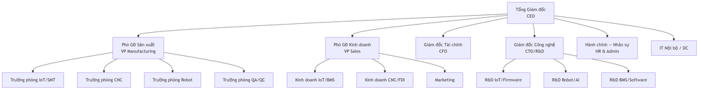

So do 18

## 7.2. Kế hoạch Nhân sự theo Giai đoạn

| Giai đoạn | Phòng ban | Số lượng | Ghi chú |
| --- | --- | --- | --- |
| **Y0–Y1** | Ban Giám đốc + Pháp lý + Thiết kế | 8–10 | Core team |
| **Y1–Y3** | + Giám sát xây dựng + Mua sắm | 10–15 | Thêm 2–5 người |
| **Y3–Y4** | + IoT/SMT team + QA | 30–40 | Tuyển 20–25 kỹ sư + công nhân |
| **Y4–Y5** | + CNC operators + Robot team | 55–70 | Tuyển 25–30 thợ CNC + kỹ sư |
| **Y5–Y6** | + Sales + Marketing + Thêm SX | 70–85 | Mở rộng kinh doanh |
| **Y7–Y10** | + Mở rộng theo doanh thu | 90–110 | Tăng dần |
| **Y10+** | Ổn định | **110–135** | Bao gồm thời vụ |

### Nhân sự theo Bộ phận (Ổn định Y10+)

| Bộ phận | Số lượng | Tỷ lệ |
| --- | --- | --- |
| Sản xuất IoT/SMT | 28–33 | 25% |
| Sản xuất CNC | 20–25 | 19% |
| Sản xuất Robot Assembly | 8–10 | 7% |
| QA/QC | 6–9 | 6% |
| R&D + Thiết kế | 13–16 | 12% |
| Bán hàng + Marketing | 9–11 | 8% |
| IT / DC nội bộ | 3–5 | 3% |
| Hành chính + Kế toán + Nhân sự | 8–10 | 7% |
| Ban Giám đốc + Quản lý | 6–8 | 6% |
| Kho + Logistics | 5–8 | 6% |
| Chuyên gia/Consultant bán thời gian | 2–4 | 2% |
| **Tổng** | **108–139** | **100%** |

### 7.2.1. Chuyên gia Nước ngoài

| Vị trí | Quốc tịch | Số lượng | Thời gian | Mục đích |
| --- | --- | --- | --- | --- |
| CNC Application Engineer | Nhật/Đức | 2 | 2 năm (theo HĐ mua máy) | Đào tạo vận hành DMG MORI 5-trục — điều khoản OEM bắt buộc |
| AI/ML Lead | Hàn Quốc/Mỹ | 1 | Dài hạn | Phát triển AI SLAM, Computer Vision cho AMR |
| Quality Manager (ISO 9001) | Nhật/Đức | 1 | 2 năm | Thiết lập QMS, nâng cấp IATF/AS9100 khi có nhu cầu |
| **Tổng** |  | **4** |  | Phù hợp phạm vi 2 trụ cột (CNC + IoT/BMS) |

## 7.3. Kế hoạch Tuyển dụng và Đào tạo

### 7.3.1. Tuyển dụng theo Nhóm (Y3–Y5 — Giai đoạn Tuyển chính)

| Nhóm | Số lượng | Nguồn tuyển | Mức lương (USD/tháng) |
| --- | --- | --- | --- |
| Kỹ sư CNC (vận hành 5-trục) | 8–10 | Trường CĐ nghề + FDI chuyển việc | 800–1.500 |
| Kỹ sư CNC (CAM Programmer) | 3–4 | ĐH Bách Khoa + Recruitment agency | 1.200–2.000 |
| Kỹ sư IoT (Firmware/HW) | 8–10 | ĐH Bách Khoa, HCMUT, UIT | 1.000–2.000 |
| Kỹ sư Robot (AI/SLAM) | 3–4 | UIT, VGU, Returnee | 1.500–2.500 |
| Kỹ sư phần mềm BMS/SCADA | 4–5 | ĐH CNTT, Recruitment agency | 1.200–2.000 |
| QC Inspector | 3–5 | Trường CĐ + Đào tạo nội bộ | 700–1.200 |
| SMT Operator | 6–8 | CĐ Công nghệ + Training | 600–1.000 |
| Sales Engineer (B2B) | 4–5 | Kinh nghiệm manufacturing B2B | 1.000–2.000 + Commission |
| Hành chính + Kế toán | 4–5 | Đa dạng | 500–1.000 |

### 7.3.2. Chương trình Đào tạo

| Chương trình | Đối tượng | Thời lượng | Đối tác | Chi phí (K USD) |
| --- | --- | --- | --- | --- |
| CNC 5-Axis Operation — **OEM bắt buộc theo hợp đồng mua máy** | Kỹ sư CNC | 3 tháng | DMG MORI Academy (điều khoản trong HĐ mua thiết bị) | 50–80 |
| CMM Programming (PC-DMIS) | QC Inspector | 1 tháng | Hexagon MI | 15–25 |
| Robot AI/SLAM Development | Kỹ sư Robot | 2 tháng | NVIDIA DLI | 15–25 |
| ISO 9001 Internal Auditor | QA team | 1 tuần | TUV/BSI | 5–10 |
| PCCC + ATVSLĐ | Toàn bộ | 2 ngày/năm | Đơn vị được cấp phép | 5 |
| Tiếng Anh kỹ thuật | Toàn bộ kỹ thuật | Ongoing | Trung tâm ngoại ngữ | 10–15 |
| **Tổng ngân sách đào tạo Y3–Y5** |  |  |  | **100–160** |

> Ngân sách đào tạo trung bình ~40–50K USD/năm giai đoạn vận hành ổn định. Tương đương ~400–500 USD/người/năm, đạt chuẩn 40 giờ đào tạo/năm/người [A].

### 7.3.3. Chính sách Nhân sự

| Chính sách | Chi tiết |
| --- | --- |
| **Lương** | Cạnh tranh top 25% thị trường TP.HCM, review hàng năm |
| **Thưởng** | KPI quarterly + Thưởng cuối năm (1–3 tháng lương) |
| **BHXH + BHYT** | Đầy đủ theo luật + Bảo hiểm sức khỏe premium cho nhân sự chủ chốt |
| **ESOP** | 5% vốn điều lệ cho nhân sự chủ chốt (vesting 4 năm, cliff 1 năm) — xem mục 7.5.3 |
| **Đào tạo** | 40 giờ/năm/người tối thiểu |
| **Nghỉ phép** | 15 ngày/năm (cao hơn luật 3 ngày) |
| **Shuttle bus** | Tuyến Quận 1/Bình Thạnh → KCNC |
| **Bữa ăn** | Cơm trưa miễn phí tại canteen |

## 7.4. Chi phí Nhân sự

### 7.4.1. Bảng Chi phí Nhân sự theo Năm

| Năm | Headcount | Lương TB (USD/tháng) | Tổng Lương/Năm (M USD) | BHXH + Phúc lợi (M USD) | **Tổng (M USD)** |
| --- | --- | --- | --- | --- | --- |
| Y3–Y4 | 35 | 900 | 0,38 | 0,12 | **0,50** |
| Y5–Y6 | 70 | 950 | 0,80 | 0,25 | **1,05** |
| Y7–Y10 | 95 | 1.000 | 1,14 | 0,36 | **1,50** |
| Y10+ (ổn định) | 110 | 1.050 | 1,39 | 0,41 | **1,80** |

## 7.5. Phát triển Tổ chức và Quản lý

### 7.5.1. Mô hình Phát triển 3 Giai đoạn

| Giai đoạn | Cơ cấu | Số cấp quản lý | Quyết định | KPI quản lý |
| --- | --- | --- | --- | --- |
| **Startup (Y0–Y3)** | Phẳng (flat) | 2–3 | Tập trung CEO | Revenue, First customer |
| **Growth (Y3–Y7)** | Ma trận | 3–4 | Phân quyền Trưởng phòng | Profit by BU, OEE |
| **Mature (Y7+)** | 2 BU tự chủ P&L | 4 | BU autonomy | EBITDA margin, ROE |

### 7.5.2. Đội ngũ Quản lý Chủ chốt

| Vị trí | Thời điểm tuyển | Profile yêu cầu | Lương (K USD/năm) |
| --- | --- | --- | --- |
| **CEO** | Đã có | Founder, 15+ năm kinh nghiệm CNC/Tech | 96–144 |
| **CTO** | Y1 Q1 | MS/PhD kỹ thuật, 10+ năm IoT/AI | 72–108 |
| **CFO** | Y1 Q1 | CPA/CFA, 10+ năm, kinh nghiệm FDI | 60–96 |
| **Phó GĐ Sản xuất** | Y2 Q1 | 10+ năm manufacturing, Lean/Six Sigma | 60–84 |
| **Phó GĐ Kinh doanh** | Y3 Q1 | 8+ năm B2B tech sales ASEAN | 60–84 + Commission |
| **Trưởng phòng CNC** | Y3 Q1 | 10+ năm CNC 5-trục, ISO 9001 | 48–72 |
| **Trưởng phòng IoT** | Y3 Q1 | MS Embedded + 8 năm IoT/Robotics | 48–72 |
| **Trưởng phòng QA/QC** | Y3 Q2 | CQE, kinh nghiệm ISO 9001 → IATF | 48–60 |

### 7.5.3. Chương trình ESOP

| Thông số | Giá trị |
| --- | --- |
| Tổng Pool ESOP | 5% vốn điều lệ |
| Vesting Schedule | 4 năm, cliff 1 năm (25% vest sau năm 1, 6,25%/quý sau đó) |
| Đối tượng | C-Level (2,0%), Trưởng phòng (1,5%), Key Engineer (1,0%), Outstanding (0,5%) |
| Strike Price | Mệnh giá tại thời điểm cấp |
| Lock-up | 6 tháng sau mỗi đợt vest |

## 7.6. Chiến lược Giữ chân Nhân tài

### 7.6.1. Phân tích Rủi ro Mất Nhân sự Chủ chốt

| Vị trí | Turnover Risk | Tác động | Thời gian thay thế | Cost Replacement |
| --- | --- | --- | --- | --- |
| CNC 5-Axis Operator (Lv3) | Cao | Rất cao | 6–12 tháng | 15–25 K USD |
| AI/ML Lead (Robot SLAM) | Rất cao | Cao | 6–9 tháng | 20–40 K USD |
| CAM Programmer Sr | Cao | Rất cao | 9–15 tháng | 20–30 K USD |
| Quality Manager (ISO 9001) | Trung bình-Cao | Rất cao | 12–18 tháng | 25–40 K USD |
| Sales Director (FDI B2B) | Trung bình | Cao | 3–6 tháng | 15–20 K USD |

> Turnover rate mục tiêu: < 10%/năm toàn công ty, < 5% cho Key Position. Chuẩn ngành FDI tại KCNC TP.HCM: 12–18% turnover [A].

### 7.6.2. Chương trình Giữ chân

| Chương trình | Đối tượng | Chi tiết | Budget/năm (K USD) |
| --- | --- | --- | --- |
| ESOP 5% | C-Level + Trưởng phòng + Key | Vesting 4 năm | Equity |
| Retention Bonus | Top 20% performance | 1–3 tháng lương thêm | 80 |
| **Cam kết phục vụ 1 năm** | Nhân sự được đào tạo OEM/quốc tế | Ký phụ lục HĐLĐ; bồi hoàn chi phí đào tạo nếu nghỉ trước 1 năm sau khi hoàn thành khóa | 0 (bồi hoàn nếu vi phạm) |
| Career Path (Dual Track) | Tất cả | Management vs Technical Expert | — |
| Đào tạo quốc tế | Key Engineer | DMG MORI Japan, Hexagon | 50 |
| Cải thiện môi trường | Tất cả | Canteen + Gym + Recreation + Shuttle | 30 |
| Health + Wellness | Tất cả | Premium health insurance + Annual checkup | 25 |
| Recognition Program | Tất cả | Employee of Month/Quarter + Small rewards | 10 |

### 7.6.3. Career Path — Dual Track

| Level | Technical Track | Management Track | Lương Range (K USD/năm) |
| --- | --- | --- | --- |
| L1 | Engineer | — | 10–18 |
| L2 | Engineer II | — | 14–24 |
| L3 | Senior Engineer | Team Lead | 20–36 |
| L4 | Technical Lead | Manager/Trưởng phòng | 30–48 |
| L5 | Principal Engineer | Phó GĐ | 48–84 |

> **Dual Track** đảm bảo kỹ sư giỏi không bị ép làm quản lý — giảm turnover kỹ thuật và giữ chuyên gia CNC/AI/IoT lâu dài [A].

## 7.7. Quản lý Tri thức và Kế thừa

### 7.7.1. Knowledge Management System

| Tầng | Nội dung | Công cụ | Trách nhiệm |
| --- | --- | --- | --- |
| KM-1: SOP & Work Instruction | Quy trình vận hành CNC, SMT, QC, xử lý lỗi | Wiki nội bộ (Confluence/Notion) | QA Manager |
| KM-2: Training Material | Video hướng dẫn, bản vẽ mẫu, G-code library | LMS nội bộ | HR + CTO |
| KM-3: Design IP Repository | Firmware source, PCB schematics, CAD models | Git + PLM (Windchill/Teamcenter) | CTO |
| KM-4: Lesson Learned | Post-mortem dự án, root cause CNC scrap, field failure | Jira Knowledge Base | Trưởng phòng chức năng |
| KM-5: Customer Knowledge | Profile KH FDI, buying criteria, complaint history | CRM (HubSpot/Odoo) | VP Sales |

> Mục tiêu: **Bus Factor ≥ 2** cho mọi vị trí chủ chốt — nghĩa là luôn có ít nhất 2 người biết làm mỗi việc quan trọng. Số hóa 100% SOP trước khi vận hành (Y3) [A].

### 7.7.2. Succession Planning — Vị trí Chủ chốt

| Vị trí | Người giữ (dự kiến) | Backup-1 | Backup-2 | Thời gian chuẩn bị |
| --- | --- | --- | --- | --- |
| CEO | Founder | CTO hoặc VP Sales | Board member | — |
| CTO | Tuyển Y1 | R&D Lead IoT | R&D Lead Robot | 2 năm |
| Trưởng phòng CNC | Tuyển Y3 | Senior CAM Programmer | CNC Application Engineer (JP) | 18 tháng |
| Quality Manager | Tuyển Y3 | QC Lead | External auditor consultant | 12 tháng |
| AI/ML Lead | Tuyển Y3 | Senior Robot Engineer | Returnee/Partner | 18 tháng |

> Succession plan review: **hàng năm** bởi CEO + HR Director. Cập nhật khi có thay đổi nhân sự hoặc tổ chức.

## 7.8. Tuân thủ Pháp luật Lao động

### 7.8.1. Checklist Tuân thủ

| TT | Yêu cầu pháp lý | Văn bản | Biện pháp Mekong | Timeline |
| --- | --- | --- | --- | --- |
| 1 | Đăng ký nội quy lao động | Bộ Luật LĐ 2019, Điều 119 | Soạn và đăng ký tại Sở LĐ-TBXH | Trước tuyển dụng (Y2) |
| 2 | Thỏa ước lao động tập thể | Bộ Luật LĐ 2019, Điều 75 | Đàm phán với đại diện NLĐ | Y3-Y4 |
| 3 | BHXH, BHYT, BHTN | Luật BHXH 2014, Luật BHYT 2008 (sửa đổi) | Đóng đầy đủ: 23,5% phía công ty | Từ ngày ký HĐLĐ |
| 4 | Huấn luyện ATVSLĐ 6 nhóm | NĐ 44/2016/NĐ-CP | Thuê đơn vị được cấp phép | Hàng năm + mới vào |
| 5 | Khai báo tai nạn lao động | Bộ Luật LĐ 2019, Điều 142 | Quy trình báo cáo 24h | Khi xảy ra sự cố |
| 6 | Bảo vệ lao động nữ | Bộ Luật LĐ 2019, Chương X | Phòng vắt/trữ sữa, không ca đêm khi mang thai | Từ khi có lao động nữ |
| 7 | Lao động nước ngoài (4 chuyên gia) | NĐ 152/2020/NĐ-CP | Xin giấy phép lao động, miễn nếu < 30 ngày | Trước khi chuyên gia nhận việc |
| 8 | Thang bảng lương | NĐ 38/2022/NĐ-CP | Xây dựng và đăng ký | Y2 (trước tuyển dụng đại trà) |

### 7.8.2. Ngân sách Tuân thủ Lao động

| Hạng mục | Chi phí/năm (K USD) |
| --- | --- |
| BHXH + BHYT + BHTN (phần công ty ~23,5%) | 280–350 |
| Huấn luyện ATVSLĐ | 10 |
| Khám sức khỏe định kỳ | 8 |
| Bảo hiểm tai nạn 24/7 bổ sung | 12 |
| Tư vấn pháp lý lao động | 5 |
| **Tổng** | **~315–385** |

> Chiếm ~17-21% tổng chi phí nhân sự 1,80M USD/năm. Phù hợp chuẩn ngành ngành sản xuất CNC tại Việt Nam [B — Navigos Salary Survey 2024].

## 7.7. Kế hoạch Kế nhiệm

### 7.7.1. Ma trận Kế nhiệm Vị trí Chủ chốt

[output not shown]

### 7.7.2. Cơ chế Chuyển giao Tri thức

| Hoạt động | Tần suất | Trách nhiệm | Deliverable |
| --- | --- | --- | --- |
| Tài liệu hóa quy trình (SOP) | Liên tục | Mỗi bộ phận | SOP library trên Wiki nội bộ |
| Cross-training (2 người/vị trí key) | Hàng quý | HR + Bộ phận | Training log, Skill matrix |
| Mentoring program | 1:1 hàng tháng | Senior → Junior | Mentoring record |
| Technical sharing sessions | 2 tuần/lần | Luân phiên | Slide deck + Recording |
| Exit interview + Knowledge capture | Khi nghỉ việc | HR | Knowledge transfer document |
| CNC Process Notes | Mỗi job mới | CAM Programmer | Job folder (CAM file + Tool list + QC report) |

### 7.7.3. Bộ KPI Nhân sự và Năng lực Tổ chức

| KPI | Mục tiêu Y4-Y6 | Mục tiêu Y10+ | Ghi chú |
| --- | --- | --- | --- |
| Time-to-fill vị trí kỹ thuật | < 60 ngày | < 45 ngày | CNC / IoT / QA |
| Tỷ lệ nghỉ việc toàn công ty | < 12% | < 10% | Chuẩn ngành FDI KCNC 12-18% |
| Tỷ lệ nghỉ việc vị trí key | < 8% | < 5% | Theo danh sách critical role |
| Giờ đào tạo / người / năm | ≥ 32 giờ | ≥ 40 giờ | Bao gồm kỹ thuật + an toàn |
| Tỷ lệ vị trí key có người kế nhiệm sẵn sàng | ≥ 50% | ≥ 80% | Succession readiness |
| Tỷ lệ nhân sự đa kỹ năng (cross-trained) | ≥ 25% | ≥ 40% | Đặc biệt ở CNC / QA / SMT |
| Năng suất doanh thu / nhân sự | > 45K USD | > 90K USD | Theo ramp-up và ổn định |

> Bộ KPI này giúp gắn quản trị nhân sự với hiệu quả vận hành thực tế: tuyển đúng, giữ đúng người, đào tạo đúng kỹ năng và luôn có phương án kế nhiệm cho các vị trí trọng yếu, trên cơ sở giả định vận hành và chỉ tiêu quy mô đã nêu trong đề án.

## 7.8. Tiểu kết Phần VII

| Chỉ tiêu | Giá trị |
| --- | --- |
| Tổng nhân sự ổn định (Y10+) | 110–135 người [C] |
| Tổng quỹ lương + phúc lợi (Y10+) | ~1,80M USD/năm [A] |
| Turnover mục tiêu | < 10%/năm, Key < 5% [A] |
| Chuyên gia nước ngoài | 4 người (2 CNC theo HĐ OEM + 1 AI + 1 QM) |
| Cam kết phục vụ sau đào tạo OEM | 1 năm (phụ lục HĐLĐ) [A] |
| Đào tạo OEM CNC | Bắt buộc trong điều khoản hợp đồng mua thiết bị [A] |
| ESOP pool | 5% vốn điều lệ |
| Ngân sách đào tạo /năm | ~40–50K USD [A] |
| Career path | Dual Track (Technical + Management) |

> **Kết luận:** Kế hoạch nhân sự dự án tối ưu cho quy mô 22,00M USD với 100–130 nhân sự ổn định, tập trung vào 2 trụ cột sản xuất. Chi phí nhân sự chiếm ~21% OPEX — hợp lý cho ngành sản xuất công nghệ cao. Chương trình giữ chân (ESOP + Dual Track + Retention Bonus) giúp giảm turnover dưới chuẩn ngành FDI tại KCNC [A].

# PHẦN VIII: KẾ HOẠCH TRIỂN KHAI

## 8.1. Phân kỳ Đầu tư 4 Giai đoạn

[output not shown]

### 8.1.1. Chi tiết Hoạt động theo Phase

**Phase 0 — Chuẩn bị (12 tháng)**

| TT | Hoạt động | Thời gian | Người phụ trách | Đầu ra |
| --- | --- | --- | --- | --- |
| 1 | Nộp Mẫu 1.4 KCNC | Q2/2026 | CEO + Ban Pháp lý | Mẫu 1.4 hoàn chỉnh |
| 2 | Lập Báo cáo ĐTM | Q2–Q3/2026 | Tư vấn môi trường | Quyết định phê duyệt ĐTM |
| 3 | Thiết kế kiến trúc + M&E | Q3–Q4/2026 | Nhà thầu thiết kế | Hồ sơ thiết kế kỹ thuật |
| 4 | Xin Giấy phép xây dựng | Q4/2026 | Ban Pháp lý | GPXD |
| 5 | San lấp mặt bằng | Q1/2027 | Nhà thầu | Mặt bằng sẵn sàng |
| 6 | Tuyển dụng nhân sự cốt lõi | Q3/2026–Q1/2027 | HR | 8-10 nhân sự core team |

**Phase 1 — Xây dựng (24 tháng)**

| TT | Hoạt động | Thời gian | Người phụ trách | Đầu ra |
| --- | --- | --- | --- | --- |
| 1 | Xây dựng Tòa nhà VP 3 tầng (21×48m) | Q2/2027–Q2/2028 | Nhà thầu xây dựng | VP hoàn công |
| 2 | Xây dựng Nhà xưởng SX (48×70m, PEB) | Q2/2027–Q4/2028 | Nhà thầu xây dựng | Xưởng hoàn công |
| 3 | Xây dựng Khu Utility (5×56m) | Q3/2027–Q1/2028 | Nhà thầu xây dựng | Utility hoàn công |
| 4 | Lắp đặt M&E tổng thể | Q1/2028–Q1/2029 | Nhà thầu M&E | Hệ thống điện/nước/HVAC |
| 5 | Lắp đặt PCCC toàn khu | Q3/2028–Q1/2029 | Nhà thầu PCCC | Nghiệm thu PCCC |
| 6 | Lắp đặt Solar 200 kWp | Q4/2028–Q1/2029 | Nhà thầu năng lượng | Solar vận hành |
| 7 | Đường nội bộ, sân bãi, cảnh quan | Q1–Q4/2028 | Nhà thầu | Hạ tầng ngoài hoàn chỉnh |
| 8 | Xin EDGE Certification | Q4/2028–Q1/2029 | Tư vấn ESG | Chứng chỉ EDGE |

**Phase 2 — Lắp đặt Thiết bị (24 tháng)**

[output not shown]

**Phase 3 — Vận hành và Mở rộng (24 tháng)**

| TT | Hoạt động | Thời gian | Người phụ trách | Đầu ra |
| --- | --- | --- | --- | --- |
| 1 | Sản xuất loạt IoT Gateway đầu tiên | Q2/2031 | BU1 Director | Sản phẩm thương mại |
| 2 | Nhận đơn hàng CNC FDI đầu tiên | Q3/2031 | BU2 Director | Hợp đồng gia công |
| 3 | Robot AMR prototype hoàn thiện | Q4/2031 | R&D Robot | Robot v1 |
| 4 | Tuyển dụng nhân sự mở rộng (lên 65–80) | Q2–Q4/2031 | HR | Đủ nhân sự |
| 5 | Giải ngân vay 4,00M (nếu cần) | Q1/2032 | CFO | Bổ sung vốn lưu động |
| 6 | Đạt doanh thu 8–9M USD/năm | Q4/2032 | CEO | Mốc tiến độ tài chính |

## 8.2. Các mốc Quan trọng (Các mốc tiến độ)

[output not shown]

### 8.2.1. Gantt Chart Tổng quát

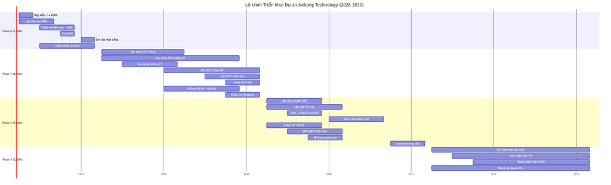

So do 19

## 8.3. Phân tích Rủi ro và Biện pháp Giảm thiểu

### 8.3.1. Ma trận Rủi ro Tổng hợp

[output not shown]

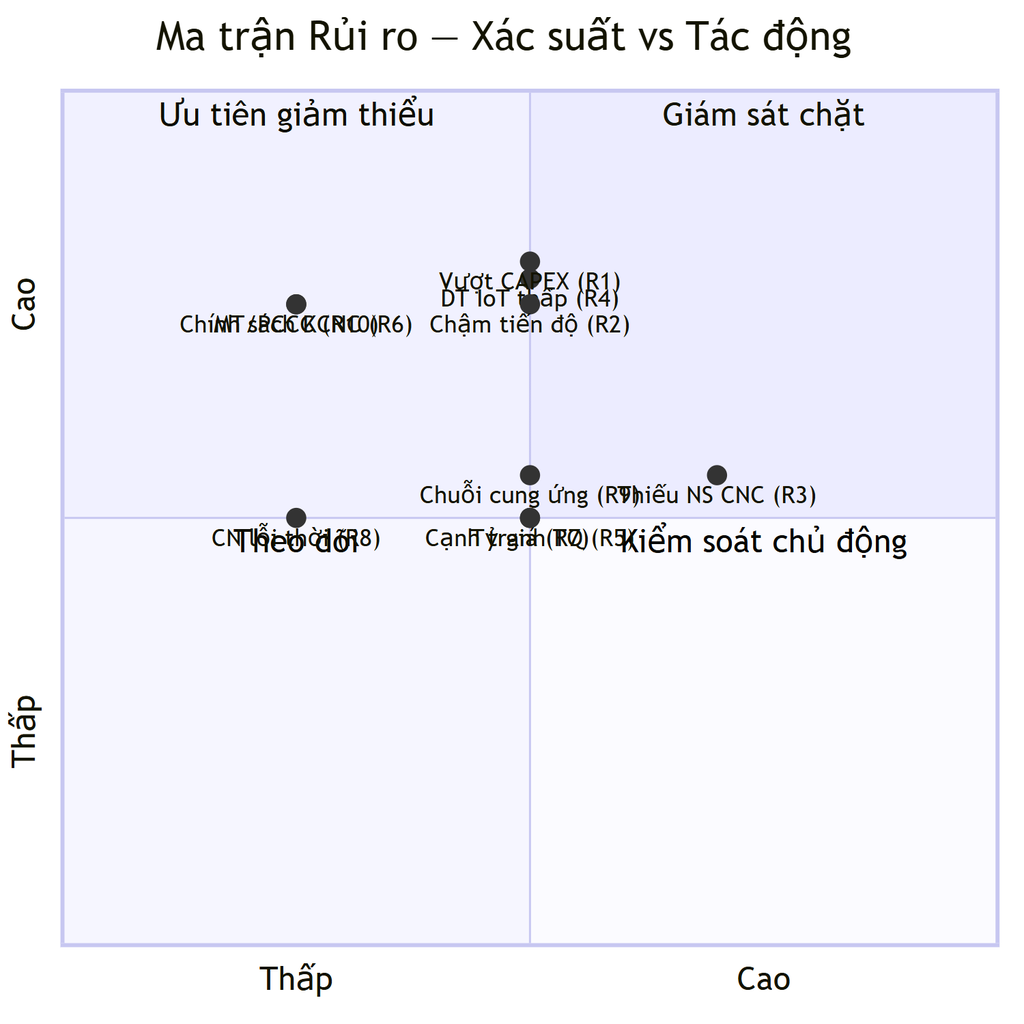

So do 20

### 8.3.2. Kế hoạch Ứng phó Chi tiết

| Ngưỡng kích hoạt | Hành động | Thời gian phản hồi | Người quyết định |
| --- | --- | --- | --- |
| CAPEX Phase 1 vượt 10% | Rà soát scope Phase 2, đàm phán nhà thầu | 2 tuần | CEO + CFO |
| Chậm tiến độ > 3 tháng | Tăng cường nhà thầu, làm thêm ca | 1 tuần | PM |
| Chuỗi đơn hàng CNC < 300K USD/năm (sau Y5) | Chuyển máy sang thuê ngoài giờ, tăng marketing FDI | 1 tháng | BU2 Director |
| Doanh thu Year 5 < 1,75M (< 70% mục tiêu) | Rà soát định giá, mở rộng OEM, cắt OPEX 15% | 1 tháng | Ban Giám đốc |
| DSCR < 2,0× trong 2 quý liên tiếp | Tạm dừng mở rộng Phase 3, cơ cấu nợ | 2 tuần | CFO |
| Sự cố môi trường/PCCC | Dừng hoạt động liên quan, báo cáo BQL KCNC | Ngay lập tức | CEO + HSE |

## 8.4. Quản lý Dự án (PMO)

### 8.4.1. Tổ chức Quản lý Dự án

| Vai trò | Người đảm nhiệm | Trách nhiệm |
| --- | --- | --- |
| Project Sponsor | CEO / Hội đồng Sáng lập | Phê duyệt ngân sách, quyết định chiến lược |
| Project Manager (PM) | Thuê chuyên gia PMO | Điều phối thi công, theo dõi mốc tiến độ, báo cáo |
| Technical Director | CTO | Giám sát thiết kế kỹ thuật, M&E, commissioning |
| Financial Controller | CFO | Theo dõi ngân sách, giải ngân, cost control |
| Quality Manager | QA Director | Nghiệm thu chất lượng xây dựng và lắp đặt |
| HSE Officer | Thuê chuyên gia | An toàn lao động, môi trường thi công |

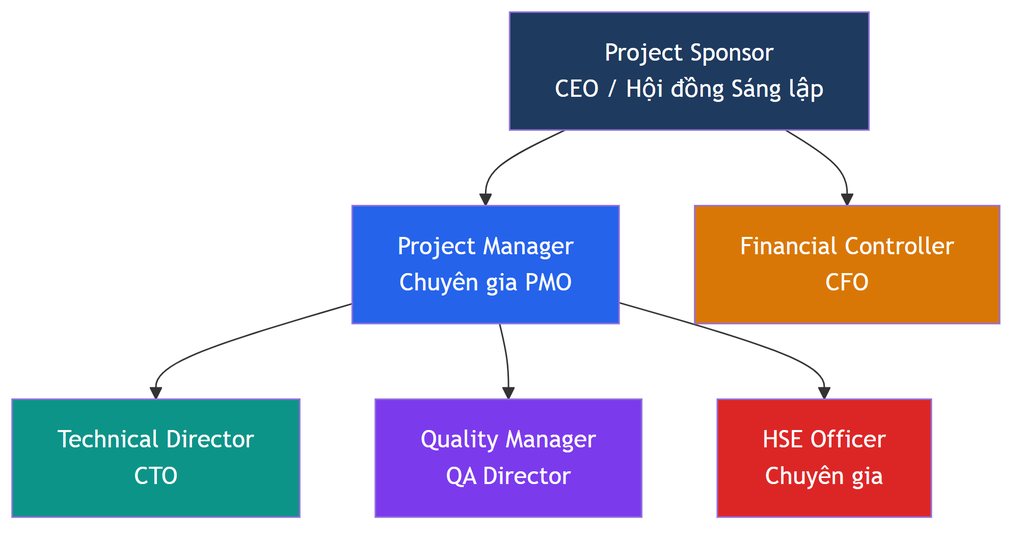

So do 21

### 8.4.2. Cơ chế Báo cáo

| Loại báo cáo | Tần suất | Nội dung | Người nhận |
| --- | --- | --- | --- |
| Báo cáo tiến độ tuần | Hàng tuần | % hoàn thành, vấn đề, rủi ro | PM → CEO |
| Báo cáo tài chính tháng | Hàng tháng | Chi tiêu vs ngân sách, dòng tiền | CFO → CEO |
| Báo cáo mốc tiến độ | Tại mỗi mốc tiến độ | Đạt/Không đạt, hành động tiếp | PM → Hội đồng |
| Báo cáo BQL KCNC | Hàng quý | Tiến độ tổng thể, tuân thủ cam kết | CEO → BQL KCNC |

### 8.4.3. Phần mềm Quản lý

| Giai đoạn | Công cụ | Mục đích |
| --- | --- | --- |
| Xây dựng (Phase 0-1) | MS Project / Primavera | Gantt chart, Critical Path, Resource leveling |
| Lắp đặt (Phase 2) | Jira / Asana | Task tracking, commissioning checklist |
| Vận hành (Phase 3+) | ERP (SAP B1 / Odoo) | Quản lý SX, tài chính, kho, CRM |

### 8.4.4. Chiến lược Procurement và Decision Gate

| Gói thầu / hạng mục | Hình thức mua sắm | Tiêu chí chọn | Decision Gate |
| --- | --- | --- | --- |
| Xây dựng 3 công trình | Đấu thầu cạnh tranh / EPC tách phần | Giá, năng lực, tiến độ, an toàn | Không ký nếu chênh > ngân sách 7,5% |
| CNC / EDM / Grinder | Đàm phán trực tiếp + so sánh 2-3 OEM | TCO, service, thời gian dẫn, đào tạo | Chỉ chốt khi có FAT plan + spare list |
| SMT / QA Lab | RFQ nhiều nhà cung cấp | Yield, hỗ trợ local, compatibility | Pilot demo trước PO |
| ERP / MES / BMS software | PoC + phased rollout | Tính mở, tích hợp, chi phí license | Gate theo module |
| Solar / M&E / Utility | Turnkey package | Hiệu suất, warranty, O&M | Chỉ nghiệm thu khi có performance test |

| Gate | Điều kiện qua cổng | Người phê duyệt |
| --- | --- | --- |
| Gate A — Pháp lý | IRC / đất / ĐTM / GPXD sẵn sàng | CEO + Pháp lý |
| Gate B — Xây dựng | Thiết kế khóa, BOQ, ngân sách được chốt | CEO + PM + CFO |
| Gate C — Thiết bị | Site ready, utility ready, FAT approved | CTO + PM |
| Gate D — Vận hành | SAT pass, training hoàn tất, SOP sẵn sàng | CEO + BU Heads |

### 8.4.5. Change Management Protocol

| Loại thay đổi | Ví dụ | Quyền phê duyệt | Quy trình |
| --- | --- | --- | --- |
| **Minor** (chi phí < 50K, tiến độ < 2 tuần) | Thay NCC phụ kiện, điều chỉnh BOM | PM + Technical Director | Change Request → Review 48h → Approve/Reject |
| **Major** (chi phí 50K–500K, tiến độ 2-8 tuần) | Thay đổi thiết kế M&E, thêm thiết bị CNC | CEO + CFO + PM | CR → Impact Analysis → Board Review 1 tuần → Approve |
| **Critical** (chi phí > 500K hoặc scope change) | Thay đổi layout nhà xưởng, giảm/tăng Phase | Hội đồng Sáng lập | CR → Full Impact + Risk → Board Meeting → Vote |

| Bước | Hành động | Responsibility | Timeline |
| --- | --- | --- | --- |
| 1 | Initiate Change Request (CR) | Bất kỳ thành viên | Ngay khi phát hiện |
| 2 | Impact Assessment (cost, schedule, quality, risk) | PM + Affected Team | 2–5 ngày |
| 3 | Review & Decision | Theo cấp phê duyệt | 2–7 ngày |
| 4 | Implement Change | Responsible Team | Theo plan |
| 5 | Verify & Close | QA + PM | 1–3 ngày |

> Tổng số CR dự kiến: 15–30 trong Phase 0–2 (theo chuẩn ngành dự án xây dựng nhà máy quy mô tương đương). Mục tiêu: ≤ 5 Major, 0 Critical [A].

### 8.4.6. Các bên liên quan Communication Plan

| Các bên liên quan | Nhu cầu thông tin | Kênh | Tần suất | Trách nhiệm |
| --- | --- | --- | --- | --- |
| BQL KCNC TP.HCM | Tiến độ tổng thể, tuân thủ cam kết | Báo cáo + Họp trực tiếp | Hàng quý | CEO |
| Sở TN&MT | ĐTM, giám sát môi trường | Báo cáo chính thức | Hàng quý | HSE Officer |
| PC07 (PCCC) | Tiến độ thi công PCCC, nghiệm thu | Báo cáo + Kiểm tra | Theo mốc tiến độ | PM + PCCC consultant |
| Nhà thầu xây dựng | Bản vẽ, tiến độ, thanh toán | Họp site hàng tuần | Hàng tuần | PM |
| NCC thiết bị (DMG, Haas) | Delivery schedule, FAT, SAT | Email + Họp online | Hàng tháng | Procurement + CTO |
| Nhân viên / Công đoàn | Lịch tuyển dụng, quyền lợi, đào tạo | Email nội bộ + Town Hall | Hàng tháng | HR Director |
| Ngân hàng (khi vay Y7) | Tiến độ, doanh thu, DSCR | Báo cáo tài chính | Hàng quý | CFO |
| Cộng đồng lân cận | Ồn, bụi trong thi công | Thông báo + Hotline | Khi cần | HSE Officer |

### 8.4.7. Permit-to-Operate Checklist

Trước khi vận hành chính thức (Phase 3, Q2/2031), tất cả hạng mục sau PHẢI hoàn tất:

| TT | Hạng mục | Cơ quan xác nhận | Bằng chứng | Trạng thái |
| --- | --- | --- | --- | --- |
| 1 | Nghiệm thu hoàn công 3 công trình | BQL KCNC + Sở XD | Biên bản nghiệm thu | — |
| 2 | Nghiệm thu PCCC công trình | PC07 Công an TP.HCM | QĐ nghiệm thu PCCC | — |
| 3 | Giấy phép xả thải | Sở TN&MT | GP xả thải | — |
| 4 | Giấy phép hoạt động điện | Sở Công thương | GP điện | — |
| 5 | Đăng ký máy CNC (thiết bị áp lực) | Sở LĐ-TBXH | Sổ đăng ký | — |
| 6 | ISO 9001:2015 certified | TUV/BSI | Chứng chỉ ISO | — |
| 7 | ERP/MES go-live | IT Team | User Acceptance Test pass | — |
| 8 | BMS toàn nhà máy hoạt động | R&D IoT | Commissioning report | — |
| 9 | Đào tạo ATVSLĐ hoàn tất | Đơn vị được cấp phép | Chứng chỉ 100% nhân sự | — |
| 10 | Insurance policies active | Broker bảo hiểm | Chứng thư bảo hiểm | — |

> **Gate D (Permit-to-Operate):** Chỉ khi 10/10 hạng mục trên đạt “Hoàn tất” mới được phê duyệt vận hành thương mại. CEO ký quyết định vận hành sau khi QA Director xác nhận toàn bộ checklist.

### 8.4.5. KPI Kiểm soát Triển khai

| KPI | Ngưỡng mục tiêu | Chủ sở hữu |
| --- | --- | --- |
| SPI (Schedule Performance Index) | ≥ 0,95 | PM |
| CPI (Cost Performance Index) | ≥ 0,95 | CFO + PM |
| % mốc tiến độ đúng hạn | ≥ 90% | PMO |
| % commissioning checklist hoàn tất | 100% trước go-live | CTO |
| % hồ sơ as-built / O&M manual bàn giao | 100% | Nhà thầu + PM |

> Bộ KPI này giúp Phase 0-3 được điều hành như một chương trình đầu tư thật sự, không chỉ là danh sách công việc nối tiếp nhau. Nếu SPI hoặc CPI xuống dưới 0,95 trong 2 kỳ liên tiếp, PMO phải trình phương án hiệu chỉnh trong vòng 10 ngày làm việc [A].

### 8.4.6. Các bên liên quan Plan và Go-Live Readiness

| Nhóm các bên liên quan | Nhu cầu thông tin | Tần suất | Chủ trì |
| --- | --- | --- | --- |
| BQL KCNC | Pháp lý, tiến độ, cam kết môi trường | Hàng quý | CEO + Pháp lý |
| Ngân hàng / đối tác vốn | CAPEX, DSCR, mốc tiến độ doanh thu | Hàng quý / khi giải ngân | CFO |
| Nhà thầu / OEM | Scope, schedule, FAT/SAT, thay đổi | Hàng tuần | PM |
| BU vận hành | Site readiness, SOP, training, spare-part | Hàng tuần giai đoạn go-live | CTO + PM |

| Tiêu chí go-live | Mục tiêu pass |
| --- | --- |
| Pháp lý vận hành sẵn sàng | 100% |
| Utility available theo thiết kế | 100% |
| FAT/SAT sign-off | 100% |
| SOP và đào tạo vận hành hoàn tất | ≥ 95% |
| Spare-part critical đã nhập kho | ≥ 90% danh mục |

> Go-live chỉ được phê duyệt khi cả 5 nhóm điều kiện trên đạt ngưỡng. Cách tiếp cận này giúp tránh tình trạng “đã lắp xong nhưng chưa vận hành được” — một rủi ro rất thường gặp ở các dự án công nghiệp có nhiều interface kỹ thuật [B].

### 8.4.7. Permit-to-Operate Checklist

| Nhóm kiểm tra | Điều kiện tối thiểu trước vận hành |
| --- | --- |
| Pháp lý | Hồ sơ môi trường, PCCC, điện lực, ATLĐ đã sẵn sàng theo giai đoạn |
| Kỹ thuật | Tài sản critical đã test pass và có hồ sơ FAT/SAT |
| Vận hành | SOP, WI, spare list, vendor contact list đầy đủ |
| Nhân sự | Ca trưởng, operator, QA, utility team đã đào tạo |
| Thương mại | Có chuỗi đơn hàng/LOI đủ để hấp thụ công suất khởi động |

> Checklist này là “cửa cuối” trước khi chuyển từ trạng thái dự án sang trạng thái nhà máy vận hành. Nếu một trong 5 nhóm chưa đạt, PMO không được đề xuất go-live chính thức [A].

## 8.5. Tiểu kết Phần VIII

> **Tổng kết:** Dự án triển khai qua 4 Phase trong 7 năm (Q2/2026 – Q1/2033), CAPEX 22,00M USD phân bổ hợp lý theo từng giai đoạn. 8 mốc tiến độ chính đảm bảo kiểm soát tiến độ. 10 rủi ro đã được nhận diện với biện pháp giảm thiểu cụ thể. Cơ chế PMO chuyên nghiệp với báo cáo đa tầng đảm bảo minh bạch và trách nhiệm [C].

# PHẦN IX: KẾT LUẬN VÀ KIẾN NGHỊ

## 9.1. Tổng kết Giá trị Dự án

### 9.1.1. Bảng Tổng hợp Chỉ số Chính

| Chỉ số | Giá trị | Phân loại |
| --- | --- | --- |
| Tổng vốn đầu tư | 22,00M USD [C] | Tài chính |
| Vốn CSH / Tổng đầu tư | 18,00M (81,8%) [C] | Tài chính |
| Vốn vay / Tổng đầu tư | 4,00M (18,2%) [C] | Tài chính |
| Doanh thu ổn định (Y12+) | 12,00M USD/năm [C] | Kinh doanh |
| Doanh thu 15Y tích lũy | ~140M USD [C] | Kinh doanh |
| NPV (50Y, WACC 12%) | 1,50M USD [C] | Đầu tư |
| IRR | 13,0% [C] | Đầu tư |
| WACC | 12,0% [C] | Đầu tư |
| DSCR trung bình (Y7-Y16) | ≥ 1,50× [C] | Tài chính |
| EBITDA margin (ổn định) | ~30% [C] | Kinh doanh |
| Việc làm tạo ra | 100–130 vị trí (ổn định) | Xã hội |
| Sản phẩm công nghệ cao | 14 danh mục thuộc QĐ 38/2020 | Pháp lý |
| VA/Revenue | ≥ 42% | Cam kết |
| R&D/Revenue | ≥ 8% (cam kết tối thiểu 5%) | Cam kết |
| Giá trị Chiến lược (SV) | 7,00M USD | Đầu tư |

### 9.1.2. Hai Trụ cột Sản xuất

Dự án Mekong Technology phương án 22,00M USD [C] là một **dự án sản xuất công nghệ cao** thực sự, tập trung vào 2 trụ cột chính:

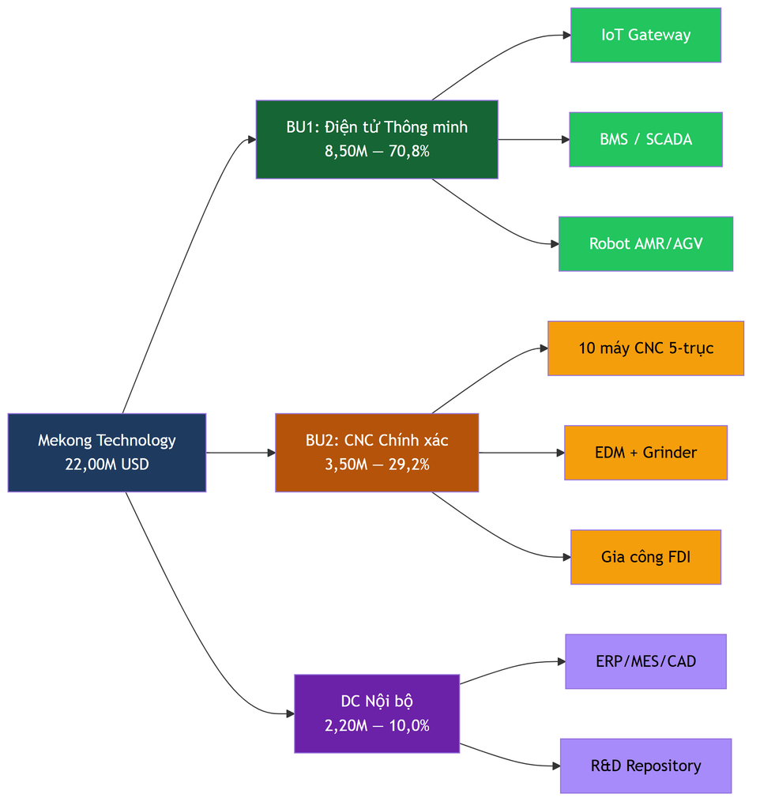

So do 22

**Trụ cột 1 — Sản phẩm Điện tử Thông minh (BU1: 8,50M, chiếm 70,8% doanh thu)** [C]

- IoT Gateway, BMS/SCADA, Robot AMR/AGV — phục vụ chuyển đổi số doanh nghiệp Việt Nam và FDI.
- Dây chuyền SMT hiện đại, phòng R&D IoT, prototyping lab.
- Thị trường mục tiêu: nhà máy sản xuất, tòa nhà thương mại, kho logistics, nông nghiệp công nghệ cao.
- Lợi thế cạnh tranh: thiết kế firmware nội bộ, tùy biến nhanh, hỗ trợ kỹ thuật 24/7 tại Việt Nam.

**Trụ cột 2 — Chế tạo Cơ khí Chính xác (BU2: 3,50M, chiếm 29,2% doanh thu)** [C]

### 9.1.3. Hạ tầng Số Nội bộ

- ERP/MES/CAD-CAM cho quản lý sản xuất.
- Lưu trữ dữ liệu R&D, firmware repository, CI/CD chuỗi đơn hàng.
- BMS/SCADA monitoring cho toàn nhà máy.
- Không kinh doanh dịch vụ DC thương mại, không cung cấp GPU-aaS, colocation, hay dịch vụ viễn thông.

### 9.1.4. Đóng góp cho Hệ sinh thái KCNC TP.HCM

| Lĩnh vực đóng góp | Nội dung cụ thể |
| --- | --- |
| Chuỗi cung ứng bán dẫn | Gia công CNC linh kiện cho Intel, Samsung tại chỗ — giảm phụ thuộc nhập khẩu |
| Chuyển đổi số | Cung cấp IoT/BMS/SCADA Made-in-SHTP cho doanh nghiệp nội địa |
| Đào tạo nhân lực | 100–130 kỹ sư/công nhân CNC + IoT, hợp tác Đại học SHTP |
| R&D và IP | ≥ 8% doanh thu cho R&D, tạo sản phẩm IP nội địa (firmware, thuật toán) |
| Xuất khẩu | Robot AMR/AGV qua ASEAN, linh kiện CNC cho chuỗi cung ứng toàn cầu |
| Green Manufacturing | Solar 200 kWp [C], EDGE Certification, Net Zero lộ trình 2045 |

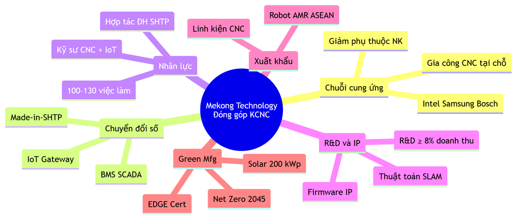

So do 23

## 9.2. Cam kết của Nhà đầu tư

### 9.2.1. Bảng Cam kết Chính

[output not shown]

### 9.2.2. Cam kết Bổ sung

- Ưu tiên tuyển dụng nhân sự **tốt nghiệp các trường đại học và cao đẳng tại TP.HCM** (Bách Khoa, KHTN, Sư phạm Kỹ thuật, Cao thắng).
- Hợp tác với **Trung tâm Đào tạo KCNC** (SHTP Training Center) để đào tạo kỹ năng CNC, IoT cho sinh viên và lao động địa phương.
- Tham gia các **chương trình xúc tiến đầu tư và thương mại** của KCNC, góp phần quảng bá hệ sinh thái SHTP ra quốc tế.
- Chia sẻ kinh nghiệm **Green Manufacturing** (Solar, ZLD, EDGE) với các doanh nghiệp trong KCNC.

## 9.3. Kiến nghị

### 9.3.1. Kiến nghị với Ban Quản lý KCNC TP.HCM

Kính đề nghị Ban Quản lý Khu Công nghệ cao TP.HCM:

| TT | Kiến nghị | Cơ quan xử lý | Thời hạn mong muốn |
| --- | --- | --- | --- |
| 1 | Xem xét và chấp thuận phương án đầu tư 22,00M USD với 2 trụ cột sản xuất (Điện tử + CNC) | BQL KCNC | Q3/2026 |
| 2 | Hỗ trợ thủ tục điều chỉnh Giấy chứng nhận đầu tư (IRC/ERC) cho phù hợp phạm vi mở rộng | BQL KCNC + Sở KHĐT | Q3–Q4/2026 |
| 3 | Hướng dẫn thủ tục EIA bổ sung cho hoạt động CNC (nước thải, bụi kim loại, ZLD) | BQL KCNC + Sở TNMT | Q2–Q3/2026 |
| 4 | Xác nhận hạ tầng DC nội bộ (5–8 rack) không thuộc diện cấp giấy phép viễn thông | BQL KCNC + Sở TTTT | Q2/2026 |
| 5 | Hỗ trợ kết nối với doanh nghiệp FDI trong KCNC (Samsung, Intel) để phát triển chuỗi cung ứng CNC | BQL KCNC | Q4/2026–Q2/2027 |
| 6 | Ưu tiên bố trí hạ tầng kỹ thuật (điện 3 pha 1.500 kVA, nước, viễn thông) cho lô đất dự án | BQL KCNC | Q1/2027 |

### 9.3.2. Kiến nghị với Cơ quan Nhà nước Liên quan

| TT | Kiến nghị | Cơ quan | Cơ sở pháp lý |
| --- | --- | --- | --- |
| 1 | Xác nhận ưu đãi thuế TNDN: miễn 4 năm + giảm 50% trong 9 năm tiếp theo | Cục Thuế TP.HCM | NĐ 218/2013, Luật CNC 2008 |
| 2 | Xác nhận miễn thuế nhập khẩu thiết bị CNC 10 máy | Hải quan TP.HCM | Luật CNC 2008, Điều 18 |
| 3 | Hỗ trợ thủ tục thuê đất dài hạn (miễn tiền thuê đất 11 năm) | Sở TNMT | NĐ 94/2020 |
| 4 | Hướng dẫn đăng ký sản phẩm công nghệ cao theo QĐ 38/2020 | Sở KHCN | QĐ 38/2020/QĐ-TTg |

## 9.4. Tầm nhìn Dài hạn (2033–2046)

Sau khi hoàn thành Phase 3 (Q1/2033), dự án hướng tới:

| Giai đoạn | Mục tiêu | Chỉ số KPI |
| --- | --- | --- |
| 2033–2036 | Ổn định doanh thu 12M/năm, trả nợ hoàn toàn | Doanh thu ≥ 12M, Nợ = 0 |
| 2036–2040 | Mở rộng sản phẩm Robot thế hệ 2, xuất khẩu ASEAN | Xuất khẩu ≥ 30% doanh thu |
| 2040–2046 | Đạt Net Zero, IPO hoặc M&A chiến lược | Carbon Neutral, Valuation ≥ 50M |

Doanh thu tích lũy 15 năm dự kiến **~140M USD** [C], đóng góp trực tiếp vào mục tiêu xây dựng KCNC TP.HCM thành trung tâm R&D và sản xuất công nghệ cao hàng đầu khu vực ASEAN.

### 9.4.1. Căn cứ Đề nghị Phê duyệt

Mekong Technology kính đề nghị xem xét chấp thuận dự án trên cơ sở 5 nhóm căn cứ chính sau đây:

1. **Phù hợp định hướng KCNC 2026:** dự án thuộc mô hình sản xuất công nghệ cao, tập trung R&D + sản xuất, không cạnh tranh với dịch vụ DC thương mại hiện hữu trong khu.
2. **Đáp ứng NĐ 10/2024/NĐ-CP:** đồng thời thuộc Điều 29 (R&D CNC) và Điều 31 (Sản xuất SP CNC), VA/Revenue ≥ 42%, R&D/Revenue ≥ 8% — vượt ngưỡng tối thiểu Điều 28.
3. **Tài chính khả thi và bền vững:** NPV = 1,50M USD, IRR = 13,0% > WACC 12%, DSCR ≥ 1,50×, CSH 81,8% — đảm bảo không phụ thuộc vay nợ giai đoạn xây dựng [C].
4. **Tạo giá trị cho hệ sinh thái KCNC:** 100–130 việc làm CNC, chuỗi cung ứng nội địa cho FDI (Intel, Samsung), sản phẩm IP Việt Nam (firmware, thuật toán SLAM) [C].
5. **Cam kết Green Manufacturing:** Solar 200 kWp, EDGE Certification, Net Zero lộ trình 2045 — phù hợp tiêu chí ưu tiên mới của SHTP 2026 [C].

### 9.4.2. KPI Dashboard — 24 Tháng Đầu Vận hành (Y4–Y5)

| TT | KPI | Mục tiêu Y4 (Q1–Q4) | Mục tiêu Y5 (Q1–Q4) | Đo lường | Trách nhiệm |
| --- | --- | --- | --- | --- | --- |
| 1 | Doanh thu tổng | ≥ 1,00M USD | ≥ 2,50M USD [C] | Báo cáo tài chính tháng | CFO |
| 2 | CNC Utilization Rate | ≥ 40% | ≥ 60% | MES/OEE dashboard | BU2 Director |
| 3 | IoT Gateway units shipped | ≥ 200 units | ≥ 800 units | ERP delivery log | BU1 Director |
| 4 | Hợp đồng FDI signed | ≥ 2 | ≥ 5 | CRM chuỗi đơn hàng | VP Sales |
| 5 | First Pass Yield (CNC) | ≥ 92% | ≥ 96% | QC report | QA Manager |
| 6 | Customer NPS | ≥ 30 | ≥ 50 | Survey quý | VP Sales |
| 7 | R&D các mốc tiến độ hit | 3/5 | 4/5 | CTO lộ trình review | CTO |
| 8 | Headcount | 50–65 | 65–80 | HR system | HR Director |
| 9 | Turnover rate | < 15% | < 10% | HR system | HR Director |
| 10 | HSSE incidents | 0 Lost Time Injury | 0 LTI | HSE log | HSE Officer |
| 11 | Cash Runway | ≥ 18 tháng | ≥ 12 tháng | Treasury | CFO |
| 12 | DSCR (nếu đã vay) | N/A | ≥ 2,0× | Finance model | CFO |

> Dashboard được review hàng tháng bởi Ban Giám đốc, hàng quý báo cáo BQL KCNC. KPI fail trigger escalation theo §8.3.2.

### 9.4.3. Kịch bản Dự phòng (Contingency)

[output not shown]

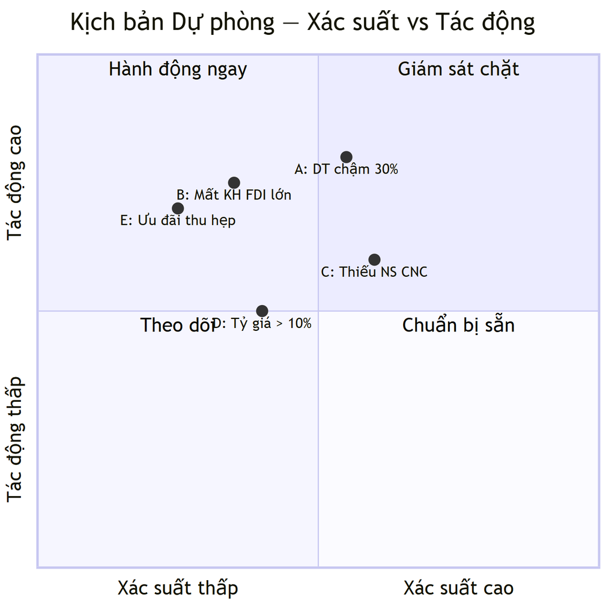

So do 24

### 9.4.4. Điều kiện Tiên quyết để Giữ đúng Cam kết Dự án

| TT | Điều kiện | Trách nhiệm chính | Deadline |
| --- | --- | --- | --- |
| 1 | Vốn CSH 18,00M USD sẵn sàng và chứng minh | CEO / Hội đồng Sáng lập | Trước nộp Mẫu 1.4 |
| 2 | IRC + ERC được cấp cho phạm vi 2 trụ cột + DC nội bộ | Ban Pháp lý | Q3/2026 |
| 3 | ĐTM được phê duyệt cho hoạt động CNC + IoT SX | Tư vấn EIA | Q2/2026 |
| 4 | Hợp đồng thuê đất 50 năm ký với BQL KCNC | CEO + CFO | Q3/2026 |
| 5 | Nhà thầu xây dựng được chọn qua đấu thầu/EPC | PM | Q4/2026 |
| 6 | PO cho CNC Phase 1 (3 máy 5-trục) đặt cọc | CTO + Procurement | Q1/2027 |
| 7 | Core team 8–10 người onboard | HR Director | Q1/2027 |

> 7 điều kiện trên là **prerequisite** — nếu bất kỳ điều kiện nào không đạt đúng hạn, dự án phải re-plan toàn bộ timeline Phase 0–1.

*Mekong Technology kính trình Ban Quản lý KCNC TP.HCM xem xét và chấp thuận.*

### 9.4.2. Kế hoạch 180 ngày Sau khi Được Chấp thuận

| Giai đoạn | Công việc trọng tâm | Đầu ra bắt buộc |
| --- | --- | --- |
| 0-30 ngày | Hoàn thiện hồ sơ pháp lý chi tiết, ký tư vấn ĐTM/PCCC | Kế hoạch pháp lý tích hợp |
| 30-60 ngày | Khóa thiết kế cơ sở, BOQ, cấu trúc PMO | Mức cơ sở ngân sách + tiến độ |
| 60-90 ngày | Chuẩn bị RFQ gói xây dựng, utility, thiết bị dài hạn | Danh mục tender package |
| 90-120 ngày | Mở thầu / đàm phán nhà thầu chính, tuyển core team | Shortlist nhà thầu + nhân sự chủ chốt |
| 120-180 ngày | Khởi động Phase 0-1, thiết lập cơ chế báo cáo với BQL KCNC | Báo cáo khởi động dự án |

> **Cam kết thực thi:** Trong vòng 180 ngày kể từ ngày được chấp thuận, nhà đầu tư sẽ hoàn thành toàn bộ công tác chuẩn bị để dự án chuyển từ trạng thái “đề án được duyệt” sang “chương trình đầu tư đang triển khai”, tránh tình trạng giữ đất nhưng chậm triển khai [A][C].

### 9.4.3. KPI Thành công 24 Tháng Sau Chấp thuận

| KPI | Mục tiêu sau 12 tháng | Mục tiêu sau 24 tháng |
| --- | --- | --- |
| % hoàn tất thủ tục pháp lý lõi | 100% | 100% |
| % giải ngân so với mức cơ sở | ≥ 90% | ≥ 95% |
| % hoàn thành xây dựng / utility | ≥ 40% | ≥ 85% |
| Số hợp đồng / LOI thương mại ký trước vận hành | ≥ 3 | ≥ 6 |
| Tỷ lệ nhân sự core tuyển đủ | ≥ 70% | ≥ 90% |
| Chênh lệch CAPEX so với mức cơ sở | ≤ +5% | ≤ +7,5% |

> Bộ KPI này là thước đo hậu phê duyệt để chứng minh dự án không chỉ “được chấp thuận trên giấy” mà thực sự chuyển hóa thành năng lực sản xuất và thương mại hóa theo đúng cam kết với KCNC [A].

### 9.4.4. Điều kiện Tiên quyết để Giữ đúng Cam kết Dự án

| Điều kiện tiên quyết | Hàm ý quản trị |
| --- | --- |
| Không mở rộng lại sang DC thương mại | Giữ nhất quán phạm vi dự án |
| Không vượt CAPEX 22,00M USD [C] nếu chưa có phê duyệt mới | Bảo vệ hiệu quả đầu tư |
| Ưu tiên đầu tư sâu cho 2 trụ cột hiện hữu | Tránh phân tán nguồn lực |
| Giữ kỷ luật PMO + covenant tài chính | Hạn chế trượt tiến độ và dòng tiền |
| Biến reference customer thành hợp đồng dài hạn | Chuyển từ “đề án tốt” sang “doanh nghiệp tốt” |

## 9.5. Lời kết

Dự án **Mekong Technology — Phương án 22,00M USD** [C] thể hiện cam kết mạnh mẽ của nhà đầu tư trong việc xây dựng một nhà máy sản xuất công nghệ cao thực sự tại KCNC TP.HCM. Với 2 trụ cột rõ ràng (Điện tử Thông minh + CNC), cấu trúc tài chính an toàn (CSH 81,8%, IRR 13,0% > WACC 12,0%), và tuân thủ đầy đủ khung pháp lý, dự án không chỉ mang lại hiệu quả kinh tế mà còn đóng góp thiết thực vào hệ sinh thái sản xuất công nghệ cao quốc gia.

Chúng tôi kính mong nhận được sự xem xét và phê duyệt thuận lợi từ Ban Quản lý KCNC TP.HCM.

> **Trân trọng,** **Hội đồng Sáng lập — Mekong Technology** TP.HCM, Quý 2/2026

# PHỤ LỤC

## Phụ lục A: Chi tiết CAPEX theo Hạng mục và Giai đoạn

*(Xem Bảng 5.1.2 — Đã trình bày đầy đủ tại Phần V)*

### Tổng hợp nhanh

[output not shown]

### Kiểm tra Tỷ trọng

| Nhóm | M USD | % CAPEX |
| --- | --- | --- |
| Pháp lý + Thiết kế + Site | 1,50 | 6,8% |
| Xây dựng (VP + Xưởng + Utility) | 5,00 | 22,7% |
| M&E + PCCC + Hạ tầng | 1,65 | 7,5% |
| Nội thất + Solar | 0,50 | 2,3% |
| Thiết bị IoT/Electronics | 2,50 | 11,4% |
| Thiết bị CNC (10 máy + tooling) | 3,50 | 15,9% |
| Robot Assembly | 0,50 | 2,3% |
| DC Nội bộ | 2,50 | 11,4% |
| QA + Software + Commissioning | 1,00 | 4,5% |
| Vốn lưu động | 2,00 | 9,1% |
| Dự phòng | 1,35 | 6,1% |
| **Tổng** | **22,00** | **100%** |

> Dự phòng = 1,35M USD (6,1%) — đã điều chỉnh để tổng CAPEX = 22,00M USD chính xác [C].

| TT | Hạng mục | M USD | Phase | Nhãn | Ghi chú |
| --- | --- | --- | --- | --- | --- |
| 1 | Pháp lý (IRC, ERC, ĐTM, PCCC) | 0,300 | 0 | [C] | Tư vấn + lệ phí |
| 2 | Thiết kế kiến trúc + M&E | 0,400 | 0 | [C] | 3 công trình |
| 3 | Thuê đất (đặt cọc 2 năm) | 0,200 | 0 | [B] | 120K/năm × ~1,7 năm |
| 4 | San lấp mặt bằng | 0,600 | 0 | [B] | 10.000 m² |
| 5 | Tòa nhà VP 3 tầng | 2,000 | 1 | [C] | 48×21m, GFA 3.024 m² |
| 6 | Nhà xưởng SX (PEB) | 2,800 | 1 | [C] | 48×70m, 3.360 m² |
| 7 | Khu Utility | 0,200 | 1 | [C] | 56×5m, 280 m² |
| 8 | Hệ thống M&E tổng | 0,800 | 1 | [C] | Điện, HVAC, nước, khí nén |
| 9 | PCCC toàn khu | 0,400 | 1 | [C] | Sprinkler, FM-200, bơm |
| 10 | Sân bãi + Đường nội bộ | 0,300 | 1 | [B] | Bãi xe, loading dock |
| 11 | Solar PV 200 kWp | 0,300 | 1 | [C] | Rooftop, mono PERC |
| 12 | EDGE Certification | 0,015 | 1 | [A] | Chứng nhận công trình xanh |
| 13 | Nội thất + Thiết bị VP | 0,335 | 1 | [A] | Bàn ghế, phòng server, showroom |
| 14 | Dây chuyền SMT | 1,500 | 2 | [C] | Pick & Place + Reflow + AOI |
| 15 | Thiết bị R&D BMS/IoT | 0,500 | 2 | [B] | Oscilloscope, logic analyzer, test bench |
| 16 | Thiết bị OEM Test | 0,500 | 2 | [B] | ICT, Functional Test, Burn-in |
| 17 | CNC 5-trục (5 máy) | 2,000 | 2 | [C] | DMG Mori (3) + Mazak (2) |
| 18 | CNC 3-trục (3 máy) | 0,750 | 2 | [C] | Haas (2) + Mazak (1) |
| 19 | EDM + Grinder (2 máy) | 0,450 | 2 | [C] | Sodick + Okamoto |
| 20 | Tooling + Fixture + Workholding | 0,300 | 2 | [A] | Cho 10 máy CNC |
| 21 | Thiết bị QA/QC | 0,300 | 2 | [B] | CMM, roughness tester, hardness |
| 22 | Robot Assembly Line | 0,500 | 2 | [B] | Cell lắp ráp AMR/AGV |
| 23 | DC Nội bộ (xây dựng + thiết bị) | 2,500 | 2 | [C] | Phòng DC + server + network |
| 24 | Software License (ERP, MES, CAM) | 0,300 | 2 | [B] | SAP/Odoo + Mastercam + PLM |
| 25 | Commissioning + Testing | 0,400 | 2 | [A] | Nghiệm thu toàn bộ |
| 26 | Vốn lưu động | 2,000 | 3 | [C] | NVL ban đầu + lương 6 tháng |
| 27 | Dự phòng | 1,350 | 3 | [C] | 6,1% CAPEX |
|  | **TỔNG** | **22,000** |  |  |  |

> **Kiểm tra:** Σ = 0,30 + 0,40 + 0,20 + 0,60 + 2,00 + 2,80 + 0,20 + 0,80 + 0,40 + 0,30 + 0,30 + 0,015 + 0,335 + 1,50 + 0,50 + 0,50 + 2,00 + 0,75 + 0,45 + 0,30 + 0,30 + 0,50 + 2,50 + 0,30 + 0,40 + 2,00 + 1,35 = **22,000M USD** [C].

### A.3. Lịch Giải ngân CAPEX theo Quý (Quarter)

| Quarter | Phase | Hạng mục chính giải ngân | M USD | Tích lũy |
| --- | --- | --- | --- | --- |
| Q1/Y1 | 0 | Pháp lý, thiết kế, đặt cọc đất | 0,60 | 0,60 |
| Q2/Y1 | 0 | Thiết kế M&E, san lấp giai đoạn 1 | 0,50 | 1,10 |
| Q3/Y1 | 0–1 | San lấp hoàn tất, khởi công VP | 0,40 | 1,50 |
| Q4/Y1 | 1 | Xây dựng VP + Xưởng (móng + khung) | 1,50 | 3,00 |
| Q1/Y2 | 1 | Xây dựng VP (kết cấu), Xưởng PEB | 1,80 | 4,80 |
| Q2/Y2 | 1 | Hoàn thiện VP, M&E bắt đầu | 1,50 | 6,30 |
| Q3/Y2 | 1 | M&E + PCCC + Utility, Solar lắp | 1,20 | 7,50 |
| Q4/Y2 | 1 | Nghiệm thu Phase 1, nội thất | 1,15 | 8,65 |
| Q1/Y3 | 2 | Đặt hàng CNC + SMT (đặt cọc 30%) | 2,50 | 11,15 |
| Q2/Y3 | 2 | Nhận máy CNC + SMT (40%), DC xây dựng | 2,80 | 13,95 |
| Q3/Y3 | 2 | Lắp đặt CNC, DC thiết bị, Robot line | 2,00 | 15,95 |
| Q4/Y3 | 2 | Commissioning, Software, QA setup | 1,70 | 17,65 |
| Q1/Y4 | 2–3 | Hoàn tất commissioning, NVL ban đầu | 1,00 | 18,65 |
| Q2-Q4/Y4 | 3 | Vốn lưu động tiếp, dự phòng | 1,50 | 20,15 |
| Y5 | 3 | Dự phòng còn lại | 1,85 | 22,00 |

> **Ghi chú:** Lịch giải ngân dựa trên tiến độ xây dựng thực tế dự kiến. Peak giải ngân tại Q2/Y3 (nhận máy CNC/SMT). Tổng tích lũy = 22,00M USD [C].